# The Racket Guide-8.13

##### 4.9.1Guidelines for Using Assignment🔗

Although using [set!](http://docs.racket-lang.org/reference/set_.html#%28form._%28%28quote._~23~25kernel%29._set%21%29%29) is sometimes appropriate, Racket style generally discourages the use of [set!](http://docs.racket-lang.org/reference/set_.html#%28form._%28%28quote._~23~25kernel%29._set%21%29%29). The following guidelines may help explain when using [set!](http://docs.racket-lang.org/reference/set_.html#%28form._%28%28quote._~23~25kernel%29._set%21%29%29) is appropriate.

- As in any modern language, assigning to a shared identifier is no substitute for passing an argument to a procedure or getting its result.

  Really awful example:

  > | ([define](http://docs.racket-lang.org/reference/define.html#%28form._%28%28lib._racket%2Fprivate%2Fbase..rkt%29._define%29%29) name "unknown") ([define](http://docs.racket-lang.org/reference/define.ht… |
  > | --- |
  > | > ([set!](http://docs.racket-lang.org/reference/set_.html#%28form._%28%28quote._~23~25kernel%29._set%21%29%29) name "John") > (greet) > result "Hello, John" |

  Ok example:

  > | ([define](http://docs.racket-lang.org/reference/define.html#%28form._%28%28lib._racket%2Fprivate%2Fbase..rkt%29._define%29%29) (greet name) ([string-append](http://docs.racket-lang.org/reference/strin… |
  > | --- |
  > | > (greet "John") "Hello, John" > (greet "Anna") "Hello, Anna" |

- A sequence of assignments to a local variable is far inferior to nested bindings.

  Bad example:

  > | > ([let](http://docs.racket-lang.org/reference/let.html#%28form._%28%28lib._racket%2Fprivate%2Fletstx-scheme..rkt%29._let%29%29) ([tree 0]) |
  > | --- |
  > | ([set!](http://docs.racket-lang.org/reference/set_.html#%28form._%28%28quote._~23~25kernel%29._set%21%29%29) tree ([list](http://docs.racket-lang.org/reference/pairs.html#%28def._%28%28quote._~23~25ke… |
  > | ([set!](http://docs.racket-lang.org/reference/set_.html#%28form._%28%28quote._~23~25kernel%29._set%21%29%29) tree ([list](http://docs.racket-lang.org/reference/pairs.html#%28def._%28%28quote._~23~25ke… |
  > | ([set!](http://docs.racket-lang.org/reference/set_.html#%28form._%28%28quote._~23~25kernel%29._set%21%29%29) tree ([list](http://docs.racket-lang.org/reference/pairs.html#%28def._%28%28quote._~23~25ke… |
  > | tree) |

  > '(((0 1 0) 2 (0 1 0)) 3 ((0 1 0) 2 (0 1 0)))

  Ok example:

  > | > ([let*](http://docs.racket-lang.org/reference/let.html#%28form._%28%28lib._racket%2Fprivate%2Fletstx-scheme..rkt%29._let%2A%29%29) ([tree 0] |
  > | --- |
  > | [tree ([list](http://docs.racket-lang.org/reference/pairs.html#%28def._%28%28quote._~23~25kernel%29._list%29%29) tree 1 tree)] |
  > | [tree ([list](http://docs.racket-lang.org/reference/pairs.html#%28def._%28%28quote._~23~25kernel%29._list%29%29) tree 2 tree)] |
  > | [tree ([list](http://docs.racket-lang.org/reference/pairs.html#%28def._%28%28quote._~23~25kernel%29._list%29%29) tree 3 tree)]) |
  > | tree) |

  > '(((0 1 0) 2 (0 1 0)) 3 ((0 1 0) 2 (0 1 0)))
- Using assignment to accumulate results from an iteration is bad style. Accumulating through a loop argument is better.

  Somewhat bad example:

  > | ([define](http://docs.racket-lang.org/reference/define.html#%28form._%28%28lib._racket%2Fprivate%2Fbase..rkt%29._define%29%29) (sum lst) ([let](http://docs.racket-lang.org/reference/let.html#%28form._… |
  > | --- |
  > | > (sum '(1 2 3)) 6 |

  Ok example:

  > | ([define](http://docs.racket-lang.org/reference/define.html#%28form._%28%28lib._racket%2Fprivate%2Fbase..rkt%29._define%29%29) (sum lst) ([let](http://docs.racket-lang.org/reference/let.html#%28form._… |
  > | --- |
  > | > (sum '(1 2 3)) 6 |

  Better (use an existing function) example:

  > | ([define](http://docs.racket-lang.org/reference/define.html#%28form._%28%28lib._racket%2Fprivate%2Fbase..rkt%29._define%29%29) (sum lst) ([apply](http://docs.racket-lang.org/reference/procedures.html#… |
  > | --- |
  > | > (sum '(1 2 3)) 6 |

  Good (a general approach) example:

  > | ([define](http://docs.racket-lang.org/reference/define.html#%28form._%28%28lib._racket%2Fprivate%2Fbase..rkt%29._define%29%29) (sum lst) ([for/fold](http://docs.racket-lang.org/reference/for.html#%28f… |
  > | --- |
  > | > (sum '(1 2 3)) 6 |

- For cases where stateful objects are necessary or appropriate, then implementing the object’s state with [set!](http://docs.racket-lang.org/reference/set_.html#%28form._%28%28quote._~23~25kernel%29._set%21%29%29) is fine.

  Ok example:

  > | ([define](http://docs.racket-lang.org/reference/define.html#%28form._%28%28lib._racket%2Fprivate%2Fbase..rkt%29._define%29%29) next-number! ([let](http://docs.racket-lang.org/reference/let.html#%28for… |
  > | --- |
  > | > (next-number!) 1 > (next-number!) 2 > (next-number!) 3 |

All else being equal, a program that uses no assignments or mutation is always preferable to one that uses assignments or mutation. While side effects are to be avoided, however, they should be used if the resulting code is significantly more readable or if it implements a significantly better algorithm.

The use of mutable values, such as vectors and hash tables, raises fewer suspicions about the style of a program than using [set!](http://docs.racket-lang.org/reference/set_.html#%28form._%28%28quote._~23~25kernel%29._set%21%29%29) directly. Nevertheless, simply replacing [set!](http://docs.racket-lang.org/reference/set_.html#%28form._%28%28quote._~23~25kernel%29._set%21%29%29)s in a program with [vector-set!](http://docs.racket-lang.org/reference/vectors.html#%28def._%28%28quote._~23~25kernel%29._vector-set%21%29%29)s obviously does not improve the style of the program.

##### 4.9.2Multiple Values: [set!-values](http://docs.racket-lang.org/reference/set_.html#%28form._%28%28lib._racket%2Fprivate%2Fmore-scheme..rkt%29._set%21-values%29%29)🔗

> > > [Assignment: set! and set!-values](http://docs.racket-lang.org/reference/set_.html) in [The Racket Reference](http://docs.racket-lang.org/reference/index.html) also documents [set!-values](http://docs.racket-lang.org/reference/set_.html#%28form._%28%28lib._racket%2Fprivate%2Fmore-scheme..rkt%29._set%21-values%29%29).

The [set!-values](http://docs.racket-lang.org/reference/set_.html#%28form._%28%28lib._racket%2Fprivate%2Fmore-scheme..rkt%29._set%21-values%29%29) form assigns to multiple variables at once, given an expression that produces an appropriate number of values:

> > | ([set!-values](http://docs.racket-lang.org/reference/set_.html#%28form._%28%28lib._racket%2Fprivate%2Fmore-scheme..rkt%29._set%21-values%29%29) (id ...) expr) |
> > | --- |

This form is equivalent to using [let-values](http://docs.racket-lang.org/reference/let.html#%28form._%28%28quote._~23~25kernel%29._let-values%29%29) to receive multiple results from expr, and then assigning the results individually to the ids using [set!](http://docs.racket-lang.org/reference/set_.html#%28form._%28%28quote._~23~25kernel%29._set%21%29%29).

Examples:

> | ([define](http://docs.racket-lang.org/reference/define.html#%28form._%28%28lib._racket%2Fprivate%2Fbase..rkt%29._define%29%29) game ([let](http://docs.racket-lang.org/reference/let.html#%28form._%28%2… |
> | --- |
> | > (game #t) |
> | 1 0 |
> | > (game #t) |
> | 1 1 |
> | > (game #f) |
> | 1 2 |

#### 4.10Quoting: [quote](http://docs.racket-lang.org/reference/quote.html#%28form._%28%28quote._~23~25kernel%29._quote%29%29) and ’🔗

> > > [Literals: quote and #%datum](http://docs.racket-lang.org/reference/quote.html) in [The Racket Reference](http://docs.racket-lang.org/reference/index.html) also documents [quote](http://docs.racket-lang.org/reference/quote.html#%28form._%28%28quote._~23~25kernel%29._quote%29%29).

The [quote](http://docs.racket-lang.org/reference/quote.html#%28form._%28%28quote._~23~25kernel%29._quote%29%29) form produces a constant:

> > | (quote datum) |
> > | --- |

The syntax of a datum is technically specified as anything that the [read](http://docs.racket-lang.org/reference/Reading.html#%28def._%28%28quote._~23~25kernel%29._read%29%29) function parses as a single element. The value of the [quote](http://docs.racket-lang.org/reference/quote.html#%28form._%28%28quote._~23~25kernel%29._quote%29%29) form is the same value that [read](http://docs.racket-lang.org/reference/Reading.html#%28def._%28%28quote._~23~25kernel%29._read%29%29) would produce given datum.

The datum can be a symbol, a boolean, a number, a (character or byte) string, a character, a keyword, an empty list, a pair (or list) containing more such values, a vector containing more such values, a hash table containing more such values, or a box containing another such value.

Examples:

> | > (quote apple) |
> | --- |
> | 'apple |
> | > (quote #t) |
> | #t |
> | > (quote 42) |
> | 42 |
> | > (quote "hello") |
> | "hello" |
> | > (quote ()) |
> | '() |
> | > (quote ((1 2 3) #("z" x) . the-end)) |
> | '((1 2 3) #("z" x) . the-end) |
> | > (quote (1 2 . (3))) |
> | '(1 2 3) |

As the last example above shows, the datum does not have to match the normalized printed form of a value. A datum cannot be a printed representation that starts with #<, so it cannot be [#<void>](http://docs.racket-lang.org/guide/void_undefined.html), [#<undefined>](http://docs.racket-lang.org/guide/void_undefined.html), or a procedure.

The [quote](http://docs.racket-lang.org/reference/quote.html#%28form._%28%28quote._~23~25kernel%29._quote%29%29) form is rarely used for a datum that is a boolean, number, or string by itself, since the printed forms of those values can already be used as constants. The [quote](http://docs.racket-lang.org/reference/quote.html#%28form._%28%28quote._~23~25kernel%29._quote%29%29) form is more typically used for symbols and lists, which have other meanings (identifiers, function calls, etc.) when not quoted.

An expression

> > | 'datum |
> > | --- |

is a shorthand for

> (quote datum)

and this shorthand is almost always used instead of [quote](http://docs.racket-lang.org/reference/quote.html#%28form._%28%28quote._~23~25kernel%29._quote%29%29). The shorthand applies even within the datum, so it can produce a list containing [quote](http://docs.racket-lang.org/reference/quote.html#%28form._%28%28quote._~23~25kernel%29._quote%29%29).

> > > [Reading Quotes](http://docs.racket-lang.org/reference/reader.html#%28part._parse-quote%29) in [The Racket Reference](http://docs.racket-lang.org/reference/index.html) provides more on the ' shorthand.

Examples:

> | > 'apple |
> | --- |
> | 'apple |
> | > '"hello" |
> | "hello" |
> | > '(1 2 3) |
> | '(1 2 3) |
> | > ([display](http://docs.racket-lang.org/reference/Writing.html#%28def._%28%28quote._~23~25kernel%29._display%29%29) '(you can 'me)) |
> | (you can (quote me)) |

#### 4.11Quasiquoting: [quasiquote](http://docs.racket-lang.org/reference/quasiquote.html#%28form._%28%28lib._racket%2Fprivate%2Fletstx-scheme..rkt%29._quasiquote%29%29) and ‘🔗

> > > [Quasiquoting: quasiquote, unquote, and unquote-splicing](http://docs.racket-lang.org/reference/quasiquote.html) in [The Racket Reference](http://docs.racket-lang.org/reference/index.html) also documents [quasiquote](http://docs.racket-lang.org/reference/quasiquote.html#%28form._%28%28lib._racket%2Fprivate%2Fletstx-scheme..rkt%29._quasiquote%29%29).

The [quasiquote](http://docs.racket-lang.org/reference/quasiquote.html#%28form._%28%28lib._racket%2Fprivate%2Fletstx-scheme..rkt%29._quasiquote%29%29) form is similar to [quote](http://docs.racket-lang.org/reference/quote.html#%28form._%28%28quote._~23~25kernel%29._quote%29%29):

> > | ([quasiquote](http://docs.racket-lang.org/reference/quasiquote.html#%28form._%28%28lib._racket%2Fprivate%2Fletstx-scheme..rkt%29._quasiquote%29%29) datum) |
> > | --- |

However, for each ([unquote](http://docs.racket-lang.org/reference/quasiquote.html#%28form._%28%28quote._~23~25kernel%29._unquote%29%29) expr) that appears within the datum, the expr is evaluated to produce a value that takes the place of the [unquote](http://docs.racket-lang.org/reference/quasiquote.html#%28form._%28%28quote._~23~25kernel%29._unquote%29%29) sub-form.

Example:

> | > ([quasiquote](http://docs.racket-lang.org/reference/quasiquote.html#%28form._%28%28lib._racket%2Fprivate%2Fletstx-scheme..rkt%29._quasiquote%29%29) (1 2 ([unquote](http://docs.racket-lang.org/refere… |
> | --- |
> | '(1 2 3 4) |

This form can be used to write functions that build lists according to certain patterns.

Examples:

> | > ([define](http://docs.racket-lang.org/reference/define.html#%28form._%28%28lib._racket%2Fprivate%2Fbase..rkt%29._define%29%29) (deep n) ([cond](http://docs.racket-lang.org/reference/if.html#%28form.… |
> | --- |
> | > (deep 8) |
> | '(8 (7 (6 (5 (4 (3 (2 (1 0)))))))) |

Or even to cheaply construct expressions programmatically. (Of course, 9 times out of 10, you should be using a macro to do this (the 10th time being when you’re working through a textbook like [PLAI](https://www.cs.brown.edu/~sk/Publications/Books/ProgLangs/)).)

Examples:

> | > ([define](http://docs.racket-lang.org/reference/define.html#%28form._%28%28lib._racket%2Fprivate%2Fbase..rkt%29._define%29%29) (build-exp n) (add-lets n (make-sum n))) |
> | --- |
> | > ([define](http://docs.racket-lang.org/reference/define.html#%28form._%28%28lib._racket%2Fprivate%2Fbase..rkt%29._define%29%29) (add-lets n body) ([cond](http://docs.racket-lang.org/reference/if.html… |
> | > ([define](http://docs.racket-lang.org/reference/define.html#%28form._%28%28lib._racket%2Fprivate%2Fbase..rkt%29._define%29%29) (make-sum n) ([cond](http://docs.racket-lang.org/reference/if.html#%28f… |
> | > ([define](http://docs.racket-lang.org/reference/define.html#%28form._%28%28lib._racket%2Fprivate%2Fbase..rkt%29._define%29%29) (n->var n) ([string->symbol](http://docs.racket-lang.org/reference/symb… |
> | > (build-exp 3) |
> | '(let ((x3 3)) (let ((x2 2)) (let ((x1 1)) (+ x3 (+ x2 x1))))) |

The [unquote-splicing](http://docs.racket-lang.org/reference/quasiquote.html#%28form._%28%28quote._~23~25kernel%29._unquote-splicing%29%29) form is similar to [unquote](http://docs.racket-lang.org/reference/quasiquote.html#%28form._%28%28quote._~23~25kernel%29._unquote%29%29), but its expr must produce a list, and the [unquote-splicing](http://docs.racket-lang.org/reference/quasiquote.html#%28form._%28%28quote._~23~25kernel%29._unquote-splicing%29%29) form must appear in a context that produces either a list or a vector. As the name suggests, the resulting list is spliced into the context of its use.

Example:

> | > ([quasiquote](http://docs.racket-lang.org/reference/quasiquote.html#%28form._%28%28lib._racket%2Fprivate%2Fletstx-scheme..rkt%29._quasiquote%29%29) (1 2 ([unquote-splicing](http://docs.racket-lang.o… |
> | --- |
> | '(1 2 3 4 5) |

Using splicing we can revise the construction of our example expressions above to have just a single [let](http://docs.racket-lang.org/reference/let.html#%28form._%28%28lib._racket%2Fprivate%2Fletstx-scheme..rkt%29._let%29%29) expression and a single [+](http://docs.racket-lang.org/reference/generic-numbers.html#%28def._%28%28quote._~23~25kernel%29._%2B%29%29) expression.

Examples:

> | > ([define](http://docs.racket-lang.org/reference/define.html#%28form._%28%28lib._racket%2Fprivate%2Fbase..rkt%29._define%29%29) (build-exp n) (add-lets n ([quasiquote](http://docs.racket-lang.org/ref… |
> | --- |
> | > ([define](http://docs.racket-lang.org/reference/define.html#%28form._%28%28lib._racket%2Fprivate%2Fbase..rkt%29._define%29%29) (add-lets n body) ([quasiquote](http://docs.racket-lang.org/reference/q… |
> | > ([define](http://docs.racket-lang.org/reference/define.html#%28form._%28%28lib._racket%2Fprivate%2Fbase..rkt%29._define%29%29) (n->var n) ([string->symbol](http://docs.racket-lang.org/reference/symb… |
> | > (build-exp 3) |
> | '(let ((x1 1) (x2 2) (x3 3)) (+ x1 x2 x3)) |

If a [quasiquote](http://docs.racket-lang.org/reference/quasiquote.html#%28form._%28%28lib._racket%2Fprivate%2Fletstx-scheme..rkt%29._quasiquote%29%29) form appears within an enclosing [quasiquote](http://docs.racket-lang.org/reference/quasiquote.html#%28form._%28%28lib._racket%2Fprivate%2Fletstx-scheme..rkt%29._quasiquote%29%29) form, then the inner [quasiquote](http://docs.racket-lang.org/reference/quasiquote.html#%28form._%28%28lib._racket%2Fprivate%2Fletstx-scheme..rkt%29._quasiquote%29%29) effectively cancels one layer of [unquote](http://docs.racket-lang.org/reference/quasiquote.html#%28form._%28%28quote._~23~25kernel%29._unquote%29%29) and [unquote-splicing](http://docs.racket-lang.org/reference/quasiquote.html#%28form._%28%28quote._~23~25kernel%29._unquote-splicing%29%29) forms, so that a second [unquote](http://docs.racket-lang.org/reference/quasiquote.html#%28form._%28%28quote._~23~25kernel%29._unquote%29%29) or [unquote-splicing](http://docs.racket-lang.org/reference/quasiquote.html#%28form._%28%28quote._~23~25kernel%29._unquote-splicing%29%29) is needed.

Examples:

> | > ([quasiquote](http://docs.racket-lang.org/reference/quasiquote.html#%28form._%28%28lib._racket%2Fprivate%2Fletstx-scheme..rkt%29._quasiquote%29%29) (1 2 ([quasiquote](http://docs.racket-lang.org/ref… |
> | --- |
> | '(1 2 (quasiquote (unquote (+ 1 2)))) |
> | > ([quasiquote](http://docs.racket-lang.org/reference/quasiquote.html#%28form._%28%28lib._racket%2Fprivate%2Fletstx-scheme..rkt%29._quasiquote%29%29) (1 2 ([quasiquote](http://docs.racket-lang.org/ref… |
> | '(1 2 (quasiquote (unquote 3))) |
> | > ([quasiquote](http://docs.racket-lang.org/reference/quasiquote.html#%28form._%28%28lib._racket%2Fprivate%2Fletstx-scheme..rkt%29._quasiquote%29%29) (1 2 ([quasiquote](http://docs.racket-lang.org/ref… |
> | '(1 2 (quasiquote ((unquote (+ 1 2)) (unquote 4)))) |

The evaluations above will not actually print as shown. Instead, the shorthand form of [quasiquote](http://docs.racket-lang.org/reference/quasiquote.html#%28form._%28%28lib._racket%2Fprivate%2Fletstx-scheme..rkt%29._quasiquote%29%29) and [unquote](http://docs.racket-lang.org/reference/quasiquote.html#%28form._%28%28quote._~23~25kernel%29._unquote%29%29) will be used: ` (i.e., a backquote) and , (i.e., a comma). The same shorthands can be used in expressions:

Example:

> | > `(1 2 `(,(+ 1 2) ,,([-](http://docs.racket-lang.org/reference/generic-numbers.html#%28def._%28%28quote._~23~25kernel%29._-%29%29) 5 1))) |
> | --- |
> | '(1 2 `(,(+ 1 2) ,4)) |

The shorthand form of [unquote-splicing](http://docs.racket-lang.org/reference/quasiquote.html#%28form._%28%28quote._~23~25kernel%29._unquote-splicing%29%29) is ,@:

Example:

> | > `(1 2 ,@([list](http://docs.racket-lang.org/reference/pairs.html#%28def._%28%28quote._~23~25kernel%29._list%29%29) ([+](http://docs.racket-lang.org/reference/generic-numbers.html#%28def._%28%28quote… |
> | --- |
> | '(1 2 3 4) |

#### 4.12Simple Dispatch: [case](http://docs.racket-lang.org/reference/case.html#%28form._%28%28lib._racket%2Fprivate%2Fmore-scheme..rkt%29._case%29%29)🔗

The [case](http://docs.racket-lang.org/reference/case.html#%28form._%28%28lib._racket%2Fprivate%2Fmore-scheme..rkt%29._case%29%29) form dispatches to a clause by matching the result of an expression to the values for the clause:

> > | ([case](http://docs.racket-lang.org/reference/case.html#%28form._%28%28lib._racket%2Fprivate%2Fmore-scheme..rkt%29._case%29%29) expr |
> > | --- |
> > | [(datum ...+) body ...+] |
> > | ...) |

Each datum will be compared to the result of expr using [equal?](http://docs.racket-lang.org/reference/Equality.html#%28def._%28%28quote._~23~25kernel%29._equal~3f%29%29), and then the corresponding bodys are evaluated. The [case](http://docs.racket-lang.org/reference/case.html#%28form._%28%28lib._racket%2Fprivate%2Fmore-scheme..rkt%29._case%29%29) form can dispatch to the correct clause in O(log N) time for N datums.

Multiple datums can be supplied for each clause, and the corresponding bodys are evaluated if any of the datums match.

Example:

> | > ([let](http://docs.racket-lang.org/reference/let.html#%28form._%28%28lib._racket%2Fprivate%2Fletstx-scheme..rkt%29._let%29%29) ([v ([random](http://docs.racket-lang.org/reference/generic-numbers.htm… |
> | --- |
> | 4 |
> | 'many |

The last clause of a [case](http://docs.racket-lang.org/reference/case.html#%28form._%28%28lib._racket%2Fprivate%2Fmore-scheme..rkt%29._case%29%29) form can use [else](http://docs.racket-lang.org/reference/if.html#%28form._%28%28lib._racket%2Fprivate%2Fletstx-scheme..rkt%29._else%29%29), just like [cond](http://docs.racket-lang.org/reference/if.html#%28form._%28%28lib._racket%2Fprivate%2Fletstx-scheme..rkt%29._cond%29%29):

Example:

> | > ([case](http://docs.racket-lang.org/reference/case.html#%28form._%28%28lib._racket%2Fprivate%2Fmore-scheme..rkt%29._case%29%29) ([random](http://docs.racket-lang.org/reference/generic-numbers.html#%… |
> | --- |
> | [(0) 'zero] |
> | [(1) 'one] |
> | [(2) 'two] |
> | [[else](http://docs.racket-lang.org/reference/if.html#%28form._%28%28lib._racket%2Fprivate%2Fletstx-scheme..rkt%29._else%29%29) 'many]) |

> 'one

For more general pattern matching (but without the dispatch-time guarantee), use [match](http://docs.racket-lang.org/reference/match.html#%28form._%28%28lib._racket%2Fmatch..rkt%29._match%29%29), which is introduced in Pattern Matching.

#### 4.13Dynamic Binding: [parameterize](http://docs.racket-lang.org/reference/parameters.html#%28form._%28%28lib._racket%2Fprivate%2Fmore-scheme..rkt%29._parameterize%29%29)🔗

> > > [Parameters](http://docs.racket-lang.org/reference/parameters.html) in [The Racket Reference](http://docs.racket-lang.org/reference/index.html) also documents [parameterize](http://docs.racket-lang.org/reference/parameters.html#%28form._%28%28lib._racket%2Fprivate%2Fmore-scheme..rkt%29._parameterize%29%29).

The [parameterize](http://docs.racket-lang.org/reference/parameters.html#%28form._%28%28lib._racket%2Fprivate%2Fmore-scheme..rkt%29._parameterize%29%29) form associates a new value with a parameter during the evaluation of body expressions:

> > | ([parameterize](http://docs.racket-lang.org/reference/parameters.html#%28form._%28%28lib._racket%2Fprivate%2Fmore-scheme..rkt%29._parameterize%29%29) ([parameter-expr value-expr] ...) |
> > | --- |
> > | body ...+) |

> > > The term “parameter” is sometimes used to refer to the arguments of a function, but “parameter” in Racket has the more specific meaning described here.

For example, the [error-print-width](http://docs.racket-lang.org/reference/exns.html#%28def._%28%28quote._~23~25kernel%29._error-print-width%29%29) parameter controls how many characters of a value are printed in an error message:

> | > ([parameterize](http://docs.racket-lang.org/reference/parameters.html#%28form._%28%28lib._racket%2Fprivate%2Fmore-scheme..rkt%29._parameterize%29%29) ([[error-print-width](http://docs.racket-lang.or… |
> | --- |
> | car: contract violation |
> | expected: pair? |
> | given: 10... |
> | > ([parameterize](http://docs.racket-lang.org/reference/parameters.html#%28form._%28%28lib._racket%2Fprivate%2Fmore-scheme..rkt%29._parameterize%29%29) ([[error-print-width](http://docs.racket-lang.or… |
> | car: contract violation |
> | expected: pair? |
> | given: 1000000... |

More generally, parameters implement a kind of dynamic binding. The [make-parameter](http://docs.racket-lang.org/reference/parameters.html#%28def._%28%28quote._~23~25kernel%29._make-parameter%29%29) function takes any value and returns a new parameter that is initialized to the given value. Applying the parameter as a function returns its current value:

> | > ([define](http://docs.racket-lang.org/reference/define.html#%28form._%28%28lib._racket%2Fprivate%2Fbase..rkt%29._define%29%29) location ([make-parameter](http://docs.racket-lang.org/reference/parame… |
> | --- |
> | > (location) |
> | "here" |

In a [parameterize](http://docs.racket-lang.org/reference/parameters.html#%28form._%28%28lib._racket%2Fprivate%2Fmore-scheme..rkt%29._parameterize%29%29) form, each parameter-expr must produce a parameter. During the evaluation of the bodys, each specified parameter is given the result of the corresponding value-expr. When control leaves the [parameterize](http://docs.racket-lang.org/reference/parameters.html#%28form._%28%28lib._racket%2Fprivate%2Fmore-scheme..rkt%29._parameterize%29%29) form—either through a normal return, an exception, or some other escape—the parameter reverts to its earlier value:

> | > ([parameterize](http://docs.racket-lang.org/reference/parameters.html#%28form._%28%28lib._racket%2Fprivate%2Fmore-scheme..rkt%29._parameterize%29%29) ([location "there"]) (location)) |
> | --- |
> | "there" |
> | > (location) |
> | "here" |
> | > ([parameterize](http://docs.racket-lang.org/reference/parameters.html#%28form._%28%28lib._racket%2Fprivate%2Fmore-scheme..rkt%29._parameterize%29%29) ([location "in a house"]) ([list](http://docs.ra… |
> | '("in a house" "with a mouse" "in a house") |
> | > ([parameterize](http://docs.racket-lang.org/reference/parameters.html#%28form._%28%28lib._racket%2Fprivate%2Fmore-scheme..rkt%29._parameterize%29%29) ([location "in a box"]) ([car](http://docs.racke… |
> | car: contract violation |
> | expected: pair? |
> | given: "in a box" |
> | > (location) |
> | "here" |

The [parameterize](http://docs.racket-lang.org/reference/parameters.html#%28form._%28%28lib._racket%2Fprivate%2Fmore-scheme..rkt%29._parameterize%29%29) form is not a binding form like [let](http://docs.racket-lang.org/reference/let.html#%28form._%28%28lib._racket%2Fprivate%2Fletstx-scheme..rkt%29._let%29%29); each use of location above refers directly to the original definition. A [parameterize](http://docs.racket-lang.org/reference/parameters.html#%28form._%28%28lib._racket%2Fprivate%2Fmore-scheme..rkt%29._parameterize%29%29) form adjusts the value of a parameter during the whole time that the [parameterize](http://docs.racket-lang.org/reference/parameters.html#%28form._%28%28lib._racket%2Fprivate%2Fmore-scheme..rkt%29._parameterize%29%29) body is evaluated, even for uses of the parameter that are textually outside of the [parameterize](http://docs.racket-lang.org/reference/parameters.html#%28form._%28%28lib._racket%2Fprivate%2Fmore-scheme..rkt%29._parameterize%29%29) body:

> | > ([define](http://docs.racket-lang.org/reference/define.html#%28form._%28%28lib._racket%2Fprivate%2Fbase..rkt%29._define%29%29) (would-you-could-you?) ([and](http://docs.racket-lang.org/reference/if.… |
> | --- |
> | > (would-you-could-you?) |
> | #f |
> | > ([parameterize](http://docs.racket-lang.org/reference/parameters.html#%28form._%28%28lib._racket%2Fprivate%2Fmore-scheme..rkt%29._parameterize%29%29) ([location "on a bus"]) (would-you-could-you?)) |
> | #t |

If a use of a parameter is textually inside the body of a [parameterize](http://docs.racket-lang.org/reference/parameters.html#%28form._%28%28lib._racket%2Fprivate%2Fmore-scheme..rkt%29._parameterize%29%29) but not evaluated before the [parameterize](http://docs.racket-lang.org/reference/parameters.html#%28form._%28%28lib._racket%2Fprivate%2Fmore-scheme..rkt%29._parameterize%29%29) form produces a value, then the use does not see the value installed by the [parameterize](http://docs.racket-lang.org/reference/parameters.html#%28form._%28%28lib._racket%2Fprivate%2Fmore-scheme..rkt%29._parameterize%29%29) form:

> | > ([let](http://docs.racket-lang.org/reference/let.html#%28form._%28%28lib._racket%2Fprivate%2Fletstx-scheme..rkt%29._let%29%29) ([get ([parameterize](http://docs.racket-lang.org/reference/parameters.… |
> | --- |
> | ([lambda](http://docs.racket-lang.org/reference/lambda.html#%28form._%28%28lib._racket%2Fprivate%2Fbase..rkt%29._lambda%29%29) () (location)))]) |
> | (get)) |

> "here"

The current binding of a parameter can be adjusted imperatively by calling the parameter as a function with a value. If a [parameterize](http://docs.racket-lang.org/reference/parameters.html#%28form._%28%28lib._racket%2Fprivate%2Fmore-scheme..rkt%29._parameterize%29%29) has adjusted the value of the parameter, then directly applying the parameter procedure affects only the value associated with the active [parameterize](http://docs.racket-lang.org/reference/parameters.html#%28form._%28%28lib._racket%2Fprivate%2Fmore-scheme..rkt%29._parameterize%29%29):

> | > ([define](http://docs.racket-lang.org/reference/define.html#%28form._%28%28lib._racket%2Fprivate%2Fbase..rkt%29._define%29%29) (try-again! where) (location where)) |
> | --- |
> | > (location) |
> | "here" |
> | > ([parameterize](http://docs.racket-lang.org/reference/parameters.html#%28form._%28%28lib._racket%2Fprivate%2Fmore-scheme..rkt%29._parameterize%29%29) ([location "on a train"]) ([list](http://docs.ra… |
> | '("on a train" "in a boat") |
> | > (location) |
> | "here" |

Using [parameterize](http://docs.racket-lang.org/reference/parameters.html#%28form._%28%28lib._racket%2Fprivate%2Fmore-scheme..rkt%29._parameterize%29%29) is generally preferable to updating a parameter value imperatively—for much the same reasons that binding a fresh variable with [let](http://docs.racket-lang.org/reference/let.html#%28form._%28%28lib._racket%2Fprivate%2Fletstx-scheme..rkt%29._let%29%29) is preferable to using [set!](http://docs.racket-lang.org/reference/set_.html#%28form._%28%28quote._~23~25kernel%29._set%21%29%29) (see Assignment: set!).

It may seem that variables and [set!](http://docs.racket-lang.org/reference/set_.html#%28form._%28%28quote._~23~25kernel%29._set%21%29%29) can solve many of the same problems that parameters solve. For example, lokation could be defined as a string, and [set!](http://docs.racket-lang.org/reference/set_.html#%28form._%28%28quote._~23~25kernel%29._set%21%29%29) could be used to adjust its value:

> | > ([define](http://docs.racket-lang.org/reference/define.html#%28form._%28%28lib._racket%2Fprivate%2Fbase..rkt%29._define%29%29) lokation "here") |
> | --- |
> | > ([define](http://docs.racket-lang.org/reference/define.html#%28form._%28%28lib._racket%2Fprivate%2Fbase..rkt%29._define%29%29) (would-ya-could-ya?) ([and](http://docs.racket-lang.org/reference/if.ht… |
> | > ([set!](http://docs.racket-lang.org/reference/set_.html#%28form._%28%28quote._~23~25kernel%29._set%21%29%29) lokation "on a bus") |
> | > (would-ya-could-ya?) |
> | #t |

Parameters, however, offer several crucial advantages over [set!](http://docs.racket-lang.org/reference/set_.html#%28form._%28%28quote._~23~25kernel%29._set%21%29%29):

- The [parameterize](http://docs.racket-lang.org/reference/parameters.html#%28form._%28%28lib._racket%2Fprivate%2Fmore-scheme..rkt%29._parameterize%29%29) form helps automatically reset the value of a parameter when control escapes due to an exception. Adding exception handlers and other forms to rewind a [set!](http://docs.racket-lang.org/reference/set_.html#%28form._%28%28quote._~23~25kernel%29._set%21%29%29) is relatively tedious.
- Parameters work nicely with tail calls (see Tail Recursion). The last body in a [parameterize](http://docs.racket-lang.org/reference/parameters.html#%28form._%28%28lib._racket%2Fprivate%2Fmore-scheme..rkt%29._parameterize%29%29) form is in tail position with respect to the [parameterize](http://docs.racket-lang.org/reference/parameters.html#%28form._%28%28lib._racket%2Fprivate%2Fmore-scheme..rkt%29._parameterize%29%29) form.
- Parameters work properly with threads (see [Threads](http://docs.racket-lang.org/reference/threads.html)). The [parameterize](http://docs.racket-lang.org/reference/parameters.html#%28form._%28%28lib._racket%2Fprivate%2Fmore-scheme..rkt%29._parameterize%29%29) form adjusts the value of a parameter only for evaluation in the current thread, which avoids race conditions with other threads.

### 5Programmer-Defined Datatypes🔗

> > > [Structures](http://docs.racket-lang.org/reference/structures.html) in [The Racket Reference](http://docs.racket-lang.org/reference/index.html) also documents structure types.

New datatypes are normally created with the [struct](http://docs.racket-lang.org/reference/define-struct.html#%28form._%28%28lib._racket%2Fprivate%2Fbase..rkt%29._struct%29%29) form, which is the topic of this chapter. The class-based object system, which we defer to Classes and Objects, offers an alternate mechanism for creating new datatypes, but even classes and objects are implemented in terms of structure types.

#### 5.1Simple Structure Types: [struct](http://docs.racket-lang.org/reference/define-struct.html#%28form._%28%28lib._racket%2Fprivate%2Fbase..rkt%29._struct%29%29)🔗

> > > [Defining Structure Types: struct](http://docs.racket-lang.org/reference/define-struct.html) in [The Racket Reference](http://docs.racket-lang.org/reference/index.html) also documents [struct](http://docs.racket-lang.org/reference/define-struct.html#%28form._%28%28lib._racket%2Fprivate%2Fbase..rkt%29._struct%29%29).

To a first approximation, the syntax of [struct](http://docs.racket-lang.org/reference/define-struct.html#%28form._%28%28lib._racket%2Fprivate%2Fbase..rkt%29._struct%29%29) is

> > | ([struct](http://docs.racket-lang.org/reference/define-struct.html#%28form._%28%28lib._racket%2Fprivate%2Fbase..rkt%29._struct%29%29) struct-id (field-id ...)) |
> > | --- |

Examples:

> ([struct](http://docs.racket-lang.org/reference/define-struct.html#%28form._%28%28lib._racket%2Fprivate%2Fbase..rkt%29._struct%29%29) posn (x y))

The [struct](http://docs.racket-lang.org/reference/define-struct.html#%28form._%28%28lib._racket%2Fprivate%2Fbase..rkt%29._struct%29%29) form binds struct-id and a number of identifiers that are built from struct-id and the field-ids:

- struct-id : a constructor function that takes as many arguments as the number of field-ids, and returns an instance of the structure type.

  Example:

  > | > (posn 1 2) |
  > | --- |
  > | #<posn> |

- struct-id? : a predicate function that takes a single argument and returns #t if it is an instance of the structure type, #f otherwise.

  Examples:

  > | > (posn? 3) |
  > | --- |
  > | #f |
  > | > (posn? (posn 1 2)) |
  > | #t |

- struct-id-field-id : for each field-id, an accessor that extracts the value of the corresponding field from an instance of the structure type.

  Examples:

  > | > (posn-x (posn 1 2)) |
  > | --- |
  > | 1 |
  > | > (posn-y (posn 1 2)) |
  > | 2 |

- struct:struct-id : a structure type descriptor, which is a value that represents the structure type as a first-class value (with #:super, as discussed later in More Structure Type Options).

A [struct](http://docs.racket-lang.org/reference/define-struct.html#%28form._%28%28lib._racket%2Fprivate%2Fbase..rkt%29._struct%29%29) form places no constraints on the kinds of values that can appear for fields in an instance of the structure type. For example, (posn "apple" #f) produces an instance of posn, even though "apple" and #f are not valid coordinates for the obvious uses of posn instances. Enforcing constraints on field values, such as requiring them to be numbers, is normally the job of a contract, as discussed later in Contracts.

#### 5.2Copying and Update🔗

The [struct-copy](http://docs.racket-lang.org/reference/struct-copy.html#%28form._%28%28lib._racket%2Fprivate%2Fbase..rkt%29._struct-copy%29%29) form clones a structure and optionally updates specified fields in the clone. This process is sometimes called a functional update, because the result is a structure with updated field values. but the original structure is not modified.

> > | ([struct-copy](http://docs.racket-lang.org/reference/struct-copy.html#%28form._%28%28lib._racket%2Fprivate%2Fbase..rkt%29._struct-copy%29%29) struct-id struct-expr [field-id expr] ...) |
> > | --- |

The struct-id that appears after [struct-copy](http://docs.racket-lang.org/reference/struct-copy.html#%28form._%28%28lib._racket%2Fprivate%2Fbase..rkt%29._struct-copy%29%29) must be a structure type name bound by [struct](http://docs.racket-lang.org/reference/define-struct.html#%28form._%28%28lib._racket%2Fprivate%2Fbase..rkt%29._struct%29%29) (i.e., the name that cannot be used directly as an expression). The struct-expr must produce an instance of the structure type. The result is a new instance of the structure type that is like the old one, except that the field indicated by each field-id gets the value of the corresponding expr.

Examples:

> | > ([define](http://docs.racket-lang.org/reference/define.html#%28form._%28%28lib._racket%2Fprivate%2Fbase..rkt%29._define%29%29) p1 (posn 1 2)) |
> | --- |
> | > ([define](http://docs.racket-lang.org/reference/define.html#%28form._%28%28lib._racket%2Fprivate%2Fbase..rkt%29._define%29%29) p2 ([struct-copy](http://docs.racket-lang.org/reference/struct-copy.htm… |
> | > ([list](http://docs.racket-lang.org/reference/pairs.html#%28def._%28%28quote._~23~25kernel%29._list%29%29) (posn-x p2) (posn-y p2)) |
> | '(3 2) |
> | > ([list](http://docs.racket-lang.org/reference/pairs.html#%28def._%28%28quote._~23~25kernel%29._list%29%29) (posn-x p1) (posn-y p1)) |
> | '(1 2) |

#### 5.3Structure Subtypes🔗

An extended form of [struct](http://docs.racket-lang.org/reference/define-struct.html#%28form._%28%28lib._racket%2Fprivate%2Fbase..rkt%29._struct%29%29) can be used to define a structure subtype, which is a structure type that extends an existing structure type:

> > | ([struct](http://docs.racket-lang.org/reference/define-struct.html#%28form._%28%28lib._racket%2Fprivate%2Fbase..rkt%29._struct%29%29) struct-id super-id (field-id ...)) |
> > | --- |

The super-id must be a structure type name bound by [struct](http://docs.racket-lang.org/reference/define-struct.html#%28form._%28%28lib._racket%2Fprivate%2Fbase..rkt%29._struct%29%29) (i.e., the name that cannot be used directly as an expression).

Examples:

> | ([struct](http://docs.racket-lang.org/reference/define-struct.html#%28form._%28%28lib._racket%2Fprivate%2Fbase..rkt%29._struct%29%29) posn (x y)) |
> | --- |
> | ([struct](http://docs.racket-lang.org/reference/define-struct.html#%28form._%28%28lib._racket%2Fprivate%2Fbase..rkt%29._struct%29%29) 3d-posn posn (z)) |

A structure subtype inherits the fields of its supertype, and the subtype constructor accepts the values for the subtype fields after values for the supertype fields. An instance of a structure subtype can be used with the predicate and accessors of the supertype.

Examples:

> | > ([define](http://docs.racket-lang.org/reference/define.html#%28form._%28%28lib._racket%2Fprivate%2Fbase..rkt%29._define%29%29) p (3d-posn 1 2 3)) |
> | --- |
> | > p |
> | #<3d-posn> |
> | > (posn? p) |
> | #t |
> | > (3d-posn-z p) |
> | 3 |
> | ; a 3d-posn has an x field, but there is no 3d-posn-x selector: |
> | > (3d-posn-x p) |
> | 3d-posn-x: undefined; |
> | cannot reference an identifier before its definition |
> | in module: top-level |
> | ; use the supertype's posn-x selector to access the x field: |
> | > (posn-x p) |
> | 1 |

#### 5.4Opaque versus Transparent Structure Types🔗

With a structure type definition like

> ([struct](http://docs.racket-lang.org/reference/define-struct.html#%28form._%28%28lib._racket%2Fprivate%2Fbase..rkt%29._struct%29%29) posn (x y))

an instance of the structure type prints in a way that does not show any information about the fields’ values. That is, structure types by default are opaque. If the accessors and mutators of a structure type are kept private to a module, then no other module can rely on the representation of the type’s instances.

To make a structure type transparent, use the #:transparent keyword after the field-name sequence:

> | ([struct](http://docs.racket-lang.org/reference/define-struct.html#%28form._%28%28lib._racket%2Fprivate%2Fbase..rkt%29._struct%29%29) posn (x y) #:transparent) |
> | --- |
> | > (posn 1 2) (posn 1 2) |

An instance of a transparent structure type prints like a call to the constructor, so that it shows the structures field values. A transparent structure type also allows reflective operations, such as [struct?](http://docs.racket-lang.org/reference/structutils.html#%28def._%28%28quote._~23~25kernel%29._struct~3f%29%29) and [struct-info](http://docs.racket-lang.org/reference/inspectors.html#%28def._%28%28quote._~23~25kernel%29._struct-info%29%29), to be used on its instances (see Reflection and Dynamic Evaluation).

Structure types are opaque by default, because opaque structure instances provide more encapsulation guarantees. That is, a library can use an opaque structure to encapsulate data, and clients of the library cannot manipulate the data in the structure except as allowed by the library.

#### 5.5Structure Comparisons🔗

A generic [equal?](http://docs.racket-lang.org/reference/Equality.html#%28def._%28%28quote._~23~25kernel%29._equal~3f%29%29) comparison automatically recurs on the fields of a transparent structure type, but [equal?](http://docs.racket-lang.org/reference/Equality.html#%28def._%28%28quote._~23~25kernel%29._equal~3f%29%29) defaults to mere instance identity for opaque structure types:

> | ([struct](http://docs.racket-lang.org/reference/define-struct.html#%28form._%28%28lib._racket%2Fprivate%2Fbase..rkt%29._struct%29%29) glass (width height) #:transparent) |
> | --- |
> | > ([equal?](http://docs.racket-lang.org/reference/Equality.html#%28def._%28%28quote._~23~25kernel%29._equal~3f%29%29) (glass 1 2) (glass 1 2)) #t |

> | ([struct](http://docs.racket-lang.org/reference/define-struct.html#%28form._%28%28lib._racket%2Fprivate%2Fbase..rkt%29._struct%29%29) lead (width height)) |
> | --- |
> | > ([define](http://docs.racket-lang.org/reference/define.html#%28form._%28%28lib._racket%2Fprivate%2Fbase..rkt%29._define%29%29) slab (lead 1 2)) > ([equal?](http://docs.racket-lang.org/reference/Equa… |

To support instances comparisons via [equal?](http://docs.racket-lang.org/reference/Equality.html#%28def._%28%28quote._~23~25kernel%29._equal~3f%29%29) without making the structure type transparent, you can use the #:methods keyword, [gen:equal+hash](http://docs.racket-lang.org/reference/Equality.html#%28def._%28%28lib._racket%2Fprivate%2Fbase..rkt%29._gen~3aequal%2Bhash%29%29), and implement three methods:

> | ([struct](http://docs.racket-lang.org/reference/define-struct.html#%28form._%28%28lib._racket%2Fprivate%2Fbase..rkt%29._struct%29%29) lead (width height) #:methods [gen:equal+hash](http://docs.racket-… |
> | --- |
> | > ([equal?](http://docs.racket-lang.org/reference/Equality.html#%28def._%28%28quote._~23~25kernel%29._equal~3f%29%29) (lead 1 2) (lead 1 2)) #t |

The first function in the list implements the [equal?](http://docs.racket-lang.org/reference/Equality.html#%28def._%28%28quote._~23~25kernel%29._equal~3f%29%29) test on two leads; the third argument to the function is used instead of [equal?](http://docs.racket-lang.org/reference/Equality.html#%28def._%28%28quote._~23~25kernel%29._equal~3f%29%29) for recursive equality testing, so that data cycles can be handled correctly. The other two functions compute primary and secondary hash codes for use with hash tables:

> | > ([define](http://docs.racket-lang.org/reference/define.html#%28form._%28%28lib._racket%2Fprivate%2Fbase..rkt%29._define%29%29) h ([make-hash](http://docs.racket-lang.org/reference/hashtables.html#%2… |
> | --- |
> | > ([hash-set!](http://docs.racket-lang.org/reference/hashtables.html#%28def._%28%28quote._~23~25kernel%29._hash-set%21%29%29) h (lead 1 2) 3) |
> | > ([hash-ref](http://docs.racket-lang.org/reference/hashtables.html#%28def._%28%28quote._~23~25kernel%29._hash-ref%29%29) h (lead 1 2)) |
> | 3 |
> | > ([hash-ref](http://docs.racket-lang.org/reference/hashtables.html#%28def._%28%28quote._~23~25kernel%29._hash-ref%29%29) h (lead 2 1)) |
> | hash-ref: no value found for key |
> | key: #<lead> |

The first function provided with [gen:equal+hash](http://docs.racket-lang.org/reference/Equality.html#%28def._%28%28lib._racket%2Fprivate%2Fbase..rkt%29._gen~3aequal%2Bhash%29%29) is not required to recursively compare the fields of the structure. For example, a structure type representing a set might implement equality by checking that the members of the set are the same, independent of the order of elements in the internal representation. Just take care that the hash functions produce the same value for any two structure types that are supposed to be equivalent.

#### 5.6Structure Type Generativity🔗

Each time that a [struct](http://docs.racket-lang.org/reference/define-struct.html#%28form._%28%28lib._racket%2Fprivate%2Fbase..rkt%29._struct%29%29) form is evaluated, it generates a structure type that is distinct from all existing structure types, even if some other structure type has the same name and fields.

This generativity is useful for enforcing abstractions and implementing programs such as interpreters, but beware of placing a [struct](http://docs.racket-lang.org/reference/define-struct.html#%28form._%28%28lib._racket%2Fprivate%2Fbase..rkt%29._struct%29%29) form in positions that are evaluated multiple times.

Examples:

> | ([define](http://docs.racket-lang.org/reference/define.html#%28form._%28%28lib._racket%2Fprivate%2Fbase..rkt%29._define%29%29) (add-bigger-fish lst) ([struct](http://docs.racket-lang.org/reference/def… |
> | --- |
> | > (add-bigger-fish [null](http://docs.racket-lang.org/reference/pairs.html#%28def._%28%28quote._~23~25kernel%29._null%29%29)) |
> | (list (fish 1)) |
> | > (add-bigger-fish (add-bigger-fish [null](http://docs.racket-lang.org/reference/pairs.html#%28def._%28%28quote._~23~25kernel%29._null%29%29))) |
> | fish-size: contract violation |
> | expected: fish? |
> | given: (fish 1) |

> | ([struct](http://docs.racket-lang.org/reference/define-struct.html#%28form._%28%28lib._racket%2Fprivate%2Fbase..rkt%29._struct%29%29) fish (size) #:transparent) ([define](http://docs.racket-lang.org/r… |
> | --- |
> | > (add-bigger-fish (add-bigger-fish [null](http://docs.racket-lang.org/reference/pairs.html#%28def._%28%28quote._~23~25kernel%29._null%29%29))) (list (fish 2) (fish 1)) |

#### 5.7Prefab Structure Types🔗

Although a transparent structure type prints in a way that shows its content, the printed form of the structure cannot be used in an expression to get the structure back, unlike the printed form of a number, string, symbol, or list.

A prefab (“previously fabricated”) structure type is a built-in type that is known to the Racket printer and expression reader. Infinitely many such types exist, and they are indexed by name, field count, supertype, and other such details. The printed form of a prefab structure is similar to a vector, but it starts #s instead of just #, and the first element in the printed form is the prefab structure type’s name.

The following examples show instances of the sprout prefab structure type that has one field. The first instance has a field value 'bean, and the second has field value 'alfalfa:

> | > '#s(sprout bean) |
> | --- |
> | '#s(sprout bean) |
> | > '#s(sprout alfalfa) |
> | '#s(sprout alfalfa) |

Like numbers and strings, prefab structures are “self-quoting,” so the quotes above are optional:

> | > #s(sprout bean) |
> | --- |
> | '#s(sprout bean) |

When you use the #:prefab keyword with [struct](http://docs.racket-lang.org/reference/define-struct.html#%28form._%28%28lib._racket%2Fprivate%2Fbase..rkt%29._struct%29%29), instead of generating a new structure type, you obtain bindings that work with the existing prefab structure type:

> | > ([define](http://docs.racket-lang.org/reference/define.html#%28form._%28%28lib._racket%2Fprivate%2Fbase..rkt%29._define%29%29) lunch '#s(sprout bean)) |
> | --- |
> | > ([struct](http://docs.racket-lang.org/reference/define-struct.html#%28form._%28%28lib._racket%2Fprivate%2Fbase..rkt%29._struct%29%29) sprout (kind) #:prefab) |
> | > (sprout? lunch) |
> | #t |
> | > (sprout-kind lunch) |
> | 'bean |
> | > (sprout 'garlic) |
> | '#s(sprout garlic) |

The field name kind above does not matter for finding the prefab structure type; only the name sprout and the number of fields matters. At the same time, the prefab structure type sprout with three fields is a different structure type than the one with a single field:

> | > (sprout? #s(sprout bean #f 17)) |
> | --- |
> | #f |
> | > ([struct](http://docs.racket-lang.org/reference/define-struct.html#%28form._%28%28lib._racket%2Fprivate%2Fbase..rkt%29._struct%29%29) sprout (kind yummy? count) #:prefab) ; redefine |
> | > (sprout? #s(sprout bean #f 17)) |
> | #t |
> | > (sprout? lunch) |
> | #f |

A prefab structure type can have another prefab structure type as its supertype, it can have mutable fields, and it can have auto fields. Variations in any of these dimensions correspond to different prefab structure types, and the printed form of the structure type’s name encodes all of the relevant details.

> | > ([struct](http://docs.racket-lang.org/reference/define-struct.html#%28form._%28%28lib._racket%2Fprivate%2Fbase..rkt%29._struct%29%29) building (rooms [location #:mutable]) #:prefab) |
> | --- |
> | > ([struct](http://docs.racket-lang.org/reference/define-struct.html#%28form._%28%28lib._racket%2Fprivate%2Fbase..rkt%29._struct%29%29) house building ([occupied #:auto]) #:prefab #:auto-value 'no) |
> | > (house 5 'factory) |
> | '#s((house (1 no) building 2 #(1)) 5 factory no) |

Every prefab structure type is transparent—but even less abstract than a transparent type, because instances can be created without any access to a particular structure-type declaration or existing examples. Overall, the different options for structure types offer a spectrum of possibilities from more abstract to more convenient:

- Opaque (the default) : Instances cannot be inspected or forged without access to the structure-type declaration. As discussed in the next section, constructor guards and properties can be attached to the structure type to further protect or to specialize the behavior of its instances.
- Transparent : Anyone can inspect or create an instance without access to the structure-type declaration, which means that the value printer can show the content of an instance. All instance creation passes through a constructor guard, however, so that the content of an instance can be controlled, and the behavior of instances can be specialized through properties. Since the structure type is generated by its definition, instances cannot be manufactured simply through the name of the structure type, and therefore cannot be generated automatically by the expression reader.
- Prefab : Anyone can inspect or create an instance at any time, without prior access to a structure-type declaration or an example instance. Consequently, the expression reader can manufacture instances directly. The instance cannot have a constructor guard or properties.

Since the expression reader can generate prefab instances, they are useful when convenient serialization is more important than abstraction. Opaque and transparent structures also can be serialized, however, if they are defined with [serializable-struct](http://docs.racket-lang.org/reference/serialization.html#%28form._%28%28lib._racket%2Fserialize..rkt%29._serializable-struct%29%29) as described in Datatypes and Serialization.

#### 5.8More Structure Type Options🔗

The full syntax of [struct](http://docs.racket-lang.org/reference/define-struct.html#%28form._%28%28lib._racket%2Fprivate%2Fbase..rkt%29._struct%29%29) supports many options, both at the structure-type level and at the level of individual fields:

> > | ([struct](http://docs.racket-lang.org/reference/define-struct.html#%28form._%28%28lib._racket%2Fprivate%2Fbase..rkt%29._struct%29%29) struct-id maybe-super (field ...) struct-option ...) |
> > | --- |
> > | maybe-super = \| super-id field = field-id \| [field-id field-option ...] |

A struct-option always starts with a keyword:

> > > | #:mutable |
> > > | --- |

> > Causes all fields of the structure to be mutable, and introduces for each field-id a mutator set-struct-id-field-id! that sets the value of the corresponding field in an instance of the structure type.

> > Examples:

> > > | > ([struct](http://docs.racket-lang.org/reference/define-struct.html#%28form._%28%28lib._racket%2Fprivate%2Fbase..rkt%29._struct%29%29) dot (x y) #:mutable) |
> > > | --- |
> > > | ([define](http://docs.racket-lang.org/reference/define.html#%28form._%28%28lib._racket%2Fprivate%2Fbase..rkt%29._define%29%29) d (dot 1 2)) |
> > > | > (dot-x d) |
> > > | 1 |
> > > | > (set-dot-x! d 10) |
> > > | > (dot-x d) |
> > > | 10 |

> > The #:mutable option can also be used as a field-option, in which case it makes an individual field mutable.

> > Examples:

> > > | > ([struct](http://docs.racket-lang.org/reference/define-struct.html#%28form._%28%28lib._racket%2Fprivate%2Fbase..rkt%29._struct%29%29) person (name [age #:mutable])) |
> > > | --- |
> > > | ([define](http://docs.racket-lang.org/reference/define.html#%28form._%28%28lib._racket%2Fprivate%2Fbase..rkt%29._define%29%29) friend (person "Barney" 5)) |
> > > | > (set-person-age! friend 6) |
> > > | > (set-person-name! friend "Mary") |
> > > | set-person-name!: undefined; |
> > > | cannot reference an identifier before its definition |
> > > | in module: top-level |

> > > | #:transparent |
> > > | --- |

> > Controls reflective access to structure instances, as discussed in a previous section, Opaque versus Transparent Structure Types.

> > > | #:inspector inspector-expr |
> > > | --- |

> > Generalizes #:transparent to support more controlled access to reflective operations.

> > > | #:prefab |
> > > | --- |

> > Accesses a built-in structure type, as discussed in a previous section, Prefab Structure Types.

> > > | #:auto-value auto-expr |
> > > | --- |

> > Specifies a value to be used for all automatic fields in the structure type, where an automatic field is indicated by the #:auto field option. The constructor procedure does not accept arguments for automatic fields. Automatic fields are implicitly mutable (via reflective operations), but mutator functions are bound only if #:mutable is also specified.

> > Examples:

> > > | > ([struct](http://docs.racket-lang.org/reference/define-struct.html#%28form._%28%28lib._racket%2Fprivate%2Fbase..rkt%29._struct%29%29) posn (x y [z #:auto]) #:transparent #:auto-value 0) |
> > > | --- |
> > > | > (posn 1 2) |
> > > | (posn 1 2 0) |

> > > | #:guard guard-expr |
> > > | --- |

> > Specifies a constructor guard procedure to be called whenever an instance of the structure type is created. The guard takes as many arguments as non-automatic fields in the structure type, plus one more for the name of the instantiated type (in case a sub-type is instantiated, in which case it’s best to report an error using the sub-type’s name). The guard should return the same number of values as given, minus the name argument. The guard can raise an exception if one of the given arguments is unacceptable, or it can convert an argument.

> > Examples:

> > > | > ([struct](http://docs.racket-lang.org/reference/define-struct.html#%28form._%28%28lib._racket%2Fprivate%2Fbase..rkt%29._struct%29%29) thing (name) #:transparent #:guard ([lambda](http://docs.racket-… |
> > > | --- |
> > > | > (thing "apple") |
> > > | (thing "apple") |
> > > | > (thing 'apple) |
> > > | (thing "apple") |
> > > | > (thing 1/2) |
> > > | thing: bad name: 1/2 |

> > The guard is called even when subtype instances are created. In that case, only the fields accepted by the constructor are provided to the guard (but the subtype’s guard gets both the original fields and fields added by the subtype).

> > Examples:

> > > | > ([struct](http://docs.racket-lang.org/reference/define-struct.html#%28form._%28%28lib._racket%2Fprivate%2Fbase..rkt%29._struct%29%29) person thing (age) #:transparent #:guard ([lambda](http://docs.r… |
> > > | --- |
> > > | > (person "John" 10) |
> > > | (person "John" 10) |
> > > | > (person "Mary" -1) |
> > > | person: bad age: -1 |
> > > | > (person 10 10) |
> > > | person: bad name: 10 |

> > > | #:methods interface-expr [body ...] |
> > > | --- |

> > Associates method definitions for the structure type that correspond to a generic interface. For example, implementing the methods for [gen:dict](http://docs.racket-lang.org/reference/dicts.html#%28form._%28%28lib._racket%2Fdict..rkt%29._gen~3adict%29%29) allows instances of a structure type to be used as dictionaries. Implementing the methods for [gen:custom-write](http://docs.racket-lang.org/reference/Printer_Extension.html#%28def._%28%28lib._racket%2Fprivate%2Fbase..rkt%29._gen~3acustom-write%29%29) allows the customization of how an instance of a structure type is [display](http://docs.racket-lang.org/reference/Writing.html#%28def._%28%28quote._~23~25kernel%29._display%29%29)ed.

> > Examples:

> > > | > ([struct](http://docs.racket-lang.org/reference/define-struct.html#%28form._%28%28lib._racket%2Fprivate%2Fbase..rkt%29._struct%29%29) cake (candles) #:methods [gen:custom-write](http://docs.racket-l… |
> > > | --- |
> > > | > ([display](http://docs.racket-lang.org/reference/Writing.html#%28def._%28%28quote._~23~25kernel%29._display%29%29) (cake 5)) |
> > > | ..... .-\|\|\|\|\|-. \| \| ----------- |

> > > | #:property prop-expr val-expr |
> > > | --- |

> > Associates a property and value with the structure type. For example, the [prop:procedure](http://docs.racket-lang.org/reference/procedures.html#%28def._%28%28lib._racket%2Fprivate%2Fbase..rkt%29._prop~3aprocedure%29%29) property allows a structure instance to be used as a function; the property value determines how a call is implemented when using the structure as a function.

> > Examples:

> > > | > ([struct](http://docs.racket-lang.org/reference/define-struct.html#%28form._%28%28lib._racket%2Fprivate%2Fbase..rkt%29._struct%29%29) greeter (name) #:property [prop:procedure](http://docs.racket-la… |
> > > | --- |
> > > | ([define](http://docs.racket-lang.org/reference/define.html#%28form._%28%28lib._racket%2Fprivate%2Fbase..rkt%29._define%29%29) joe-greet (greeter "Joe")) |
> > > | > (greeter-name joe-greet) |
> > > | "Joe" |
> > > | > (joe-greet "Mary") |
> > > | "Hi Mary, I'm Joe" |
> > > | > (joe-greet "John") |
> > > | "Hi John, I'm Joe" |

> > > | #:super super-expr |
> > > | --- |

> > An alternative to supplying a super-id next to struct-id. Instead of the name of a structure type (which is not an expression), super-expr should produce a structure type descriptor value. An advantage of #:super is that structure type descriptors are values, so they can be passed to procedures.

> > Examples:

> > > | ([define](http://docs.racket-lang.org/reference/define.html#%28form._%28%28lib._racket%2Fprivate%2Fbase..rkt%29._define%29%29) (raven-constructor super-type) ([struct](http://docs.racket-lang.org/refe… |
> > > | --- |
> > > | > ([let](http://docs.racket-lang.org/reference/let.html#%28form._%28%28lib._racket%2Fprivate%2Fletstx-scheme..rkt%29._let%29%29) ([r ((raven-constructor struct:posn) 1 2)]) ([list](http://docs.racket-… |
> > > | (list (raven 1 2) 'nevermore) |
> > > | > ([let](http://docs.racket-lang.org/reference/let.html#%28form._%28%28lib._racket%2Fprivate%2Fletstx-scheme..rkt%29._let%29%29) ([r ((raven-constructor struct:thing) "apple")]) ([list](http://docs.ra… |
> > > | (list (raven "apple") 'nevermore) |

> > > [Structures](http://docs.racket-lang.org/reference/structures.html) in [The Racket Reference](http://docs.racket-lang.org/reference/index.html) provides more on structure types.

### 6Modules🔗

Modules let you organize Racket code into multiple files and reusable libraries.

| 6.1 Module Basics |
| --- |
| 6.1.1 Organizing Modules |
| 6.1.2 Library Collections |
| 6.1.3 Packages and Collections |
| 6.1.4 Adding Collections |
| 6.1.5 Module References Within a Collection |
| 6.2 Module Syntax |
| 6.2.1 The module Form |
| 6.2.2 The #lang Shorthand |
| 6.2.3 Submodules |
| 6.2.4 Main and Test Submodules |
| 6.3 Module Paths |
| 6.4 Imports: require |
| 6.5 Exports: provide |
| 6.6 Assignment and Redefinition |
| 6.7 Modules and Macros |
| 6.8 Protected Exports |

#### 6.1Module Basics🔗

Each Racket module typically resides in its own file. For example, suppose the file "cake.rkt" contains the following module:

> > "cake.rkt"

> > > | [#lang](http://docs.racket-lang.org/guide/Module_Syntax.html#%28part._hash-lang%29) [racket](http://docs.racket-lang.org/reference/index.html) |
> > > | --- |
> > > | ([provide](http://docs.racket-lang.org/reference/require.html#%28form._%28%28lib._racket%2Fprivate%2Fbase..rkt%29._provide%29%29) print-cake) |
> > > | ; draws a cake with n candles |
> > > | ([define](http://docs.racket-lang.org/reference/define.html#%28form._%28%28lib._racket%2Fprivate%2Fbase..rkt%29._define%29%29) (print-cake n) |
> > > | (show " ~a " n #\.) |
> > > | (show " .-~a-. " n #\\|) |
> > > | (show " \| ~a \| " n #\space) |
> > > | (show "---~a---" n #\-)) |
> > > | ([define](http://docs.racket-lang.org/reference/define.html#%28form._%28%28lib._racket%2Fprivate%2Fbase..rkt%29._define%29%29) (show fmt n ch) |
> > > | ([printf](http://docs.racket-lang.org/reference/Writing.html#%28def._%28%28quote._~23~25kernel%29._printf%29%29) fmt ([make-string](http://docs.racket-lang.org/reference/strings.html#%28def._%28%28quo… |
> > > | ([newline](http://docs.racket-lang.org/reference/Byte_and_String_Output.html#%28def._%28%28quote._~23~25kernel%29._newline%29%29))) |

Then, other modules can import "cake.rkt" to use the print-cake function, since the [provide](http://docs.racket-lang.org/reference/require.html#%28form._%28%28lib._racket%2Fprivate%2Fbase..rkt%29._provide%29%29) line in "cake.rkt" explicitly exports the definition print-cake. The show function is private to "cake.rkt" (i.e., it cannot be used from other modules), since show is not exported.

The following "random-cake.rkt" module imports "cake.rkt":

> > "random-cake.rkt"

> > > | [#lang](http://docs.racket-lang.org/guide/Module_Syntax.html#%28part._hash-lang%29) [racket](http://docs.racket-lang.org/reference/index.html) |
> > > | --- |
> > > | ([require](http://docs.racket-lang.org/reference/require.html#%28form._%28%28lib._racket%2Fprivate%2Fbase..rkt%29._require%29%29) "cake.rkt") |
> > > | (print-cake ([random](http://docs.racket-lang.org/reference/generic-numbers.html#%28def._%28%28lib._racket%2Fprivate%2Fbase..rkt%29._random%29%29) 30)) |

The relative reference "cake.rkt" in the import ([require](http://docs.racket-lang.org/reference/require.html#%28form._%28%28lib._racket%2Fprivate%2Fbase..rkt%29._require%29%29) "cake.rkt") works if the "cake.rkt" and "random-cake.rkt" modules are in the same directory. Unix-style relative paths are used for relative module references on all platforms, much like relative URLs in HTML pages.

##### 6.1.1Organizing Modules🔗

The "cake.rkt" and "random-cake.rkt" example demonstrates the most common way to organize a program into modules: put all module files in a single directory (perhaps with subdirectories), and then have the modules reference each other through relative paths. A directory of modules can act as a project, since it can be moved around on the filesystem or copied to other machines, and relative paths preserve the connections among modules.

As another example, if you are building a candy-sorting program, you might have a main "sort.rkt" module that uses other modules to access a candy database and a control sorting machine. If the candy-database module itself is organized into sub-modules that handle barcode and manufacturer information, then the database module could be "db/lookup.rkt" that uses helper modules "db/barcodes.rkt" and "db/makers.rkt". Similarly, the sorting-machine driver "machine/control.rkt" might use helper modules "machine/sensors.rkt" and "machine/actuators.rkt".

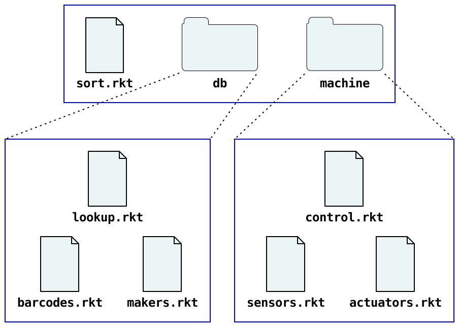

The "sort.rkt" module uses the relative paths "db/lookup.rkt" and "machine/control.rkt" to import from the database and machine-control libraries:

> > "sort.rkt"

> > > | [#lang](http://docs.racket-lang.org/guide/Module_Syntax.html#%28part._hash-lang%29) [racket](http://docs.racket-lang.org/reference/index.html) |
> > > | --- |
> > > | ([require](http://docs.racket-lang.org/reference/require.html#%28form._%28%28lib._racket%2Fprivate%2Fbase..rkt%29._require%29%29) "db/lookup.rkt" "machine/control.rkt") |
> > > | .... |

The "db/lookup.rkt" module similarly uses paths relative to its own source to access the "db/barcodes.rkt" and "db/makers.rkt" modules:

Ditto for "machine/control.rkt":

> > "machine/control.rkt"

> > > | [#lang](http://docs.racket-lang.org/guide/Module_Syntax.html#%28part._hash-lang%29) [racket](http://docs.racket-lang.org/reference/index.html) |
> > > | --- |
> > > | ([require](http://docs.racket-lang.org/reference/require.html#%28form._%28%28lib._racket%2Fprivate%2Fbase..rkt%29._require%29%29) "sensors.rkt" "actuators.rkt") |
> > > | .... |

Racket tools all work automatically with relative paths. For example,

racket sort.rkt

on the command line runs the "sort.rkt" program and automatically loads and compiles required modules. With a large enough program, compilation from source can take too long, so use

raco make sort.rkt

> > > See [raco make: Compiling Source to Bytecode](http://docs.racket-lang.org/raco/make.html) for more information on raco make.

to compile "sort.rkt" and all its dependencies to bytecode files. Running racket sort.rkt will automatically use bytecode files when they are present.

##### 6.1.2Library Collections🔗

A collection is a hierarchical grouping of installed library modules. A module in a collection is referenced through an unquoted, suffixless path. For example, the following module refers to the "date.rkt" library that is part of the "racket" collection:

> | [#lang](http://docs.racket-lang.org/guide/Module_Syntax.html#%28part._hash-lang%29) [racket](http://docs.racket-lang.org/reference/index.html) |
> | --- |
> | ([require](http://docs.racket-lang.org/reference/require.html#%28form._%28%28lib._racket%2Fprivate%2Fbase..rkt%29._require%29%29) racket/date) |
> | ([printf](http://docs.racket-lang.org/reference/Writing.html#%28def._%28%28quote._~23~25kernel%29._printf%29%29) "Today is ~s\n" |
> | ([date->string](http://docs.racket-lang.org/reference/time.html#%28def._%28%28lib._racket%2Fdate..rkt%29._date-~3estring%29%29) ([seconds->date](http://docs.racket-lang.org/reference/time.html#%28def.… |

When you search the online Racket documentation, the search results indicate the module that provides each binding. Alternatively, if you reach a binding’s documentation by clicking on hyperlinks, you can hover over the binding name to find out which modules provide it.

A module reference like [racket/date](http://docs.racket-lang.org/reference/time.html#%28mod-path._racket%2Fdate%29) looks like an identifier, but it is not treated in the same way as [printf](http://docs.racket-lang.org/reference/Writing.html#%28def._%28%28quote._~23~25kernel%29._printf%29%29) or [date->string](http://docs.racket-lang.org/reference/time.html#%28def._%28%28lib._racket%2Fdate..rkt%29._date-~3estring%29%29). Instead, when [require](http://docs.racket-lang.org/reference/require.html#%28form._%28%28lib._racket%2Fprivate%2Fbase..rkt%29._require%29%29) sees a module reference that is unquoted, it converts the reference to a collection-based module path:

- First, if the unquoted path contains no /, then [require](http://docs.racket-lang.org/reference/require.html#%28form._%28%28lib._racket%2Fprivate%2Fbase..rkt%29._require%29%29) automatically adds a "/main" to the reference. For example, ([require](http://docs.racket-lang.org/reference/require.html#%28form._%28%28lib._racket%2Fprivate%2Fbase..rkt%29._require%29%29) [slideshow](http://docs.racket-lang.org/slideshow/index.html)) is equivalent to ([require](http://docs.racket-lang.org/reference/require.html#%28form._%28%28lib._racket%2Fprivate%2Fbase..rkt%29._require%29%29) slideshow/main).
- Second, [require](http://docs.racket-lang.org/reference/require.html#%28form._%28%28lib._racket%2Fprivate%2Fbase..rkt%29._require%29%29) implicitly adds a ".rkt" suffix to the path.
- Finally, [require](http://docs.racket-lang.org/reference/require.html#%28form._%28%28lib._racket%2Fprivate%2Fbase..rkt%29._require%29%29) resolves the path by searching among installed collections, instead of treating the path as relative to the enclosing module’s path.

To a first approximation, a collection is implemented as a filesystem directory. For example, the "racket" collection is mostly located in a "racket" directory within the Racket installation’s "collects" directory, as reported by

> | [#lang](http://docs.racket-lang.org/guide/Module_Syntax.html#%28part._hash-lang%29) [racket](http://docs.racket-lang.org/reference/index.html) |
> | --- |
> | ([require](http://docs.racket-lang.org/reference/require.html#%28form._%28%28lib._racket%2Fprivate%2Fbase..rkt%29._require%29%29) setup/dirs) |
> | ([build-path](http://docs.racket-lang.org/reference/Manipulating_Paths.html#%28def._%28%28quote._~23~25kernel%29._build-path%29%29) ([find-collects-dir](http://docs.racket-lang.org/raco/dirs.html#%28d… |
> | "racket") |

The Racket installation’s "collects" directory, however, is only one place that [require](http://docs.racket-lang.org/reference/require.html#%28form._%28%28lib._racket%2Fprivate%2Fbase..rkt%29._require%29%29) looks for collection directories. Other places include the user-specific directory reported by ([find-user-collects-dir](http://docs.racket-lang.org/raco/dirs.html#%28def._%28%28lib._setup%2Fdirs..rkt%29._find-user-collects-dir%29%29)) and directories configured through the PLTCOLLECTS search path. Finally, and most typically, collections are found through installed packages.

##### 6.1.3Packages and Collections🔗

A package is a set of libraries that are installed through the Racket package manager (or included as pre-installed in a Racket distribution). For example, the [racket/gui](http://docs.racket-lang.org/gui/index.html) library is provided by the "gui" package, while [parser-tools/lex](http://docs.racket-lang.org/parser-tools/Lexers.html) is provided by the "parser-tools" library.

> > > More precisely, [racket/gui](http://docs.racket-lang.org/gui/index.html) is provided by "gui-lib", [parser-tools/lex](http://docs.racket-lang.org/parser-tools/Lexers.html) is provided by "parser-tools-lib", and the "gui" and "parser-tools" packages extend "gui-lib" and "parser-tools-lib" with documentation.

Racket programs do not refer to packages directly. Instead, programs refer to libraries via collections, and adding or removing a package changes the set of collection-based libraries that are available. A single package can supply libraries in multiple collections, and two different packages can supply libraries in the same collection (but not the same libraries, and the package manager ensures that installed packages do not conflict at that level).

For more information about packages, see [Package Management in Racket](http://docs.racket-lang.org/pkg/index.html).

##### 6.1.4Adding Collections🔗

Looking back at the candy-sorting example of Organizing Modules, suppose that modules in "db/" and "machine/" need a common set of helper functions. Helper functions could be put in a "utils/" directory, and modules in "db/" or "machine/" could access utility modules with relative paths that start "../utils/". As long as a set of modules work together in a single project, it’s best to stick with relative paths. A programmer can follow relative-path references without knowing about your Racket configuration.

Some libraries are meant to be used across multiple projects, so that keeping the library source in a directory with its uses does not make sense. In that case, the best option is add a new collection. After the library is in a collection, it can be referenced with an unquoted path, just like libraries that are included with the Racket distribution.

You could add a new collection by placing files in the Racket installation or one of the directories reported by ([get-collects-search-dirs](http://docs.racket-lang.org/raco/dirs.html#%28def._%28%28lib._setup%2Fdirs..rkt%29._get-collects-search-dirs%29%29)). Alternatively, you could add to the list of searched directories by setting the PLTCOLLECTS environment variable.If you set PLTCOLLECTS, include an empty path in by starting the value with a colon (Unix and Mac OS) or semicolon (Windows) so that the original search paths are preserved. The best option, however, is to add a package.

Creating a package does not mean that you have to register with a package server or perform a bundling step that copies your source code into an archive format. Creating a package can simply mean using the package manager to make your libraries locally accessible as a collection from their current source locations.

For example, suppose you have a directory "/usr/molly/bakery" that contains the "cake.rkt" module (from the beginning of this section) and other related modules. To make the modules available as a "bakery" collection, either

- Use the raco pkg command-line tool:

  raco pkg install --link /usr/molly/bakery

  where the --link flag is not actually needed when the provided path includes a directory separator.
- Use DrRacket’s Package Manager item from the File menu. In the Do What I Mean panel, click Browse..., choose the "/usr/molly/bakery" directory, and click Install.

Afterward, ([require](http://docs.racket-lang.org/reference/require.html#%28form._%28%28lib._racket%2Fprivate%2Fbase..rkt%29._require%29%29) bakery/cake) from any module will import the print-cake function from "/usr/molly/bakery/cake.rkt".

By default, the name of the directory that you install is used both as the package name and as the collection that is provided by the package. Also, the package manager normally defaults to installation only for the current user, as opposed to all users of a Racket installation. See [Package Management in Racket](http://docs.racket-lang.org/pkg/index.html) for more information.

If you intend to distribute your libraries to others, choose collection and package names carefully. The collection namespace is hierarchical, but top-level collection names are global, and the package namespace is flat. Consider putting one-off libraries under some top-level name like "molly" that identifies the producer. Use a collection name like "bakery" when producing the definitive collection of baked-goods libraries.

After your libraries are put in a collection you can still use raco make to compile the library sources, but it’s better and more convenient to use raco setup. The raco setup command takes a collection name (as opposed to a file name) and compiles all libraries within the collection. In addition, raco setup can build documentation for the collection and add it to the documentation index, as specified by a "info.rkt" module in the collection. See [raco setup: Installation Management](http://docs.racket-lang.org/raco/setup.html) for more information on raco setup.

##### 6.1.5Module References Within a Collection🔗

When a module within a collection references another module within the same collection, either a relative path or a collection path could work. For example, a "sort.rkt" module that references "db/lookup.rkt" and "machine/control.rkt" modules within the same collection could be written with relative paths as in Organizing Modules:

> > "sort.rkt"

> > > | [#lang](http://docs.racket-lang.org/guide/Module_Syntax.html#%28part._hash-lang%29) [racket](http://docs.racket-lang.org/reference/index.html) |
> > > | --- |
> > > | ([require](http://docs.racket-lang.org/reference/require.html#%28form._%28%28lib._racket%2Fprivate%2Fbase..rkt%29._require%29%29) "db/lookup.rkt" "machine/control.rkt") |
> > > | .... |

Alternatively, if the collection is named "candy", then "sort.rkt" could use collection paths to import the two modules:

> > "sort.rkt"

> > > | [#lang](http://docs.racket-lang.org/guide/Module_Syntax.html#%28part._hash-lang%29) [racket](http://docs.racket-lang.org/reference/index.html) |
> > > | --- |
> > > | ([require](http://docs.racket-lang.org/reference/require.html#%28form._%28%28lib._racket%2Fprivate%2Fbase..rkt%29._require%29%29) candy/db/lookup candy/machine/control) |
> > > | .... |

For most purposes, these choices will work the same, but there are exceptions. When writing documentation with [Scribble](http://docs.racket-lang.org/scribble/index.html), you must use a collection path with [defmodule](http://docs.racket-lang.org/scribble/doc-modules.html#%28form._%28%28lib._scribble%2Fmanual..rkt%29._defmodule%29%29) and similar forms; that’s partly because documentation is meant to be read by client programmers, and so the collection-based name should appear. Meanwhile, for [require](http://docs.racket-lang.org/reference/require.html#%28form._%28%28lib._racket%2Fprivate%2Fbase..rkt%29._require%29%29), using relative paths for references within a collection tends to be the most flexible approach, but with caveats.

Relative-path references work much like relative URL references: the reference is expanded based on the way the enclosing module is accessed. If the enclosing module is accessed through a filesystem path, then a relative path in [require](http://docs.racket-lang.org/reference/require.html#%28form._%28%28lib._racket%2Fprivate%2Fbase..rkt%29._require%29%29) is combined with that filesystem path to form a new filesystem path. If the enclosing module is accessed through a collection path, then a relative path in [require](http://docs.racket-lang.org/reference/require.html#%28form._%28%28lib._racket%2Fprivate%2Fbase..rkt%29._require%29%29) is combined with that collection path to form a new collection path. A collection path is, in turn, converted to a filesystem path, and so the difference between starting with a filesystem or collection path does not usually matter. Unfortunately, inherent complexities of path resolution can create differences in some situations:

- Through soft links, multiple mount points, or case-insensitive filesystems (on an operating system that does not implicitly case-normalize paths), there may be multiple filesystem paths that refer to the same module file.

  For example, when the current directory is the "candy" collection’s directory, the current-directory path that racket receives on startup may cause racket sort.rkt to use a different filesystem path than racket -l candy/sort finds through the library-collection search path. In that case, if "sort.rkt" leads to some modules through both relative-path references and collection-based references, it’s possible that those resolve to difference instances of the same source module, creating confusion through multiple instantiations.
- When [raco exe](http://docs.racket-lang.org/raco/exe.html) plus [raco distribute](http://docs.racket-lang.org/raco/exe-dist.html) are used to create an executable to run on a different machine, the paths of the current machine are likely unrelated to paths on the target machine. The raco exe tool treats modules that are referenced via filesystem paths differently than modules reference via collection paths, because only the latter make sense to access through reflective operations at run time.

  For example, if raco exe sort.rkt creates an executable that uses ([dynamic-require](http://docs.racket-lang.org/reference/Module_Names_and_Loading.html#%28def._%28%28quote._~23~25kernel%29._dynamic-require%29%29) 'candy/db/lookup #f) at run time, then that [dynamic-require](http://docs.racket-lang.org/reference/Module_Names_and_Loading.html#%28def._%28%28quote._~23~25kernel%29._dynamic-require%29%29) will fail in the case that "db/lookup.rkt" is resolved relative to the filesystem path "sort.rkt" at executable-creation time.

Using only collection-based paths (including using shell commands like racket -l candy/sort and not like racket sort.rkt) can avoid all problems, but then you must only develop modules within an installed collection, which is often inconvenient. Using relative-path references consistently tends to be the most convenient while still working in most circumstances.

#### 6.2Module Syntax🔗

The #lang at the start of a module file begins a shorthand for a [module](http://docs.racket-lang.org/reference/module.html#%28form._%28%28quote._~23~25kernel%29._module%29%29) form, much like ' is a shorthand for a [quote](http://docs.racket-lang.org/reference/quote.html#%28form._%28%28quote._~23~25kernel%29._quote%29%29) form. Unlike ', the #lang shorthand does not work well in a REPL, in part because it must be terminated by an end-of-file, but also because the longhand expansion of #lang depends on the name of the enclosing file.

##### 6.2.1The [module](http://docs.racket-lang.org/reference/module.html#%28form._%28%28quote._~23~25kernel%29._module%29%29) Form🔗

The longhand form of a module declaration, which works in a REPL as well as a file, is

> > | ([module](http://docs.racket-lang.org/reference/module.html#%28form._%28%28quote._~23~25kernel%29._module%29%29) name-id initial-module-path |
> > | --- |
> > | decl ...) |

where the name-id is a name for the module, initial-module-path is an initial import, and each decl is an import, export, definition, or expression. In the case of a file, name-id normally matches the name of the containing file, minus its directory path or file extension, but name-id is ignored when the module is [require](http://docs.racket-lang.org/reference/require.html#%28form._%28%28lib._racket%2Fprivate%2Fbase..rkt%29._require%29%29)d through its file’s path.

The initial-module-path is needed because even the [require](http://docs.racket-lang.org/reference/require.html#%28form._%28%28lib._racket%2Fprivate%2Fbase..rkt%29._require%29%29) form must be imported for further use in the module body. In other words, the initial-module-path import bootstraps the syntax that is available in the body. The most commonly used initial-module-path is [racket](http://docs.racket-lang.org/reference/index.html), which supplies most of the bindings described in this guide, including [require](http://docs.racket-lang.org/reference/require.html#%28form._%28%28lib._racket%2Fprivate%2Fbase..rkt%29._require%29%29), [define](http://docs.racket-lang.org/reference/define.html#%28form._%28%28lib._racket%2Fprivate%2Fbase..rkt%29._define%29%29), and [provide](http://docs.racket-lang.org/reference/require.html#%28form._%28%28lib._racket%2Fprivate%2Fbase..rkt%29._provide%29%29). Another commonly used initial-module-path is [racket/base](http://docs.racket-lang.org/reference/index.html), which provides less functionality, but still much of the most commonly needed functions and syntax.

For example, the "cake.rkt" example of the previous section could be written as

> | ([module](http://docs.racket-lang.org/reference/module.html#%28form._%28%28quote._~23~25kernel%29._module%29%29) cake racket |
> | --- |
> | ([provide](http://docs.racket-lang.org/reference/require.html#%28form._%28%28lib._racket%2Fprivate%2Fbase..rkt%29._provide%29%29) print-cake) |
> | ([define](http://docs.racket-lang.org/reference/define.html#%28form._%28%28lib._racket%2Fprivate%2Fbase..rkt%29._define%29%29) (print-cake n) |
> | (show " ~a " n #\.) |
> | (show " .-~a-. " n #\\|) |
> | (show " \| ~a \| " n #\space) |
> | (show "---~a---" n #\-)) |
> | ([define](http://docs.racket-lang.org/reference/define.html#%28form._%28%28lib._racket%2Fprivate%2Fbase..rkt%29._define%29%29) (show fmt n ch) |
> | ([printf](http://docs.racket-lang.org/reference/Writing.html#%28def._%28%28quote._~23~25kernel%29._printf%29%29) fmt ([make-string](http://docs.racket-lang.org/reference/strings.html#%28def._%28%28quo… |
> | ([newline](http://docs.racket-lang.org/reference/Byte_and_String_Output.html#%28def._%28%28quote._~23~25kernel%29._newline%29%29)))) |

Furthermore, this [module](http://docs.racket-lang.org/reference/module.html#%28form._%28%28quote._~23~25kernel%29._module%29%29) form can be evaluated in a REPL to declare a cake module that is not associated with any file. To refer to such an unassociated module, quote the module name:

Examples:

> | > ([require](http://docs.racket-lang.org/reference/require.html#%28form._%28%28lib._racket%2Fprivate%2Fbase..rkt%29._require%29%29) 'cake) |
> | --- |
> | > (print-cake 3) |
> | ... .-\|\|\|-. \| \| --------- |

Declaring a module does not immediately evaluate the body definitions and expressions of the module. The module must be explicitly [require](http://docs.racket-lang.org/reference/require.html#%28form._%28%28lib._racket%2Fprivate%2Fbase..rkt%29._require%29%29)d at the top level to trigger evaluation. After evaluation is triggered once, later [require](http://docs.racket-lang.org/reference/require.html#%28form._%28%28lib._racket%2Fprivate%2Fbase..rkt%29._require%29%29)s do not re-evaluate the module body.

Examples:

> | > ([module](http://docs.racket-lang.org/reference/module.html#%28form._%28%28quote._~23~25kernel%29._module%29%29) hi racket ([printf](http://docs.racket-lang.org/reference/Writing.html#%28def._%28%28… |
> | --- |
> | > ([require](http://docs.racket-lang.org/reference/require.html#%28form._%28%28lib._racket%2Fprivate%2Fbase..rkt%29._require%29%29) 'hi) |
> | Hello |
> | > ([require](http://docs.racket-lang.org/reference/require.html#%28form._%28%28lib._racket%2Fprivate%2Fbase..rkt%29._require%29%29) 'hi) |

##### 6.2.2The #lang Shorthand🔗

The body of a #lang shorthand has no specific syntax, because the syntax is determined by the language name that follows #lang.

In the case of #lang [racket](http://docs.racket-lang.org/reference/index.html), the syntax is

> | [#lang](http://docs.racket-lang.org/guide/Module_Syntax.html#%28part._hash-lang%29) [racket](http://docs.racket-lang.org/reference/index.html) |
> | --- |
> | decl [...](http://docs.racket-lang.org/reference/stx-patterns.html#%28form._%28%28lib._racket%2Fprivate%2Fstxcase-scheme..rkt%29._......%29%29) |

which reads the same as

> | ([module](http://docs.racket-lang.org/reference/module.html#%28form._%28%28quote._~23~25kernel%29._module%29%29) name racket |
> | --- |
> | decl [...](http://docs.racket-lang.org/reference/stx-patterns.html#%28form._%28%28lib._racket%2Fprivate%2Fstxcase-scheme..rkt%29._......%29%29)) |

where name is derived from the name of the file that contains the #lang form.

The #lang [racket/base](http://docs.racket-lang.org/reference/index.html) form has the same syntax as #lang [racket](http://docs.racket-lang.org/reference/index.html), except that the longhand expansion uses [racket/base](http://docs.racket-lang.org/reference/index.html) instead of [racket](http://docs.racket-lang.org/reference/index.html). The #lang [scribble/manual](http://docs.racket-lang.org/scribble/manual.html) form, in contrast, has a completely different syntax that doesn’t even look like Racket, and which we do not attempt to describe in this guide.

Unless otherwise specified, a module that is documented as a “language” using the #lang notation will expand to [module](http://docs.racket-lang.org/reference/module.html#%28form._%28%28quote._~23~25kernel%29._module%29%29) in the same way as #lang [racket](http://docs.racket-lang.org/reference/index.html). The documented language name can be used directly with [module](http://docs.racket-lang.org/reference/module.html#%28form._%28%28quote._~23~25kernel%29._module%29%29) or [require](http://docs.racket-lang.org/reference/require.html#%28form._%28%28lib._racket%2Fprivate%2Fbase..rkt%29._require%29%29), too.

##### 6.2.3Submodules🔗

A [module](http://docs.racket-lang.org/reference/module.html#%28form._%28%28quote._~23~25kernel%29._module%29%29) form can be nested within a module, in which case the nested [module](http://docs.racket-lang.org/reference/module.html#%28form._%28%28quote._~23~25kernel%29._module%29%29) form declares a submodule. Submodules can be referenced directly by the enclosing module using a quoted name. The following example prints "Tony" by importing tiger from the zoo submodule:

> > "park.rkt"

> > > | [#lang](http://docs.racket-lang.org/guide/Module_Syntax.html#%28part._hash-lang%29) [racket](http://docs.racket-lang.org/reference/index.html) |
> > > | --- |
> > > | ([module](http://docs.racket-lang.org/reference/module.html#%28form._%28%28quote._~23~25kernel%29._module%29%29) zoo racket |
> > > | ([provide](http://docs.racket-lang.org/reference/require.html#%28form._%28%28lib._racket%2Fprivate%2Fbase..rkt%29._provide%29%29) tiger) |
> > > | ([define](http://docs.racket-lang.org/reference/define.html#%28form._%28%28lib._racket%2Fprivate%2Fbase..rkt%29._define%29%29) tiger "Tony")) |
> > > | ([require](http://docs.racket-lang.org/reference/require.html#%28form._%28%28lib._racket%2Fprivate%2Fbase..rkt%29._require%29%29) 'zoo) |
> > > | tiger |

Running a module does not necessarily run its submodules. In the above example, running "park.rkt" runs its submodule zoo only because the "park.rkt" module [require](http://docs.racket-lang.org/reference/require.html#%28form._%28%28lib._racket%2Fprivate%2Fbase..rkt%29._require%29%29)s the zoo submodule. Otherwise, a module and each of its submodules can be run independently. Furthermore, if "park.rkt" is compiled to a bytecode file (via raco make), then the code for "park.rkt" or the code for zoo can be loaded independently.

Submodules can be nested within submodules, and a submodule can be referenced directly by a module other than its enclosing module by using a submodule path.

A [module*](http://docs.racket-lang.org/reference/module.html#%28form._%28%28quote._~23~25kernel%29._module%2A%29%29) form is similar to a nested [module](http://docs.racket-lang.org/reference/module.html#%28form._%28%28quote._~23~25kernel%29._module%29%29) form:

> > | ([module*](http://docs.racket-lang.org/reference/module.html#%28form._%28%28quote._~23~25kernel%29._module%2A%29%29) name-id initial-module-path-or-#f |
> > | --- |
> > | decl ...) |

The [module*](http://docs.racket-lang.org/reference/module.html#%28form._%28%28quote._~23~25kernel%29._module%2A%29%29) form differs from [module](http://docs.racket-lang.org/reference/module.html#%28form._%28%28quote._~23~25kernel%29._module%29%29) in that it inverts the possibilities for reference between the submodule and enclosing module:

- A submodule declared with [module](http://docs.racket-lang.org/reference/module.html#%28form._%28%28quote._~23~25kernel%29._module%29%29) can be [require](http://docs.racket-lang.org/reference/require.html#%28form._%28%28lib._racket%2Fprivate%2Fbase..rkt%29._require%29%29)d by its enclosing module, but the submodule cannot [require](http://docs.racket-lang.org/reference/require.html#%28form._%28%28lib._racket%2Fprivate%2Fbase..rkt%29._require%29%29) the enclosing module or lexically reference the enclosing module’s bindings.
- A submodule declared with [module*](http://docs.racket-lang.org/reference/module.html#%28form._%28%28quote._~23~25kernel%29._module%2A%29%29) can [require](http://docs.racket-lang.org/reference/require.html#%28form._%28%28lib._racket%2Fprivate%2Fbase..rkt%29._require%29%29) its enclosing module, but the enclosing module cannot [require](http://docs.racket-lang.org/reference/require.html#%28form._%28%28lib._racket%2Fprivate%2Fbase..rkt%29._require%29%29) the submodule.

In addition, a [module*](http://docs.racket-lang.org/reference/module.html#%28form._%28%28quote._~23~25kernel%29._module%2A%29%29) form can specify #f in place of an initial-module-path, in which case the submodule sees all of the enclosing module’s bindings—including bindings that are not exported via [provide](http://docs.racket-lang.org/reference/require.html#%28form._%28%28lib._racket%2Fprivate%2Fbase..rkt%29._provide%29%29).

One use of submodules declared with [module*](http://docs.racket-lang.org/reference/module.html#%28form._%28%28quote._~23~25kernel%29._module%2A%29%29) and #f is to export additional bindings through a submodule that are not normally exported from the module:

> > "cake.rkt"

> > > | [#lang](http://docs.racket-lang.org/guide/Module_Syntax.html#%28part._hash-lang%29) [racket](http://docs.racket-lang.org/reference/index.html) |
> > > | --- |
> > > | ([provide](http://docs.racket-lang.org/reference/require.html#%28form._%28%28lib._racket%2Fprivate%2Fbase..rkt%29._provide%29%29) print-cake) |
> > > | ([define](http://docs.racket-lang.org/reference/define.html#%28form._%28%28lib._racket%2Fprivate%2Fbase..rkt%29._define%29%29) (print-cake n) |
> > > | (show " ~a " n #\.) |
> > > | (show " .-~a-. " n #\\|) |
> > > | (show " \| ~a \| " n #\space) |
> > > | (show "---~a---" n #\-)) |
> > > | ([define](http://docs.racket-lang.org/reference/define.html#%28form._%28%28lib._racket%2Fprivate%2Fbase..rkt%29._define%29%29) (show fmt n ch) |
> > > | ([printf](http://docs.racket-lang.org/reference/Writing.html#%28def._%28%28quote._~23~25kernel%29._printf%29%29) fmt ([make-string](http://docs.racket-lang.org/reference/strings.html#%28def._%28%28quo… |
> > > | ([newline](http://docs.racket-lang.org/reference/Byte_and_String_Output.html#%28def._%28%28quote._~23~25kernel%29._newline%29%29))) |
> > > | ([module*](http://docs.racket-lang.org/reference/module.html#%28form._%28%28quote._~23~25kernel%29._module%2A%29%29) extras #f |
> > > | ([provide](http://docs.racket-lang.org/reference/require.html#%28form._%28%28lib._racket%2Fprivate%2Fbase..rkt%29._provide%29%29) show)) |

In this revised "cake.rkt" module, show is not imported by a module that uses ([require](http://docs.racket-lang.org/reference/require.html#%28form._%28%28lib._racket%2Fprivate%2Fbase..rkt%29._require%29%29) "cake.rkt"), since most clients of "cake.rkt" will not want the extra function. A module can require the extra submodule using ([require](http://docs.racket-lang.org/reference/require.html#%28form._%28%28lib._racket%2Fprivate%2Fbase..rkt%29._require%29%29) ([submod](http://docs.racket-lang.org/reference/require.html#%28form._%28%28lib._racket%2Fprivate%2Fbase..rkt%29._submod%29%29) "cake.rkt" extras)) to access the otherwise hidden show function.See submodule paths for more information on [submod](http://docs.racket-lang.org/reference/require.html#%28form._%28%28lib._racket%2Fprivate%2Fbase..rkt%29._submod%29%29).

##### 6.2.4Main and Test Submodules🔗

The following variant of "cake.rkt" includes a main submodule that calls print-cake:

> > "cake.rkt"

> > > | [#lang](http://docs.racket-lang.org/guide/Module_Syntax.html#%28part._hash-lang%29) [racket](http://docs.racket-lang.org/reference/index.html) |
> > > | --- |
> > > | ([define](http://docs.racket-lang.org/reference/define.html#%28form._%28%28lib._racket%2Fprivate%2Fbase..rkt%29._define%29%29) (print-cake n) |
> > > | (show " ~a " n #\.) |
> > > | (show " .-~a-. " n #\\|) |
> > > | (show " \| ~a \| " n #\space) |
> > > | (show "---~a---" n #\-)) |
> > > | ([define](http://docs.racket-lang.org/reference/define.html#%28form._%28%28lib._racket%2Fprivate%2Fbase..rkt%29._define%29%29) (show fmt n ch) |
> > > | ([printf](http://docs.racket-lang.org/reference/Writing.html#%28def._%28%28quote._~23~25kernel%29._printf%29%29) fmt ([make-string](http://docs.racket-lang.org/reference/strings.html#%28def._%28%28quo… |
> > > | ([newline](http://docs.racket-lang.org/reference/Byte_and_String_Output.html#%28def._%28%28quote._~23~25kernel%29._newline%29%29))) |
> > > | ([module*](http://docs.racket-lang.org/reference/module.html#%28form._%28%28quote._~23~25kernel%29._module%2A%29%29) main #f |
> > > | (print-cake 10)) |

Running a module does not run its [module*](http://docs.racket-lang.org/reference/module.html#%28form._%28%28quote._~23~25kernel%29._module%2A%29%29)-defined submodules. Nevertheless, running the above module via racket or DrRacket prints a cake with 10 candles, because the main submodule is a special case.

When a module is provided as a program name to the racket executable or run directly within DrRacket, if the module has a main submodule, the main submodule is run after its enclosing module. Declaring a main submodule thus specifies extra actions to be performed when a module is run directly, instead of [require](http://docs.racket-lang.org/reference/require.html#%28form._%28%28lib._racket%2Fprivate%2Fbase..rkt%29._require%29%29)d as a library within a larger program.

A main submodule does not have to be declared with [module*](http://docs.racket-lang.org/reference/module.html#%28form._%28%28quote._~23~25kernel%29._module%2A%29%29). If the main module does not need to use bindings from its enclosing module, it can be declared with [module](http://docs.racket-lang.org/reference/module.html#%28form._%28%28quote._~23~25kernel%29._module%29%29). More commonly, main is declared using [module+](http://docs.racket-lang.org/reference/module.html#%28form._%28%28lib._racket%2Fprivate%2Fbase..rkt%29._module%2B%29%29):

> > | ([module+](http://docs.racket-lang.org/reference/module.html#%28form._%28%28lib._racket%2Fprivate%2Fbase..rkt%29._module%2B%29%29) name-id |
> > | --- |
> > | decl ...) |

A submodule declared with [module+](http://docs.racket-lang.org/reference/module.html#%28form._%28%28lib._racket%2Fprivate%2Fbase..rkt%29._module%2B%29%29) is like one declared with [module*](http://docs.racket-lang.org/reference/module.html#%28form._%28%28quote._~23~25kernel%29._module%2A%29%29) using #f as its initial-module-path. In addition, multiple [module+](http://docs.racket-lang.org/reference/module.html#%28form._%28%28lib._racket%2Fprivate%2Fbase..rkt%29._module%2B%29%29) forms can specify the same submodule name, in which case the bodies of the [module+](http://docs.racket-lang.org/reference/module.html#%28form._%28%28lib._racket%2Fprivate%2Fbase..rkt%29._module%2B%29%29) forms are combined to create a single submodule.

The combining behavior of [module+](http://docs.racket-lang.org/reference/module.html#%28form._%28%28lib._racket%2Fprivate%2Fbase..rkt%29._module%2B%29%29) is particularly useful for defining a test submodule, which can be conveniently run using raco test in much the same way that main is conveniently run with racket. For example, the following "physics.rkt" module exports drop and to-energy functions, and it defines a test module to hold unit tests:

> > "physics.rkt"

> > > | [#lang](http://docs.racket-lang.org/guide/Module_Syntax.html#%28part._hash-lang%29) [racket](http://docs.racket-lang.org/reference/index.html) |
> > > | --- |
> > > | ([module+](http://docs.racket-lang.org/reference/module.html#%28form._%28%28lib._racket%2Fprivate%2Fbase..rkt%29._module%2B%29%29) test |
> > > | ([require](http://docs.racket-lang.org/reference/require.html#%28form._%28%28lib._racket%2Fprivate%2Fbase..rkt%29._require%29%29) rackunit) |
> > > | ([define](http://docs.racket-lang.org/reference/define.html#%28form._%28%28lib._racket%2Fprivate%2Fbase..rkt%29._define%29%29) ε 1e-10)) |
> > > | ([provide](http://docs.racket-lang.org/reference/require.html#%28form._%28%28lib._racket%2Fprivate%2Fbase..rkt%29._provide%29%29) drop |
> > > | to-energy) |
> > > | ([define](http://docs.racket-lang.org/reference/define.html#%28form._%28%28lib._racket%2Fprivate%2Fbase..rkt%29._define%29%29) (drop t) |
> > > | ([*](http://docs.racket-lang.org/reference/generic-numbers.html#%28def._%28%28quote._~23~25kernel%29._%2A%29%29) 1/2 9.8 t t)) |
> > > | ([module+](http://docs.racket-lang.org/reference/module.html#%28form._%28%28lib._racket%2Fprivate%2Fbase..rkt%29._module%2B%29%29) test |
> > > | ([check-=](http://docs.racket-lang.org/rackunit/api.html#%28def._%28%28lib._rackunit%2Fmain..rkt%29._check-~3d%29%29) (drop 0) 0 ε) |
> > > | ([check-=](http://docs.racket-lang.org/rackunit/api.html#%28def._%28%28lib._rackunit%2Fmain..rkt%29._check-~3d%29%29) (drop 10) 490 ε)) |
> > > | ([define](http://docs.racket-lang.org/reference/define.html#%28form._%28%28lib._racket%2Fprivate%2Fbase..rkt%29._define%29%29) (to-energy m) |
> > > | ([*](http://docs.racket-lang.org/reference/generic-numbers.html#%28def._%28%28quote._~23~25kernel%29._%2A%29%29) m ([expt](http://docs.racket-lang.org/reference/generic-numbers.html#%28def._%28%28quot… |
> > > | ([module+](http://docs.racket-lang.org/reference/module.html#%28form._%28%28lib._racket%2Fprivate%2Fbase..rkt%29._module%2B%29%29) test |
> > > | ([check-=](http://docs.racket-lang.org/rackunit/api.html#%28def._%28%28lib._rackunit%2Fmain..rkt%29._check-~3d%29%29) (to-energy 0) 0 ε) |
> > > | ([check-=](http://docs.racket-lang.org/rackunit/api.html#%28def._%28%28lib._rackunit%2Fmain..rkt%29._check-~3d%29%29) (to-energy 1) 9e+16 1e+15)) |

Importing "physics.rkt" into a larger program does not run the drop and to-energy tests—or even trigger the loading of the test code, if the module is compiled—but running raco test physics.rkt at a command line runs the tests.

The above "physics.rkt" module is equivalent to using [module*](http://docs.racket-lang.org/reference/module.html#%28form._%28%28quote._~23~25kernel%29._module%2A%29%29):

> > "physics.rkt"

> > > | [#lang](http://docs.racket-lang.org/guide/Module_Syntax.html#%28part._hash-lang%29) [racket](http://docs.racket-lang.org/reference/index.html) |
> > > | --- |
> > > | ([provide](http://docs.racket-lang.org/reference/require.html#%28form._%28%28lib._racket%2Fprivate%2Fbase..rkt%29._provide%29%29) drop |
> > > | to-energy) |
> > > | ([define](http://docs.racket-lang.org/reference/define.html#%28form._%28%28lib._racket%2Fprivate%2Fbase..rkt%29._define%29%29) (drop t) |
> > > | ([*](http://docs.racket-lang.org/reference/generic-numbers.html#%28def._%28%28quote._~23~25kernel%29._%2A%29%29) 1/2 49/5 t t)) |
> > > | ([define](http://docs.racket-lang.org/reference/define.html#%28form._%28%28lib._racket%2Fprivate%2Fbase..rkt%29._define%29%29) (to-energy m) |
> > > | ([*](http://docs.racket-lang.org/reference/generic-numbers.html#%28def._%28%28quote._~23~25kernel%29._%2A%29%29) m ([expt](http://docs.racket-lang.org/reference/generic-numbers.html#%28def._%28%28quot… |
> > > | ([module*](http://docs.racket-lang.org/reference/module.html#%28form._%28%28quote._~23~25kernel%29._module%2A%29%29) test #f |
> > > | ([require](http://docs.racket-lang.org/reference/require.html#%28form._%28%28lib._racket%2Fprivate%2Fbase..rkt%29._require%29%29) rackunit) |
> > > | ([define](http://docs.racket-lang.org/reference/define.html#%28form._%28%28lib._racket%2Fprivate%2Fbase..rkt%29._define%29%29) ε 1e-10) |
> > > | ([check-=](http://docs.racket-lang.org/rackunit/api.html#%28def._%28%28lib._rackunit%2Fmain..rkt%29._check-~3d%29%29) (drop 0) 0 ε) |
> > > | ([check-=](http://docs.racket-lang.org/rackunit/api.html#%28def._%28%28lib._rackunit%2Fmain..rkt%29._check-~3d%29%29) (drop 10) 490 ε) |
> > > | ([check-=](http://docs.racket-lang.org/rackunit/api.html#%28def._%28%28lib._rackunit%2Fmain..rkt%29._check-~3d%29%29) (to-energy 0) 0 ε) |
> > > | ([check-=](http://docs.racket-lang.org/rackunit/api.html#%28def._%28%28lib._rackunit%2Fmain..rkt%29._check-~3d%29%29) (to-energy 1) 9e+16 1e+15)) |

Using [module+](http://docs.racket-lang.org/reference/module.html#%28form._%28%28lib._racket%2Fprivate%2Fbase..rkt%29._module%2B%29%29) instead of [module*](http://docs.racket-lang.org/reference/module.html#%28form._%28%28quote._~23~25kernel%29._module%2A%29%29) allows tests to be interleaved with function definitions.

The combining behavior of [module+](http://docs.racket-lang.org/reference/module.html#%28form._%28%28lib._racket%2Fprivate%2Fbase..rkt%29._module%2B%29%29) is also sometimes helpful for a main module. Even when combining is not needed, ([module+](http://docs.racket-lang.org/reference/module.html#%28form._%28%28lib._racket%2Fprivate%2Fbase..rkt%29._module%2B%29%29) main ....) is preferred as it is more readable than ([module*](http://docs.racket-lang.org/reference/module.html#%28form._%28%28quote._~23~25kernel%29._module%2A%29%29) main #f ....).

#### 6.3Module Paths🔗

A module path is a reference to a module, as used with [require](http://docs.racket-lang.org/reference/require.html#%28form._%28%28lib._racket%2Fprivate%2Fbase..rkt%29._require%29%29) or as the initial-module-path in a [module](http://docs.racket-lang.org/reference/module.html#%28form._%28%28quote._~23~25kernel%29._module%29%29) form. It can be any of several forms:

> > | ([quote](http://docs.racket-lang.org/reference/quote.html#%28form._%28%28quote._~23~25kernel%29._quote%29%29) id) |
> > | --- |

> A module path that is a quoted identifier refers to a non-file [module](http://docs.racket-lang.org/reference/module.html#%28form._%28%28quote._~23~25kernel%29._module%29%29) declaration using the identifier. This form of module reference makes the most sense in a REPL.

> Examples:

> > | > ([module](http://docs.racket-lang.org/reference/module.html#%28form._%28%28quote._~23~25kernel%29._module%29%29) m racket ([provide](http://docs.racket-lang.org/reference/require.html#%28form._%28%2… |
> > | --- |
> > | > ([module](http://docs.racket-lang.org/reference/module.html#%28form._%28%28quote._~23~25kernel%29._module%29%29) n racket ([require](http://docs.racket-lang.org/reference/require.html#%28form._%28%2… |
> > | > ([require](http://docs.racket-lang.org/reference/require.html#%28form._%28%28lib._racket%2Fprivate%2Fbase..rkt%29._require%29%29) 'n) |
> > | my favorite color is blue |

> > | rel-string |
> > | --- |

> A string module path is a relative path using Unix-style conventions: / is the path separator, .. refers to the parent directory, and . refers to the same directory. The rel-string must not start or end with a path separator.

> The path is relative to the enclosing file, if any, or it is relative to the current directory. (More precisely, the path is relative to the value of ([current-load-relative-directory](http://docs.racket-lang.org/reference/eval.html#%28def._%28%28quote._~23~25kernel%29._current-load-relative-directory%29%29)), which is set while loading a file.)

> Module Basics shows examples using relative paths.

> If a relative path ends with a ".ss" suffix, it is converted to ".rkt". If the file that implements the referenced module actually ends in ".ss", the suffix will be changed back when attempting to load the file (but a ".rkt" suffix takes precedence). This two-way conversion provides compatibility with older versions of Racket.

> > | id |
> > | --- |

> A module path that is an unquoted identifier refers to an installed library. The id is constrained to contain only ASCII letters, ASCII numbers, +, -, _, and /, where / separates path elements within the identifier. The elements refer to collections and sub-collections, instead of directories and sub-directories.

> An example of this form is racket/date. It refers to the module whose source is the "date.rkt" file in the "racket" collection, which is installed as part of Racket. The ".rkt" suffix is added automatically.

> Another example of this form is [racket](http://docs.racket-lang.org/reference/index.html), which is commonly used at the initial import. The path [racket](http://docs.racket-lang.org/reference/index.html) is shorthand for racket/main; when an id has no /, then /main is automatically added to the end. Thus, [racket](http://docs.racket-lang.org/reference/index.html) or racket/main refers to the module whose source is the "main.rkt" file in the "racket" collection.

> Examples:

> > | > ([module](http://docs.racket-lang.org/reference/module.html#%28form._%28%28quote._~23~25kernel%29._module%29%29) m racket ([require](http://docs.racket-lang.org/reference/require.html#%28form._%28%2… |
> > | --- |
> > | > ([require](http://docs.racket-lang.org/reference/require.html#%28form._%28%28lib._racket%2Fprivate%2Fbase..rkt%29._require%29%29) 'm) |
> > | Today is "Friday, July 19th, 2024" |

> When the full path of a module ends with ".rkt", if no such file exists but one does exist with the ".ss" suffix, then the ".ss" suffix is substituted automatically. This transformation provides compatibility with older versions of Racket.

> > | ([lib](http://docs.racket-lang.org/reference/require.html#%28form._%28%28lib._racket%2Fprivate%2Fbase..rkt%29._lib%29%29) rel-string) |
> > | --- |

> Like an unquoted-identifier path, but expressed as a string instead of an identifier. Also, the rel-string can end with a file suffix, in which case ".rkt" is not automatically added.

> Example of this form include ([lib](http://docs.racket-lang.org/reference/require.html#%28form._%28%28lib._racket%2Fprivate%2Fbase..rkt%29._lib%29%29) "racket/date.rkt") and ([lib](http://docs.racket-lang.org/reference/require.html#%28form._%28%28lib._racket%2Fprivate%2Fbase..rkt%29._lib%29%29) "racket/date"), which are equivalent to racket/date. Other examples include ([lib](http://docs.racket-lang.org/reference/require.html#%28form._%28%28lib._racket%2Fprivate%2Fbase..rkt%29._lib%29%29) "racket"), ([lib](http://docs.racket-lang.org/reference/require.html#%28form._%28%28lib._racket%2Fprivate%2Fbase..rkt%29._lib%29%29) "racket/main"), and ([lib](http://docs.racket-lang.org/reference/require.html#%28form._%28%28lib._racket%2Fprivate%2Fbase..rkt%29._lib%29%29) "racket/main.rkt"), which are all equivalent to [racket](http://docs.racket-lang.org/reference/index.html).

> Examples:

> > | > ([module](http://docs.racket-lang.org/reference/module.html#%28form._%28%28quote._~23~25kernel%29._module%29%29) m ([lib](http://docs.racket-lang.org/reference/require.html#%28form._%28%28lib._racke… |
> > | --- |
> > | > ([require](http://docs.racket-lang.org/reference/require.html#%28form._%28%28lib._racket%2Fprivate%2Fbase..rkt%29._require%29%29) 'm) |
> > | Today is "Friday, July 19th, 2024" |

> > | ([planet](http://docs.racket-lang.org/reference/require.html#%28form._%28%28lib._racket%2Fprivate%2Fbase..rkt%29._planet%29%29) id) |
> > | --- |

> Accesses a third-party library that is distributed through the PLaneT server. The library is downloaded the first time that it is needed, and then the local copy is used afterward.

> The id encodes several pieces of information separated by a /: the package owner, then package name with optional version information, and an optional path to a specific library with the package. Like id as shorthand for a [lib](http://docs.racket-lang.org/reference/require.html#%28form._%28%28lib._racket%2Fprivate%2Fbase..rkt%29._lib%29%29) path, a ".rkt" suffix is added automatically, and /main is used as the path if no sub-path element is supplied.

> Examples:

> > | > ([module](http://docs.racket-lang.org/reference/module.html#%28form._%28%28quote._~23~25kernel%29._module%29%29) m ([lib](http://docs.racket-lang.org/reference/require.html#%28form._%28%28lib._racke… |
> > | --- |
> > | > ([require](http://docs.racket-lang.org/reference/require.html#%28form._%28%28lib._racket%2Fprivate%2Fbase..rkt%29._require%29%29) 'm) |
> > | 0.9050686838895684 |

> As with other forms, an implementation file ending with ".ss" can be substituted automatically if no implementation file ending with ".rkt" exists.

> > | ([planet](http://docs.racket-lang.org/reference/require.html#%28form._%28%28lib._racket%2Fprivate%2Fbase..rkt%29._planet%29%29) package-string) |
> > | --- |

> Like the symbol form of a [planet](http://docs.racket-lang.org/reference/require.html#%28form._%28%28lib._racket%2Fprivate%2Fbase..rkt%29._planet%29%29), but using a string instead of an identifier. Also, the package-string can end with a file suffix, in which case ".rkt" is not added.

> As with other forms, an ".ss" extension is converted to ".rkt", while an implementation file ending with ".ss" can be substituted automatically if no implementation file ending with ".rkt" exists.

> > | ([planet](http://docs.racket-lang.org/reference/require.html#%28form._%28%28lib._racket%2Fprivate%2Fbase..rkt%29._planet%29%29) rel-string (user-string pkg-string vers ...)) |
> > | --- |
> > | vers = nat \| (nat nat) \| ([=](http://docs.racket-lang.org/reference/generic-numbers.html#%28def._%28%28quote._~23~25kernel%29._~3d%29%29) nat) \| ([+](http://docs.racket-lang.org/reference/generic-n… |

> A more general form to access a library from the PLaneT server. In this general form, a PLaneT reference starts like a [lib](http://docs.racket-lang.org/reference/require.html#%28form._%28%28lib._racket%2Fprivate%2Fbase..rkt%29._lib%29%29) reference with a relative path, but the path is followed by information about the producer, package, and version of the library. The specified package is downloaded and installed on demand.

> The verses specify a constraint on the acceptable version of the package, where a version number is a sequence of non-negative integers, and the constraints determine the allowable values for each element in the sequence. If no constraint is provided for a particular element, then any version is allowed; in particular, omitting all verses means that any version is acceptable. Specifying at least one vers is strongly recommended.

> For a version constraint, a plain nat is the same as ([+](http://docs.racket-lang.org/reference/generic-numbers.html#%28def._%28%28quote._~23~25kernel%29._%2B%29%29) nat), which matches nat or higher for the corresponding element of the version number. A (start-nat end-nat) matches any number in the range start-nat to end-nat, inclusive. A ([=](http://docs.racket-lang.org/reference/generic-numbers.html#%28def._%28%28quote._~23~25kernel%29._~3d%29%29) nat) matches only exactly nat. A ([-](http://docs.racket-lang.org/reference/generic-numbers.html#%28def._%28%28quote._~23~25kernel%29._-%29%29) nat) matches nat or lower.

> Examples:

> > | > ([module](http://docs.racket-lang.org/reference/module.html#%28form._%28%28quote._~23~25kernel%29._module%29%29) m ([lib](http://docs.racket-lang.org/reference/require.html#%28form._%28%28lib._racke… |
> > | --- |
> > | > ([require](http://docs.racket-lang.org/reference/require.html#%28form._%28%28lib._racket%2Fprivate%2Fbase..rkt%29._require%29%29) 'm) |
> > | 0.9050686838895684 |

> The automatic ".ss" and ".rkt" conversions apply as with other forms.

> > | ([file](http://docs.racket-lang.org/reference/require.html#%28form._%28%28lib._racket%2Fprivate%2Fbase..rkt%29._file%29%29) string) |
> > | --- |

> Refers to a file, where string is a relative or absolute path using the current platform’s conventions. This form is not portable, and it should not be used when a plain, portable rel-string suffices.

> The automatic ".ss" and ".rkt" conversions apply as with other forms.

> > | ([submod](http://docs.racket-lang.org/reference/require.html#%28form._%28%28lib._racket%2Fprivate%2Fbase..rkt%29._submod%29%29) base element ...+) |
> > | --- |
> > | base = module-path \| "." \| ".." element = id \| ".." |

> Refers to a submodule of base. The sequence of elements within [submod](http://docs.racket-lang.org/reference/require.html#%28form._%28%28lib._racket%2Fprivate%2Fbase..rkt%29._submod%29%29) specify a path of submodule names to reach the final submodule.

> Examples:

> > | > ([module](http://docs.racket-lang.org/reference/module.html#%28form._%28%28quote._~23~25kernel%29._module%29%29) zoo racket ([module](http://docs.racket-lang.org/reference/module.html#%28form._%28%2… |
> > | --- |
> > | > ([require](http://docs.racket-lang.org/reference/require.html#%28form._%28%28lib._racket%2Fprivate%2Fbase..rkt%29._require%29%29) ([submod](http://docs.racket-lang.org/reference/require.html#%28form… |
> > | > monkey |
> > | "Curious George" |

> Using "." as base within [submod](http://docs.racket-lang.org/reference/require.html#%28form._%28%28lib._racket%2Fprivate%2Fbase..rkt%29._submod%29%29) stands for the enclosing module. Using ".." as base is equivalent to using "." followed by an extra "..". When a path of the form ([quote](http://docs.racket-lang.org/reference/quote.html#%28form._%28%28quote._~23~25kernel%29._quote%29%29) id) refers to a submodule, it is equivalent to ([submod](http://docs.racket-lang.org/reference/require.html#%28form._%28%28lib._racket%2Fprivate%2Fbase..rkt%29._submod%29%29) "." id).

> Using ".." as an element cancels one submodule step, effectively referring to the enclosing module. For example, ([submod](http://docs.racket-lang.org/reference/require.html#%28form._%28%28lib._racket%2Fprivate%2Fbase..rkt%29._submod%29%29) "..") refers to the enclosing module of the submodule in which the path appears.

> Examples:

> > | > ([module](http://docs.racket-lang.org/reference/module.html#%28form._%28%28quote._~23~25kernel%29._module%29%29) zoo racket ([module](http://docs.racket-lang.org/reference/module.html#%28form._%28%2… |
> > | --- |
> > | > ([require](http://docs.racket-lang.org/reference/require.html#%28form._%28%28lib._racket%2Fprivate%2Fbase..rkt%29._require%29%29) ([submod](http://docs.racket-lang.org/reference/require.html#%28form… |
> > | > dinner |
> > | "Curious George" |

#### 6.4Imports: [require](http://docs.racket-lang.org/reference/require.html#%28form._%28%28lib._racket%2Fprivate%2Fbase..rkt%29._require%29%29)🔗

The [require](http://docs.racket-lang.org/reference/require.html#%28form._%28%28lib._racket%2Fprivate%2Fbase..rkt%29._require%29%29) form imports from another module. A [require](http://docs.racket-lang.org/reference/require.html#%28form._%28%28lib._racket%2Fprivate%2Fbase..rkt%29._require%29%29) form can appear within a module, in which case it introduces bindings from the specified module into the importing module. A [require](http://docs.racket-lang.org/reference/require.html#%28form._%28%28lib._racket%2Fprivate%2Fbase..rkt%29._require%29%29) form can also appear at the top level, in which case it both imports bindings and instantiates the specified module; that is, it evaluates the body definitions and expressions of the specified module, if they have not been evaluated already.

A single [require](http://docs.racket-lang.org/reference/require.html#%28form._%28%28lib._racket%2Fprivate%2Fbase..rkt%29._require%29%29) can specify multiple imports at once:

> > | ([require](http://docs.racket-lang.org/reference/require.html#%28form._%28%28lib._racket%2Fprivate%2Fbase..rkt%29._require%29%29) require-spec ...) |
> > | --- |

Specifying multiple require-specs in a single [require](http://docs.racket-lang.org/reference/require.html#%28form._%28%28lib._racket%2Fprivate%2Fbase..rkt%29._require%29%29) is essentially the same as using multiple [require](http://docs.racket-lang.org/reference/require.html#%28form._%28%28lib._racket%2Fprivate%2Fbase..rkt%29._require%29%29)s, each with a single require-spec. The difference is minor, and confined to the top-level: a single [require](http://docs.racket-lang.org/reference/require.html#%28form._%28%28lib._racket%2Fprivate%2Fbase..rkt%29._require%29%29) can import a given identifier at most once, whereas a separate [require](http://docs.racket-lang.org/reference/require.html#%28form._%28%28lib._racket%2Fprivate%2Fbase..rkt%29._require%29%29) can replace the bindings of a previous [require](http://docs.racket-lang.org/reference/require.html#%28form._%28%28lib._racket%2Fprivate%2Fbase..rkt%29._require%29%29) (both only at the top level, outside of a module).

The allowed shape of a require-spec is defined recursively:

> > > | module-path |
> > > | --- |

> > In its simplest form, a require-spec is a module-path (as defined in the previous section, Module Paths). In this case, the bindings introduced by [require](http://docs.racket-lang.org/reference/require.html#%28form._%28%28lib._racket%2Fprivate%2Fbase..rkt%29._require%29%29) are determined by [provide](http://docs.racket-lang.org/reference/require.html#%28form._%28%28lib._racket%2Fprivate%2Fbase..rkt%29._provide%29%29) declarations within each module referenced by each module-path.

> > Examples:

> > > | > ([module](http://docs.racket-lang.org/reference/module.html#%28form._%28%28quote._~23~25kernel%29._module%29%29) m racket ([provide](http://docs.racket-lang.org/reference/require.html#%28form._%28%2… |
> > > | --- |
> > > | > ([module](http://docs.racket-lang.org/reference/module.html#%28form._%28%28quote._~23~25kernel%29._module%29%29) n racket ([provide](http://docs.racket-lang.org/reference/require.html#%28form._%28%2… |
> > > | > ([require](http://docs.racket-lang.org/reference/require.html#%28form._%28%28lib._racket%2Fprivate%2Fbase..rkt%29._require%29%29) 'm 'n) |
> > > | > ([list](http://docs.racket-lang.org/reference/pairs.html#%28def._%28%28quote._~23~25kernel%29._list%29%29) color size) |
> > > | '("blue" 17) |

> > > | ([only-in](http://docs.racket-lang.org/reference/require.html#%28form._%28%28lib._racket%2Fprivate%2Fbase..rkt%29._only-in%29%29) require-spec id-maybe-renamed ...) |
> > > | --- |
> > > | id-maybe-renamed = id \| [orig-id bind-id] |

> > An [only-in](http://docs.racket-lang.org/reference/require.html#%28form._%28%28lib._racket%2Fprivate%2Fbase..rkt%29._only-in%29%29) form limits the set of bindings that would be introduced by a base require-spec. Also, [only-in](http://docs.racket-lang.org/reference/require.html#%28form._%28%28lib._racket%2Fprivate%2Fbase..rkt%29._only-in%29%29) optionally renames each binding that is preserved: in a [orig-id bind-id] form, the orig-id refers to a binding implied by require-spec, and bind-id is the name that will be bound in the importing context instead of orig-id.

> > Examples:

> > > | > ([module](http://docs.racket-lang.org/reference/module.html#%28form._%28%28quote._~23~25kernel%29._module%29%29) m ([lib](http://docs.racket-lang.org/reference/require.html#%28form._%28%28lib._racke… |
> > > | --- |
> > > | > ([require](http://docs.racket-lang.org/reference/require.html#%28form._%28%28lib._racket%2Fprivate%2Fbase..rkt%29._require%29%29) ([only-in](http://docs.racket-lang.org/reference/require.html#%28for… |
> > > | > tastes-great? |
> > > | #t |
> > > | > less-filling? |
> > > | less-filling?: undefined; |
> > > | cannot reference an identifier before its definition |
> > > | in module: top-level |
> > > | > ([require](http://docs.racket-lang.org/reference/require.html#%28form._%28%28lib._racket%2Fprivate%2Fbase..rkt%29._require%29%29) ([only-in](http://docs.racket-lang.org/reference/require.html#%28for… |
> > > | > lite? |
> > > | #t |

> > > | ([except-in](http://docs.racket-lang.org/reference/require.html#%28form._%28%28lib._racket%2Fprivate%2Fbase..rkt%29._except-in%29%29) require-spec id ...) |
> > > | --- |

> > This form is the complement of [only-in](http://docs.racket-lang.org/reference/require.html#%28form._%28%28lib._racket%2Fprivate%2Fbase..rkt%29._only-in%29%29): it excludes specific bindings from the set specified by require-spec.

> > > | ([rename-in](http://docs.racket-lang.org/reference/require.html#%28form._%28%28lib._racket%2Fprivate%2Fbase..rkt%29._rename-in%29%29) require-spec [orig-id bind-id] ...) |
> > > | --- |

> > This form supports renaming like [only-in](http://docs.racket-lang.org/reference/require.html#%28form._%28%28lib._racket%2Fprivate%2Fbase..rkt%29._only-in%29%29), but leaving alone identifiers from require-spec that are not mentioned as an orig-id.

> > > | ([prefix-in](http://docs.racket-lang.org/reference/require.html#%28form._%28%28lib._racket%2Fprivate%2Fbase..rkt%29._prefix-in%29%29) prefix-id require-spec) |
> > > | --- |

> > This is a shorthand for renaming, where prefix-id is added to the front of each identifier specified by require-spec.

The [only-in](http://docs.racket-lang.org/reference/require.html#%28form._%28%28lib._racket%2Fprivate%2Fbase..rkt%29._only-in%29%29), [except-in](http://docs.racket-lang.org/reference/require.html#%28form._%28%28lib._racket%2Fprivate%2Fbase..rkt%29._except-in%29%29), [rename-in](http://docs.racket-lang.org/reference/require.html#%28form._%28%28lib._racket%2Fprivate%2Fbase..rkt%29._rename-in%29%29), and [prefix-in](http://docs.racket-lang.org/reference/require.html#%28form._%28%28lib._racket%2Fprivate%2Fbase..rkt%29._prefix-in%29%29) forms can be nested to implement more complex manipulations of imported bindings. For example,

> ([require](http://docs.racket-lang.org/reference/require.html#%28form._%28%28lib._racket%2Fprivate%2Fbase..rkt%29._require%29%29) ([prefix-in](http://docs.racket-lang.org/reference/require.html#%28form._%28%28lib._racket%2Fprivate%2Fbase..rkt%29._prefix-in%29%29) m: ([except-in](http://docs.racket-lang.org/reference/require.html#%28form._%28%28lib._racket%2Fprivate%2Fbase..rkt%29._except-in%29%29) 'm ghost)))

imports all bindings that m exports, except for the ghost binding, and with local names that are prefixed with m:.

Equivalently, the [prefix-in](http://docs.racket-lang.org/reference/require.html#%28form._%28%28lib._racket%2Fprivate%2Fbase..rkt%29._prefix-in%29%29) could be applied before [except-in](http://docs.racket-lang.org/reference/require.html#%28form._%28%28lib._racket%2Fprivate%2Fbase..rkt%29._except-in%29%29), as long as the omission with [except-in](http://docs.racket-lang.org/reference/require.html#%28form._%28%28lib._racket%2Fprivate%2Fbase..rkt%29._except-in%29%29) is specified using the m: prefix:

> ([require](http://docs.racket-lang.org/reference/require.html#%28form._%28%28lib._racket%2Fprivate%2Fbase..rkt%29._require%29%29) ([except-in](http://docs.racket-lang.org/reference/require.html#%28form._%28%28lib._racket%2Fprivate%2Fbase..rkt%29._except-in%29%29) ([prefix-in](http://docs.racket-lang.org/reference/require.html#%28form._%28%28lib._racket%2Fprivate%2Fbase..rkt%29._prefix-in%29%29) m: 'm) m:ghost))

#### 6.5Exports: [provide](http://docs.racket-lang.org/reference/require.html#%28form._%28%28lib._racket%2Fprivate%2Fbase..rkt%29._provide%29%29)🔗

By default, all of a module’s definitions are private to the module. The [provide](http://docs.racket-lang.org/reference/require.html#%28form._%28%28lib._racket%2Fprivate%2Fbase..rkt%29._provide%29%29) form specifies definitions to be made available where the module is [require](http://docs.racket-lang.org/reference/require.html#%28form._%28%28lib._racket%2Fprivate%2Fbase..rkt%29._require%29%29)d.

> > | ([provide](http://docs.racket-lang.org/reference/require.html#%28form._%28%28lib._racket%2Fprivate%2Fbase..rkt%29._provide%29%29) provide-spec ...) |
> > | --- |

A [provide](http://docs.racket-lang.org/reference/require.html#%28form._%28%28lib._racket%2Fprivate%2Fbase..rkt%29._provide%29%29) form can only appear at module level (i.e., in the immediate body of a [module](http://docs.racket-lang.org/reference/module.html#%28form._%28%28quote._~23~25kernel%29._module%29%29)). Specifying multiple provide-specs in a single [provide](http://docs.racket-lang.org/reference/require.html#%28form._%28%28lib._racket%2Fprivate%2Fbase..rkt%29._provide%29%29) is exactly the same as using multiple [provide](http://docs.racket-lang.org/reference/require.html#%28form._%28%28lib._racket%2Fprivate%2Fbase..rkt%29._provide%29%29)s each with a single provide-spec.

Each identifier can be exported at most once from a module across all [provide](http://docs.racket-lang.org/reference/require.html#%28form._%28%28lib._racket%2Fprivate%2Fbase..rkt%29._provide%29%29)s within the module. More precisely, the external name for each export must be distinct; the same internal binding can be exported multiple times with different external names.

The allowed shape of a provide-spec is defined recursively:

> > > | identifier |
> > > | --- |

> > In its simplest form, a provide-spec indicates a binding within its module to be exported. The binding can be from either a local definition, or from an import.

> > > | ([rename-out](http://docs.racket-lang.org/reference/require.html#%28form._%28%28lib._racket%2Fprivate%2Fbase..rkt%29._rename-out%29%29) [orig-id export-id] ...) |
> > > | --- |

> > A [rename-out](http://docs.racket-lang.org/reference/require.html#%28form._%28%28lib._racket%2Fprivate%2Fbase..rkt%29._rename-out%29%29) form is similar to just specifying an identifier, but the exported binding orig-id is given a different name, export-id, to importing modules.

> > > | ([struct-out](http://docs.racket-lang.org/reference/require.html#%28form._%28%28lib._racket%2Fprivate%2Fbase..rkt%29._struct-out%29%29) struct-id) |
> > > | --- |

> > A [struct-out](http://docs.racket-lang.org/reference/require.html#%28form._%28%28lib._racket%2Fprivate%2Fbase..rkt%29._struct-out%29%29) form exports the bindings created by ([struct](http://docs.racket-lang.org/reference/define-struct.html#%28form._%28%28lib._racket%2Fprivate%2Fbase..rkt%29._struct%29%29) struct-id ....).

> > > > > See Programmer-Defined Datatypes for information on [define-struct](http://docs.racket-lang.org/reference/define-struct.html#%28form._%28%28lib._racket%2Fprivate%2Fbase..rkt%29._define-struct%29%29).

> > > | ([all-defined-out](http://docs.racket-lang.org/reference/require.html#%28form._%28%28lib._racket%2Fprivate%2Fbase..rkt%29._all-defined-out%29%29)) |
> > > | --- |

> > The [all-defined-out](http://docs.racket-lang.org/reference/require.html#%28form._%28%28lib._racket%2Fprivate%2Fbase..rkt%29._all-defined-out%29%29) shorthand exports all bindings that are defined within the exporting module (as opposed to imported).

> > Use of the [all-defined-out](http://docs.racket-lang.org/reference/require.html#%28form._%28%28lib._racket%2Fprivate%2Fbase..rkt%29._all-defined-out%29%29) shorthand is generally discouraged, because it makes less clear the actual exports for a module, and because Racket programmers get into the habit of thinking that definitions can be added freely to a module without affecting its public interface (which is not the case when [all-defined-out](http://docs.racket-lang.org/reference/require.html#%28form._%28%28lib._racket%2Fprivate%2Fbase..rkt%29._all-defined-out%29%29) is used).

> > > | ([all-from-out](http://docs.racket-lang.org/reference/require.html#%28form._%28%28lib._racket%2Fprivate%2Fbase..rkt%29._all-from-out%29%29) module-path) |
> > > | --- |

> > The [all-from-out](http://docs.racket-lang.org/reference/require.html#%28form._%28%28lib._racket%2Fprivate%2Fbase..rkt%29._all-from-out%29%29) shorthand exports all bindings in the module that were imported using a require-spec that is based on module-path.

> > Although different module-paths could refer to the same file-based module, re-exporting with [all-from-out](http://docs.racket-lang.org/reference/require.html#%28form._%28%28lib._racket%2Fprivate%2Fbase..rkt%29._all-from-out%29%29) is based specifically on the module-path reference, and not the module that is actually referenced.

> > > | ([except-out](http://docs.racket-lang.org/reference/require.html#%28form._%28%28lib._racket%2Fprivate%2Fbase..rkt%29._except-out%29%29) provide-spec id ...) |
> > > | --- |

> > Like provide-spec, but omitting the export of each id, where id is the external name of the binding to omit.

> > > | ([prefix-out](http://docs.racket-lang.org/reference/require.html#%28form._%28%28lib._racket%2Fprivate%2Fbase..rkt%29._prefix-out%29%29) prefix-id provide-spec) |
> > > | --- |

> > Like provide-spec, but adding prefix-id to the beginning of the external name for each exported binding.

#### 6.6Assignment and Redefinition🔗

The use of [set!](http://docs.racket-lang.org/reference/set_.html#%28form._%28%28quote._~23~25kernel%29._set%21%29%29) on variables defined within a module is limited to the body of the defining module. That is, a module is allowed to change the value of its own definitions, and such changes are visible to importing modules. However, an importing context is not allowed to change the value of an imported binding.

Examples:

> | > ([module](http://docs.racket-lang.org/reference/module.html#%28form._%28%28quote._~23~25kernel%29._module%29%29) m racket ([provide](http://docs.racket-lang.org/reference/require.html#%28form._%28%2… |
> | --- |
> | > ([require](http://docs.racket-lang.org/reference/require.html#%28form._%28%28lib._racket%2Fprivate%2Fbase..rkt%29._require%29%29) 'm) |
> | > counter |
> | 0 |
> | > (increment!) |
> | > counter |
> | 1 |
> | > ([set!](http://docs.racket-lang.org/reference/set_.html#%28form._%28%28quote._~23~25kernel%29._set%21%29%29) counter -1) |
> | set!: cannot mutate module-required identifier |
> | at: counter |
> | in: (set! counter -1) |

As the above example illustrates, a module can always grant others the ability to change its exports by providing a mutator function, such as increment!.

The prohibition on assignment of imported variables helps support modular reasoning about programs. For example, in the module,

> | ([module](http://docs.racket-lang.org/reference/module.html#%28form._%28%28quote._~23~25kernel%29._module%29%29) m racket |
> | --- |
> | ([provide](http://docs.racket-lang.org/reference/require.html#%28form._%28%28lib._racket%2Fprivate%2Fbase..rkt%29._provide%29%29) rx:fish fishy-string?) |
> | ([define](http://docs.racket-lang.org/reference/define.html#%28form._%28%28lib._racket%2Fprivate%2Fbase..rkt%29._define%29%29) rx:fish #rx"fish") |
> | ([define](http://docs.racket-lang.org/reference/define.html#%28form._%28%28lib._racket%2Fprivate%2Fbase..rkt%29._define%29%29) (fishy-string? s) |
> | ([regexp-match?](http://docs.racket-lang.org/reference/regexp.html#%28def._%28%28quote._~23~25kernel%29._regexp-match~3f%29%29) rx:fish s))) |

the function fishy-string? will always match strings that contain “fish”, no matter how other modules use the rx:fish binding. For essentially the same reason that it helps programmers, the prohibition on assignment to imports also allows many programs to be executed more efficiently.

Along the same lines, when a module contains no [set!](http://docs.racket-lang.org/reference/set_.html#%28form._%28%28quote._~23~25kernel%29._set%21%29%29) of a particular identifier that is defined within the module, then the identifier is considered a constant that cannot be changed—not even by re-declaring the module.

Consequently, re-declaration of a module is not generally allowed. For file-based modules, simply changing the file does not lead to a re-declaration in any case, because file-based modules are loaded on demand, and the previously loaded declarations satisfy future requests. It is possible to use Racket’s reflection support to re-declare a module, however, and non-file modules can be re-declared in the REPL; in such cases, the re-declaration may fail if it involves the re-definition of a previously constant binding.

> | > ([module](http://docs.racket-lang.org/reference/module.html#%28form._%28%28quote._~23~25kernel%29._module%29%29) m racket ([define](http://docs.racket-lang.org/reference/define.html#%28form._%28%28l… |
> | --- |
> | > ([require](http://docs.racket-lang.org/reference/require.html#%28form._%28%28lib._racket%2Fprivate%2Fbase..rkt%29._require%29%29) 'm) |
> | > ([module](http://docs.racket-lang.org/reference/module.html#%28form._%28%28quote._~23~25kernel%29._module%29%29) m racket ([define](http://docs.racket-lang.org/reference/define.html#%28form._%28%28l… |
> | define-values: assignment disallowed; |
> | cannot re-define a constant |
> | constant: pie |
> | in module:'m |

For exploration and debugging purposes, the Racket reflective layer provides a [compile-enforce-module-constants](http://docs.racket-lang.org/reference/eval.html#%28def._%28%28quote._~23~25kernel%29._compile-enforce-module-constants%29%29) parameter to disable the enforcement of constants.

> | > ([compile-enforce-module-constants](http://docs.racket-lang.org/reference/eval.html#%28def._%28%28quote._~23~25kernel%29._compile-enforce-module-constants%29%29) #f) |
> | --- |
> | > ([module](http://docs.racket-lang.org/reference/module.html#%28form._%28%28quote._~23~25kernel%29._module%29%29) m2 racket ([provide](http://docs.racket-lang.org/reference/require.html#%28form._%28%… |
> | > ([require](http://docs.racket-lang.org/reference/require.html#%28form._%28%28lib._racket%2Fprivate%2Fbase..rkt%29._require%29%29) 'm2) |
> | > ([module](http://docs.racket-lang.org/reference/module.html#%28form._%28%28quote._~23~25kernel%29._module%29%29) m2 racket ([provide](http://docs.racket-lang.org/reference/require.html#%28form._%28%… |
> | > ([compile-enforce-module-constants](http://docs.racket-lang.org/reference/eval.html#%28def._%28%28quote._~23~25kernel%29._compile-enforce-module-constants%29%29) #t) |
> | > pie |
> | 3 |

#### 6.7Modules and Macros🔗

Racket’s module system cooperates closely with Racket’s macro system for adding new syntactic forms to Racket. For example, in the same way that importing [racket/base](http://docs.racket-lang.org/reference/index.html) introduces syntax for [require](http://docs.racket-lang.org/reference/require.html#%28form._%28%28lib._racket%2Fprivate%2Fbase..rkt%29._require%29%29) and [lambda](http://docs.racket-lang.org/reference/lambda.html#%28form._%28%28lib._racket%2Fprivate%2Fbase..rkt%29._lambda%29%29), importing other modules can introduce new syntactic forms (in addition to more traditional kinds of imports, such as functions or constants).

We introduce macros in more detail later, in Macros, but here’s a simple example of a module that defines a pattern-based macro:

> | ([module](http://docs.racket-lang.org/reference/module.html#%28form._%28%28quote._~23~25kernel%29._module%29%29) noisy racket |
> | --- |
> | ([provide](http://docs.racket-lang.org/reference/require.html#%28form._%28%28lib._racket%2Fprivate%2Fbase..rkt%29._provide%29%29) define-noisy) |
> | ([define-syntax-rule](http://docs.racket-lang.org/reference/stx-patterns.html#%28form._%28%28lib._racket%2Fprivate%2Fmisc..rkt%29._define-syntax-rule%29%29) (define-noisy (id arg [...](http://docs.rac… |
> | ([define](http://docs.racket-lang.org/reference/define.html#%28form._%28%28lib._racket%2Fprivate%2Fbase..rkt%29._define%29%29) (id arg [...](http://docs.racket-lang.org/reference/stx-patterns.html#%28… |
> | (show-arguments 'id ([list](http://docs.racket-lang.org/reference/pairs.html#%28def._%28%28quote._~23~25kernel%29._list%29%29) arg [...](http://docs.racket-lang.org/reference/stx-patterns.html#%28form… |
> | body)) |
> | ([define](http://docs.racket-lang.org/reference/define.html#%28form._%28%28lib._racket%2Fprivate%2Fbase..rkt%29._define%29%29) (show-arguments name args) |
> | ([printf](http://docs.racket-lang.org/reference/Writing.html#%28def._%28%28quote._~23~25kernel%29._printf%29%29) "calling ~s with arguments ~e" name args))) |

The define-noisy binding provided by this module is a macro that acts like [define](http://docs.racket-lang.org/reference/define.html#%28form._%28%28lib._racket%2Fprivate%2Fbase..rkt%29._define%29%29) for a function, but it causes each call to the function to print the arguments that are provided to the function:

> | > ([require](http://docs.racket-lang.org/reference/require.html#%28form._%28%28lib._racket%2Fprivate%2Fbase..rkt%29._require%29%29) 'noisy) |
> | --- |
> | > (define-noisy (f x y) ([+](http://docs.racket-lang.org/reference/generic-numbers.html#%28def._%28%28quote._~23~25kernel%29._%2B%29%29) x y)) |
> | > (f 1 2) |
> | calling f with arguments '(1 2) |
> | 3 |

Roughly, the define-noisy form works by replacing

> | (define-noisy (f x y) |
> | --- |
> | ([+](http://docs.racket-lang.org/reference/generic-numbers.html#%28def._%28%28quote._~23~25kernel%29._%2B%29%29) x y)) |

with

> | ([define](http://docs.racket-lang.org/reference/define.html#%28form._%28%28lib._racket%2Fprivate%2Fbase..rkt%29._define%29%29) (f x y) |
> | --- |
> | (show-arguments 'f ([list](http://docs.racket-lang.org/reference/pairs.html#%28def._%28%28quote._~23~25kernel%29._list%29%29) x y)) |
> | ([+](http://docs.racket-lang.org/reference/generic-numbers.html#%28def._%28%28quote._~23~25kernel%29._%2B%29%29) x y)) |

Since show-arguments isn’t provided by the noisy module, however, this literal textual replacement is not quite right. The actual replacement correctly tracks the origin of identifiers like show-arguments, so they can refer to other definitions in the place where the macro is defined—even if those identifiers are not available at the place where the macro is used.

There’s more to the macro and module interaction than identifier binding. The [define-syntax-rule](http://docs.racket-lang.org/reference/stx-patterns.html#%28form._%28%28lib._racket%2Fprivate%2Fmisc..rkt%29._define-syntax-rule%29%29) form is itself a macro, and it expands to compile-time code that implements the transformation from define-noisy into [define](http://docs.racket-lang.org/reference/define.html#%28form._%28%28lib._racket%2Fprivate%2Fbase..rkt%29._define%29%29). The module system keeps track of which code needs to run at compile and which needs to run normally, as explained more in Compile and Run-Time Phases and Module Instantiations and Visits.

#### 6.8Protected Exports🔗

Sometimes, a module needs to export bindings to other modules that are at the same trust level as the exporting module, while at the same time preventing access from untrusted modules. Such exports should use the [protect-out](http://docs.racket-lang.org/reference/require.html#%28form._%28%28lib._racket%2Fprivate%2Fbase..rkt%29._protect-out%29%29) form in [provide](http://docs.racket-lang.org/reference/require.html#%28form._%28%28lib._racket%2Fprivate%2Fbase..rkt%29._provide%29%29). For example, [ffi/unsafe](http://docs.racket-lang.org/foreign/index.html) exports all of its unsafe bindings as protected in this sense.

Levels of trust are implemented with code inspectors (see Code Inspectors for Trusted and Untrusted Code). Only modules loaded with an equally strong code inspector as an exporting module can use protected bindings from the exporting module. Operations like [dynamic-require](http://docs.racket-lang.org/reference/Module_Names_and_Loading.html#%28def._%28%28quote._~23~25kernel%29._dynamic-require%29%29) are granted access depending on the current code inspector as determined by [current-code-inspector](http://docs.racket-lang.org/reference/modprotect.html#%28def._%28%28quote._~23~25kernel%29._current-code-inspector%29%29).

When a module re-exports a protected binding, it does not need to use [protect-out](http://docs.racket-lang.org/reference/require.html#%28form._%28%28lib._racket%2Fprivate%2Fbase..rkt%29._protect-out%29%29) again. Access is always determined by the code inspector of the module that originally defines a protected binding. When using a protected binding within a module, take care to either provide new bindings from the module with [protect-out](http://docs.racket-lang.org/reference/require.html#%28form._%28%28lib._racket%2Fprivate%2Fbase..rkt%29._protect-out%29%29) or ensure that no provided bindings expose functionality that was meant to be protected in the first place.

### 7Contracts🔗

This chapter provides a gentle introduction to Racket’s contract system.

> > > [Contracts](http://docs.racket-lang.org/reference/contracts.html) in [The Racket Reference](http://docs.racket-lang.org/reference/index.html) provides more on contracts.

| 7.1 Contracts and Boundaries |
| --- |
| 7.1.1 Contract Violations |
| 7.1.2 Experimenting with Contracts and Modules |
| 7.1.3 Experimenting with Nested Contract Boundaries |
| 7.2 Simple Contracts on Functions |
| 7.2.1 Styles of -> |
| 7.2.2 Using define/contract and -> |
| 7.2.3 any and any/c |
| 7.2.4 Rolling Your Own Contracts |
| 7.2.5 Contracts on Higher-order Functions |
| 7.2.6 Contract Messages with “???” |
| 7.2.7 Dissecting a contract error message |
| 7.3 Contracts on Functions in General |
| 7.3.1 Optional Arguments |
| 7.3.2 Rest Arguments |
| 7.3.3 Keyword Arguments |
| 7.3.4 Optional Keyword Arguments |
| 7.3.5 Contracts for case-lambda |
| 7.3.6 Argument and Result Dependencies |
| 7.3.7 Checking State Changes |
| 7.3.8 Multiple Result Values |
| 7.3.9 Fixed but Statically Unknown Arities |
| 7.4 Contracts: A Thorough Example |
| 7.5 Contracts on Structures |
| 7.5.1 Guarantees for a Specific Value |
| 7.5.2 Guarantees for All Values |
| 7.5.3 Checking Properties of Data Structures |
| 7.6 Abstract Contracts using #:exists and #:∃ |
| 7.7 Additional Examples |
| 7.7.1 A Customer-Manager Component |
| 7.7.2 A Parameteric (Simple) Stack |
| 7.7.3 A Dictionary |
| 7.7.4 A Queue |
| 7.8 Building New Contracts |
| 7.8.1 Contract Struct Properties |
| 7.8.2 With all the Bells and Whistles |
| 7.9 Gotchas |
| 7.9.1 Contracts and eq? |
| 7.9.2 Contract boundaries and define/contract |
| 7.9.3 Exists Contracts and Predicates |
| 7.9.4 Defining Recursive Contracts |
| 7.9.5 Mixing set! and contract-out |

#### 7.1Contracts and Boundaries🔗

Like a contract between two business partners, a software contract is an agreement between two parties. The agreement specifies obligations and guarantees for each “product” (or value) that is handed from one party to the other.

A contract thus establishes a boundary between the two parties. Whenever a value crosses this boundary, the contract monitoring system performs contract checks, making sure the partners abide by the established contract.

In this spirit, Racket encourages contracts mainly at module boundaries. Specifically, programmers may attach contracts to [provide](http://docs.racket-lang.org/reference/require.html#%28form._%28%28lib._racket%2Fprivate%2Fbase..rkt%29._provide%29%29) clauses and thus impose constraints and promises on the use of exported values. For example, the export specification

> | [#lang](http://docs.racket-lang.org/guide/Module_Syntax.html#%28part._hash-lang%29) [racket](http://docs.racket-lang.org/reference/index.html) |
> | --- |
> | ([provide](http://docs.racket-lang.org/reference/require.html#%28form._%28%28lib._racket%2Fprivate%2Fbase..rkt%29._provide%29%29) ([contract-out](http://docs.racket-lang.org/reference/attaching-contra… |
> | ([define](http://docs.racket-lang.org/reference/define.html#%28form._%28%28lib._racket%2Fprivate%2Fbase..rkt%29._define%29%29) amount [...](http://docs.racket-lang.org/reference/stx-patterns.html#%28f… |

promises to all clients of the above module that the value of amount will always be a positive number. The contract system monitors the module’s obligation carefully. Every time a client refers to amount, the monitor checks that the value of amount is indeed a positive number.

The contracts library is built into the Racket language, but if you wish to use racket/base, you can explicitly require the contracts library like this:

> | [#lang](http://docs.racket-lang.org/guide/Module_Syntax.html#%28part._hash-lang%29) [racket/base](http://docs.racket-lang.org/reference/index.html) |
> | --- |
> | ([require](http://docs.racket-lang.org/reference/require.html#%28form._%28%28lib._racket%2Fprivate%2Fbase..rkt%29._require%29%29) racket/contract) ; now we can write contracts |
> | ([provide](http://docs.racket-lang.org/reference/require.html#%28form._%28%28lib._racket%2Fprivate%2Fbase..rkt%29._provide%29%29) ([contract-out](http://docs.racket-lang.org/reference/attaching-contra… |
> | ([define](http://docs.racket-lang.org/reference/define.html#%28form._%28%28lib._racket%2Fprivate%2Fbase..rkt%29._define%29%29) amount [...](http://docs.racket-lang.org/reference/stx-patterns.html#%28f… |

##### 7.1.1Contract Violations🔗

If we bind amount to a number that is not positive,

> | [#lang](http://docs.racket-lang.org/guide/Module_Syntax.html#%28part._hash-lang%29) [racket](http://docs.racket-lang.org/reference/index.html) |
> | --- |
> | ([provide](http://docs.racket-lang.org/reference/require.html#%28form._%28%28lib._racket%2Fprivate%2Fbase..rkt%29._provide%29%29) ([contract-out](http://docs.racket-lang.org/reference/attaching-contra… |
> | ([define](http://docs.racket-lang.org/reference/define.html#%28form._%28%28lib._racket%2Fprivate%2Fbase..rkt%29._define%29%29) amount 0) |

then, when the module is required, the monitoring system signals a violation of the contract and blames the module for breaking its promises.

An even bigger mistake would be to bind amount to a non-number value:

> | [#lang](http://docs.racket-lang.org/guide/Module_Syntax.html#%28part._hash-lang%29) [racket](http://docs.racket-lang.org/reference/index.html) |
> | --- |
> | ([provide](http://docs.racket-lang.org/reference/require.html#%28form._%28%28lib._racket%2Fprivate%2Fbase..rkt%29._provide%29%29) ([contract-out](http://docs.racket-lang.org/reference/attaching-contra… |
> | ([define](http://docs.racket-lang.org/reference/define.html#%28form._%28%28lib._racket%2Fprivate%2Fbase..rkt%29._define%29%29) amount 'amount) |

In this case, the monitoring system will apply [positive?](http://docs.racket-lang.org/reference/number-types.html#%28def._%28%28quote._~23~25kernel%29._positive~3f%29%29) to a symbol, but [positive?](http://docs.racket-lang.org/reference/number-types.html#%28def._%28%28quote._~23~25kernel%29._positive~3f%29%29) reports an error, because its domain is only numbers. To make the contract capture our intentions for all Racket values, we can ensure that the value is both a number and is positive, combining the two contracts with [and/c](http://docs.racket-lang.org/reference/data-structure-contracts.html#%28def._%28%28lib._racket%2Fcontract%2Fbase..rkt%29._and%2Fc%29%29):

> ([provide](http://docs.racket-lang.org/reference/require.html#%28form._%28%28lib._racket%2Fprivate%2Fbase..rkt%29._provide%29%29) ([contract-out](http://docs.racket-lang.org/reference/attaching-contracts-to-values.html#%28form._%28%28lib._racket%2Fcontract%2Fbase..rkt%29._contract-out%29%29) [amount ([and/c](http://docs.racket-lang.org/reference/data-structure-contracts.html#%28def._%28%28lib._racket%2Fcontract%2Fbase..rkt%29._and%2Fc%29%29) [number?](http://docs.racket-lang.org/reference/number-types.html#%28def._%28%28quote._~23~25kernel%29._number~3f%29%29) [positive?](http://docs.racket-lang.org/reference/number-types.html#%28def._%28%28quote._~23~25kernel%29._positive~3f%29%29))]))

##### 7.1.2Experimenting with Contracts and Modules🔗

All of the contracts and modules in this chapter (excluding those just following) are written using the standard #lang syntax for describing modules. Since modules serve as the boundary between parties in a contract, examples involve multiple modules.

To experiment with multiple modules within a single module or within DrRacket’s definitions area, use Racket’s submodules. For example, try the example earlier in this section like this:

> | [#lang](http://docs.racket-lang.org/guide/Module_Syntax.html#%28part._hash-lang%29) [racket](http://docs.racket-lang.org/reference/index.html) |
> | --- |
> | ([module+](http://docs.racket-lang.org/reference/module.html#%28form._%28%28lib._racket%2Fprivate%2Fbase..rkt%29._module%2B%29%29) server |
> | ([provide](http://docs.racket-lang.org/reference/require.html#%28form._%28%28lib._racket%2Fprivate%2Fbase..rkt%29._provide%29%29) ([contract-out](http://docs.racket-lang.org/reference/attaching-contra… |
> | ([define](http://docs.racket-lang.org/reference/define.html#%28form._%28%28lib._racket%2Fprivate%2Fbase..rkt%29._define%29%29) amount 150)) |
> | ([module+](http://docs.racket-lang.org/reference/module.html#%28form._%28%28lib._racket%2Fprivate%2Fbase..rkt%29._module%2B%29%29) main |
> | ([require](http://docs.racket-lang.org/reference/require.html#%28form._%28%28lib._racket%2Fprivate%2Fbase..rkt%29._require%29%29) ([submod](http://docs.racket-lang.org/reference/require.html#%28form._… |
> | ([+](http://docs.racket-lang.org/reference/generic-numbers.html#%28def._%28%28quote._~23~25kernel%29._%2B%29%29) amount 10)) |

Each of the modules and their contracts are wrapped in parentheses with the [module+](http://docs.racket-lang.org/reference/module.html#%28form._%28%28lib._racket%2Fprivate%2Fbase..rkt%29._module%2B%29%29) keyword at the front. The first form after [module](http://docs.racket-lang.org/reference/module.html#%28form._%28%28quote._~23~25kernel%29._module%29%29) is the name of the module to be used in a subsequent [require](http://docs.racket-lang.org/reference/require.html#%28form._%28%28lib._racket%2Fprivate%2Fbase..rkt%29._require%29%29) statement (where each reference through a [require](http://docs.racket-lang.org/reference/require.html#%28form._%28%28lib._racket%2Fprivate%2Fbase..rkt%29._require%29%29) prefixes the name with "..").

##### 7.1.3Experimenting with Nested Contract Boundaries🔗

In many cases, it makes sense to attach contracts at module boundaries. It is often convenient, however, to be able to use contracts at a finer granularity than modules. The [define/contract](http://docs.racket-lang.org/reference/attaching-contracts-to-values.html#%28form._%28%28lib._racket%2Fcontract%2Fregion..rkt%29._define%2Fcontract%29%29) form enables this kind of use:

> | [#lang](http://docs.racket-lang.org/guide/Module_Syntax.html#%28part._hash-lang%29) [racket](http://docs.racket-lang.org/reference/index.html) |
> | --- |
> | ([define/contract](http://docs.racket-lang.org/reference/attaching-contracts-to-values.html#%28form._%28%28lib._racket%2Fcontract%2Fregion..rkt%29._define%2Fcontract%29%29) amount |
> | ([and/c](http://docs.racket-lang.org/reference/data-structure-contracts.html#%28def._%28%28lib._racket%2Fcontract%2Fbase..rkt%29._and%2Fc%29%29) [number?](http://docs.racket-lang.org/reference/number-… |
> | 150) |
> | ([+](http://docs.racket-lang.org/reference/generic-numbers.html#%28def._%28%28quote._~23~25kernel%29._%2B%29%29) amount 10) |

In this example, the [define/contract](http://docs.racket-lang.org/reference/attaching-contracts-to-values.html#%28form._%28%28lib._racket%2Fcontract%2Fregion..rkt%29._define%2Fcontract%29%29) form establishes a contract boundary between the definition of amount and its surrounding context. In other words, the two parties here are the definition and the module that contains it.

Forms that create these nested contract boundaries can sometimes be subtle to use because they may have unexpected performance implications or blame a party that may seem unintuitive. These subtleties are explained in Using define/contract and -> and Contract boundaries and define/contract.

#### 7.2Simple Contracts on Functions🔗

A mathematical function has a domain and a range. The domain indicates the kind of values that the function can accept as arguments, and the range indicates the kind of values that it produces. The conventional notation for describing a function with its domain and range is

> f : A [->](http://docs.racket-lang.org/reference/function-contracts.html#%28form._%28%28lib._racket%2Fcontract%2Fbase..rkt%29._-~3e%29%29) B

where A is the domain of the function and B is the range.

Functions in a programming language have domains and ranges, too, and a contract can ensure that a function receives only values in its domain and produces only values in its range. A [->](http://docs.racket-lang.org/reference/function-contracts.html#%28form._%28%28lib._racket%2Fcontract%2Fbase..rkt%29._-~3e%29%29) creates such a contract for a function. The forms after a [->](http://docs.racket-lang.org/reference/function-contracts.html#%28form._%28%28lib._racket%2Fcontract%2Fbase..rkt%29._-~3e%29%29) specify contracts for the domains and finally a contract for the range.

Here is a module that might represent a bank account:

> | [#lang](http://docs.racket-lang.org/guide/Module_Syntax.html#%28part._hash-lang%29) [racket](http://docs.racket-lang.org/reference/index.html) |
> | --- |
> | ([provide](http://docs.racket-lang.org/reference/require.html#%28form._%28%28lib._racket%2Fprivate%2Fbase..rkt%29._provide%29%29) ([contract-out](http://docs.racket-lang.org/reference/attaching-contra… |
> | [deposit ([->](http://docs.racket-lang.org/reference/function-contracts.html#%28form._%28%28lib._racket%2Fcontract%2Fbase..rkt%29._-~3e%29%29) [number?](http://docs.racket-lang.org/reference/number-ty… |
> | [balance ([->](http://docs.racket-lang.org/reference/function-contracts.html#%28form._%28%28lib._racket%2Fcontract%2Fbase..rkt%29._-~3e%29%29) [number?](http://docs.racket-lang.org/reference/number-ty… |
> | ([define](http://docs.racket-lang.org/reference/define.html#%28form._%28%28lib._racket%2Fprivate%2Fbase..rkt%29._define%29%29) amount 0) |
> | ([define](http://docs.racket-lang.org/reference/define.html#%28form._%28%28lib._racket%2Fprivate%2Fbase..rkt%29._define%29%29) (deposit a) ([set!](http://docs.racket-lang.org/reference/set_.html#%28fo… |
> | ([define](http://docs.racket-lang.org/reference/define.html#%28form._%28%28lib._racket%2Fprivate%2Fbase..rkt%29._define%29%29) (balance) amount) |

The module exports two functions:

- deposit, which accepts a number and returns some value that is not specified in the contract, and
- balance, which returns a number indicating the current balance of the account.

When a module exports a function, it establishes two channels of communication between itself as a “server” and the “client” module that imports the function. If the client module calls the function, it sends a value into the server module. Conversely, if such a function call ends and the function returns a value, the server module sends a value back to the client module. This client–server distinction is important, because when something goes wrong, one or the other of the parties is to blame.

If a client module were to apply deposit to 'millions, it would violate the contract. The contract-monitoring system would catch this violation and blame the client for breaking the contract with the above module. In contrast, if the balance function were to return 'broke, the contract-monitoring system would blame the server module.

A [->](http://docs.racket-lang.org/reference/function-contracts.html#%28form._%28%28lib._racket%2Fcontract%2Fbase..rkt%29._-~3e%29%29) by itself is not a contract; it is a contract combinator, which combines other contracts to form a contract.

##### 7.2.1Styles of [->](http://docs.racket-lang.org/reference/function-contracts.html#%28form._%28%28lib._racket%2Fcontract%2Fbase..rkt%29._-~3e%29%29)🔗

If you are used to mathematical functions, you may prefer a contract arrow to appear between the domain and the range of a function, not at the beginning. If you have read [How to Design Programs](https://htdp.org/), you have seen this many times. Indeed, you may have seen contracts such as these in other people’s code:

> | ([provide](http://docs.racket-lang.org/reference/require.html#%28form._%28%28lib._racket%2Fprivate%2Fbase..rkt%29._provide%29%29) ([contract-out](http://docs.racket-lang.org/reference/attaching-contra… |
> | --- |
> | [deposit ([number?](http://docs.racket-lang.org/reference/number-types.html#%28def._%28%28quote._~23~25kernel%29._number~3f%29%29) . [->](http://docs.racket-lang.org/reference/function-contracts.html#… |

If a Racket S-expression contains two dots with a symbol in the middle, the reader re-arranges the S-expression and place the symbol at the front, as described in Lists and Racket Syntax. Thus,

> ([number?](http://docs.racket-lang.org/reference/number-types.html#%28def._%28%28quote._~23~25kernel%29._number~3f%29%29) . [->](http://docs.racket-lang.org/reference/function-contracts.html#%28form._%28%28lib._racket%2Fcontract%2Fbase..rkt%29._-~3e%29%29) . [any](http://docs.racket-lang.org/reference/data-structure-contracts.html#%28form._%28%28lib._racket%2Fcontract%2Fprivate%2Fmisc..rkt%29._any%29%29))

is just another way of writing

> ([->](http://docs.racket-lang.org/reference/function-contracts.html#%28form._%28%28lib._racket%2Fcontract%2Fbase..rkt%29._-~3e%29%29) [number?](http://docs.racket-lang.org/reference/number-types.html#%28def._%28%28quote._~23~25kernel%29._number~3f%29%29) [any](http://docs.racket-lang.org/reference/data-structure-contracts.html#%28form._%28%28lib._racket%2Fcontract%2Fprivate%2Fmisc..rkt%29._any%29%29))

##### 7.2.2Using [define/contract](http://docs.racket-lang.org/reference/attaching-contracts-to-values.html#%28form._%28%28lib._racket%2Fcontract%2Fregion..rkt%29._define%2Fcontract%29%29) and [->](http://docs.racket-lang.org/reference/function-contracts.html#%28form._%28%28lib._racket%2Fcontract%2Fbase..rkt%29._-~3e%29%29)🔗

The [define/contract](http://docs.racket-lang.org/reference/attaching-contracts-to-values.html#%28form._%28%28lib._racket%2Fcontract%2Fregion..rkt%29._define%2Fcontract%29%29) form introduced in Experimenting with Nested Contract Boundaries can also be used to define functions that come with a contract. For example,

> | ([define/contract](http://docs.racket-lang.org/reference/attaching-contracts-to-values.html#%28form._%28%28lib._racket%2Fcontract%2Fregion..rkt%29._define%2Fcontract%29%29) (deposit amount) |
> | --- |
> | ([->](http://docs.racket-lang.org/reference/function-contracts.html#%28form._%28%28lib._racket%2Fcontract%2Fbase..rkt%29._-~3e%29%29) [number?](http://docs.racket-lang.org/reference/number-types.html#… |
> | ; implementation goes here |
> | ....) |

which defines the deposit function with the contract from earlier. Note that this has two potentially important impacts on the use of deposit:

1. The contract will be checked on any call to deposit that is outside of the definition of deposit – even those inside the module in which it is defined. Because there may be many calls inside the module, this checking may cause the contract to be checked too often, which could lead to a performance degradation. This is especially true if the function is called repeatedly from a loop.
2. In some situations, a function may be written to accept a more lax set of inputs when called by other code in the same module. For such use cases, the contract boundary established by [define/contract](http://docs.racket-lang.org/reference/attaching-contracts-to-values.html#%28form._%28%28lib._racket%2Fcontract%2Fregion..rkt%29._define%2Fcontract%29%29) is too strict.

##### 7.2.3[any](http://docs.racket-lang.org/reference/data-structure-contracts.html#%28form._%28%28lib._racket%2Fcontract%2Fprivate%2Fmisc..rkt%29._any%29%29) and [any/c](http://docs.racket-lang.org/reference/data-structure-contracts.html#%28def._%28%28lib._racket%2Fcontract%2Fprivate%2Fmisc..rkt%29._any%2Fc%29%29)🔗

The [any](http://docs.racket-lang.org/reference/data-structure-contracts.html#%28form._%28%28lib._racket%2Fcontract%2Fprivate%2Fmisc..rkt%29._any%29%29) contract used for deposit matches any kind of result, and it can only be used in the range position of a function contract. Instead of [any](http://docs.racket-lang.org/reference/data-structure-contracts.html#%28form._%28%28lib._racket%2Fcontract%2Fprivate%2Fmisc..rkt%29._any%29%29) above, we could use the more specific contract [void?](http://docs.racket-lang.org/reference/void.html#%28def._%28%28quote._~23~25kernel%29._void~3f%29%29), which says that the function will always return the ([void](http://docs.racket-lang.org/reference/void.html#%28def._%28%28quote._~23~25kernel%29._void%29%29)) value. The [void?](http://docs.racket-lang.org/reference/void.html#%28def._%28%28quote._~23~25kernel%29._void~3f%29%29) contract, however, would require the contract monitoring system to check the return value every time the function is called, even though the “client” module can’t do much with the value. In contrast, [any](http://docs.racket-lang.org/reference/data-structure-contracts.html#%28form._%28%28lib._racket%2Fcontract%2Fprivate%2Fmisc..rkt%29._any%29%29) tells the monitoring system not to check the return value, it tells a potential client that the “server” module makes no promises at all about the function’s return value, even whether it is a single value or multiple values.

The [any/c](http://docs.racket-lang.org/reference/data-structure-contracts.html#%28def._%28%28lib._racket%2Fcontract%2Fprivate%2Fmisc..rkt%29._any%2Fc%29%29) contract is similar to [any](http://docs.racket-lang.org/reference/data-structure-contracts.html#%28form._%28%28lib._racket%2Fcontract%2Fprivate%2Fmisc..rkt%29._any%29%29), in that it makes no demands on a value. Unlike [any](http://docs.racket-lang.org/reference/data-structure-contracts.html#%28form._%28%28lib._racket%2Fcontract%2Fprivate%2Fmisc..rkt%29._any%29%29), [any/c](http://docs.racket-lang.org/reference/data-structure-contracts.html#%28def._%28%28lib._racket%2Fcontract%2Fprivate%2Fmisc..rkt%29._any%2Fc%29%29) indicates a single value, and it is suitable for use as an argument contract. Using [any/c](http://docs.racket-lang.org/reference/data-structure-contracts.html#%28def._%28%28lib._racket%2Fcontract%2Fprivate%2Fmisc..rkt%29._any%2Fc%29%29) as a range contract imposes a check that the function produces a single value. That is,

> ([->](http://docs.racket-lang.org/reference/function-contracts.html#%28form._%28%28lib._racket%2Fcontract%2Fbase..rkt%29._-~3e%29%29) [integer?](http://docs.racket-lang.org/reference/number-types.html#%28def._%28%28quote._~23~25kernel%29._integer~3f%29%29) [any](http://docs.racket-lang.org/reference/data-structure-contracts.html#%28form._%28%28lib._racket%2Fcontract%2Fprivate%2Fmisc..rkt%29._any%29%29))

describes a function that accepts an integer and returns any number of values, while

> ([->](http://docs.racket-lang.org/reference/function-contracts.html#%28form._%28%28lib._racket%2Fcontract%2Fbase..rkt%29._-~3e%29%29) [integer?](http://docs.racket-lang.org/reference/number-types.html#%28def._%28%28quote._~23~25kernel%29._integer~3f%29%29) [any/c](http://docs.racket-lang.org/reference/data-structure-contracts.html#%28def._%28%28lib._racket%2Fcontract%2Fprivate%2Fmisc..rkt%29._any%2Fc%29%29))

describes a function that accepts an integer and produces a single result (but does not say anything more about the result). The function

> ([define](http://docs.racket-lang.org/reference/define.html#%28form._%28%28lib._racket%2Fprivate%2Fbase..rkt%29._define%29%29) (f x) ([values](http://docs.racket-lang.org/reference/values.html#%28def._%28%28quote._~23~25kernel%29._values%29%29) ([+](http://docs.racket-lang.org/reference/generic-numbers.html#%28def._%28%28quote._~23~25kernel%29._%2B%29%29) x 1) ([-](http://docs.racket-lang.org/reference/generic-numbers.html#%28def._%28%28quote._~23~25kernel%29._-%29%29) x 1)))

matches ([->](http://docs.racket-lang.org/reference/function-contracts.html#%28form._%28%28lib._racket%2Fcontract%2Fbase..rkt%29._-~3e%29%29) [integer?](http://docs.racket-lang.org/reference/number-types.html#%28def._%28%28quote._~23~25kernel%29._integer~3f%29%29) [any](http://docs.racket-lang.org/reference/data-structure-contracts.html#%28form._%28%28lib._racket%2Fcontract%2Fprivate%2Fmisc..rkt%29._any%29%29)), but not ([->](http://docs.racket-lang.org/reference/function-contracts.html#%28form._%28%28lib._racket%2Fcontract%2Fbase..rkt%29._-~3e%29%29) [integer?](http://docs.racket-lang.org/reference/number-types.html#%28def._%28%28quote._~23~25kernel%29._integer~3f%29%29) [any/c](http://docs.racket-lang.org/reference/data-structure-contracts.html#%28def._%28%28lib._racket%2Fcontract%2Fprivate%2Fmisc..rkt%29._any%2Fc%29%29)).

Use [any/c](http://docs.racket-lang.org/reference/data-structure-contracts.html#%28def._%28%28lib._racket%2Fcontract%2Fprivate%2Fmisc..rkt%29._any%2Fc%29%29) as a result contract when it is particularly important to promise a single result from a function. Use [any](http://docs.racket-lang.org/reference/data-structure-contracts.html#%28form._%28%28lib._racket%2Fcontract%2Fprivate%2Fmisc..rkt%29._any%29%29) when you want to promise as little as possible (and incur as little checking as possible) for a function’s result.

##### 7.2.4Rolling Your Own Contracts🔗

The deposit function adds the given number to the value of amount. While the function’s contract prevents clients from applying it to non-numbers, the contract still allows them to apply the function to complex numbers, negative numbers, or inexact numbers, none of which sensibly represent amounts of money.

The contract system allows programmers to define their own contracts as functions:

> | [#lang](http://docs.racket-lang.org/guide/Module_Syntax.html#%28part._hash-lang%29) [racket](http://docs.racket-lang.org/reference/index.html) |
> | --- |
> | ([define](http://docs.racket-lang.org/reference/define.html#%28form._%28%28lib._racket%2Fprivate%2Fbase..rkt%29._define%29%29) (amount? a) |
> | ([and](http://docs.racket-lang.org/reference/if.html#%28form._%28%28lib._racket%2Fprivate%2Fletstx-scheme..rkt%29._and%29%29) ([number?](http://docs.racket-lang.org/reference/number-types.html#%28def.… |
> | ([provide](http://docs.racket-lang.org/reference/require.html#%28form._%28%28lib._racket%2Fprivate%2Fbase..rkt%29._provide%29%29) ([contract-out](http://docs.racket-lang.org/reference/attaching-contra… |
> | ; an amount is a natural number of cents |
> | ; is the given number an amount? |
> | [deposit ([->](http://docs.racket-lang.org/reference/function-contracts.html#%28form._%28%28lib._racket%2Fcontract%2Fbase..rkt%29._-~3e%29%29) amount? [any](http://docs.racket-lang.org/reference/data-… |
> | [amount? ([->](http://docs.racket-lang.org/reference/function-contracts.html#%28form._%28%28lib._racket%2Fcontract%2Fbase..rkt%29._-~3e%29%29) [any/c](http://docs.racket-lang.org/reference/data-struct… |
> | [balance ([->](http://docs.racket-lang.org/reference/function-contracts.html#%28form._%28%28lib._racket%2Fcontract%2Fbase..rkt%29._-~3e%29%29) amount?)])) |
> | ([define](http://docs.racket-lang.org/reference/define.html#%28form._%28%28lib._racket%2Fprivate%2Fbase..rkt%29._define%29%29) amount 0) |
> | ([define](http://docs.racket-lang.org/reference/define.html#%28form._%28%28lib._racket%2Fprivate%2Fbase..rkt%29._define%29%29) (deposit a) ([set!](http://docs.racket-lang.org/reference/set_.html#%28fo… |
> | ([define](http://docs.racket-lang.org/reference/define.html#%28form._%28%28lib._racket%2Fprivate%2Fbase..rkt%29._define%29%29) (balance) amount) |

This module defines an amount? function and uses it as a contract within [->](http://docs.racket-lang.org/reference/function-contracts.html#%28form._%28%28lib._racket%2Fcontract%2Fbase..rkt%29._-~3e%29%29) contracts. When a client calls the deposit function as exported with the contract ([->](http://docs.racket-lang.org/reference/function-contracts.html#%28form._%28%28lib._racket%2Fcontract%2Fbase..rkt%29._-~3e%29%29) amount? [any](http://docs.racket-lang.org/reference/data-structure-contracts.html#%28form._%28%28lib._racket%2Fcontract%2Fprivate%2Fmisc..rkt%29._any%29%29)), it must supply an exact, nonnegative integer, otherwise the amount? function applied to the argument will return #f, which will cause the contract-monitoring system to blame the client. Similarly, the server module must provide an exact, nonnegative integer as the result of balance to remain blameless.

Of course, it makes no sense to restrict a channel of communication to values that the client doesn’t understand. Therefore the module also exports the amount? predicate itself, with a contract saying that it accepts an arbitrary value and returns a boolean.

In this case, we could also have used [natural-number/c](http://docs.racket-lang.org/reference/data-structure-contracts.html#%28def._%28%28lib._racket%2Fcontract%2Fprivate%2Fmisc..rkt%29._natural-number%2Fc%29%29) in place of amount?, since it implies exactly the same check:

> | ([provide](http://docs.racket-lang.org/reference/require.html#%28form._%28%28lib._racket%2Fprivate%2Fbase..rkt%29._provide%29%29) ([contract-out](http://docs.racket-lang.org/reference/attaching-contra… |
> | --- |
> | [deposit ([->](http://docs.racket-lang.org/reference/function-contracts.html#%28form._%28%28lib._racket%2Fcontract%2Fbase..rkt%29._-~3e%29%29) [natural-number/c](http://docs.racket-lang.org/reference/… |
> | [balance ([->](http://docs.racket-lang.org/reference/function-contracts.html#%28form._%28%28lib._racket%2Fcontract%2Fbase..rkt%29._-~3e%29%29) [natural-number/c](http://docs.racket-lang.org/reference/… |

Every function that accepts one argument can be treated as a predicate and thus used as a contract. For combining existing checks into a new one, however, contract combinators such as [and/c](http://docs.racket-lang.org/reference/data-structure-contracts.html#%28def._%28%28lib._racket%2Fcontract%2Fbase..rkt%29._and%2Fc%29%29) and [or/c](http://docs.racket-lang.org/reference/data-structure-contracts.html#%28def._%28%28lib._racket%2Fcontract%2Fbase..rkt%29._or%2Fc%29%29) are often useful. For example, here is yet another way to write the contracts above:

> | ([define](http://docs.racket-lang.org/reference/define.html#%28form._%28%28lib._racket%2Fprivate%2Fbase..rkt%29._define%29%29) amount/c |
> | --- |
> | ([and/c](http://docs.racket-lang.org/reference/data-structure-contracts.html#%28def._%28%28lib._racket%2Fcontract%2Fbase..rkt%29._and%2Fc%29%29) [number?](http://docs.racket-lang.org/reference/number-… |
> | ([provide](http://docs.racket-lang.org/reference/require.html#%28form._%28%28lib._racket%2Fprivate%2Fbase..rkt%29._provide%29%29) ([contract-out](http://docs.racket-lang.org/reference/attaching-contra… |
> | [deposit ([->](http://docs.racket-lang.org/reference/function-contracts.html#%28form._%28%28lib._racket%2Fcontract%2Fbase..rkt%29._-~3e%29%29) amount/c [any](http://docs.racket-lang.org/reference/data… |
> | [balance ([->](http://docs.racket-lang.org/reference/function-contracts.html#%28form._%28%28lib._racket%2Fcontract%2Fbase..rkt%29._-~3e%29%29) amount/c)])) |

Other values also serve double duty as contracts. For example, if a function accepts a number or #f, ([or/c](http://docs.racket-lang.org/reference/data-structure-contracts.html#%28def._%28%28lib._racket%2Fcontract%2Fbase..rkt%29._or%2Fc%29%29) [number?](http://docs.racket-lang.org/reference/number-types.html#%28def._%28%28quote._~23~25kernel%29._number~3f%29%29) #f) suffices. Similarly, the amount/c contract could have been written with a 0 in place of [zero?](http://docs.racket-lang.org/reference/number-types.html#%28def._%28%28quote._~23~25kernel%29._zero~3f%29%29). If you use a regular expression as a contract, the contract accepts strings and byte strings that match the regular expression.

Naturally, you can mix your own contract-implementing functions with combinators like [and/c](http://docs.racket-lang.org/reference/data-structure-contracts.html#%28def._%28%28lib._racket%2Fcontract%2Fbase..rkt%29._and%2Fc%29%29). Here is a module for creating strings from banking records:

> | [#lang](http://docs.racket-lang.org/guide/Module_Syntax.html#%28part._hash-lang%29) [racket](http://docs.racket-lang.org/reference/index.html) |
> | --- |
> | ([define](http://docs.racket-lang.org/reference/define.html#%28form._%28%28lib._racket%2Fprivate%2Fbase..rkt%29._define%29%29) (has-decimal? str) |
> | ([define](http://docs.racket-lang.org/reference/define.html#%28form._%28%28lib._racket%2Fprivate%2Fbase..rkt%29._define%29%29) L ([string-length](http://docs.racket-lang.org/reference/strings.html#%28… |
> | ([and](http://docs.racket-lang.org/reference/if.html#%28form._%28%28lib._racket%2Fprivate%2Fletstx-scheme..rkt%29._and%29%29) ([>=](http://docs.racket-lang.org/reference/generic-numbers.html#%28def._%… |
> | ([char=?](http://docs.racket-lang.org/reference/characters.html#%28def._%28%28quote._~23~25kernel%29._char~3d~3f%29%29) #\. ([string-ref](http://docs.racket-lang.org/reference/strings.html#%28def._%28… |
> | ([provide](http://docs.racket-lang.org/reference/require.html#%28form._%28%28lib._racket%2Fprivate%2Fbase..rkt%29._provide%29%29) ([contract-out](http://docs.racket-lang.org/reference/attaching-contra… |
> | ; convert a random number to a string |
> | [format-number ([->](http://docs.racket-lang.org/reference/function-contracts.html#%28form._%28%28lib._racket%2Fcontract%2Fbase..rkt%29._-~3e%29%29) [number?](http://docs.racket-lang.org/reference/num… |
> | ; convert an amount into a string with a decimal |
> | ; point, as in an amount of US currency |
> | [format-nat ([->](http://docs.racket-lang.org/reference/function-contracts.html#%28form._%28%28lib._racket%2Fcontract%2Fbase..rkt%29._-~3e%29%29) [natural-number/c](http://docs.racket-lang.org/referen… |
> | ([and/c](http://docs.racket-lang.org/reference/data-structure-contracts.html#%28def._%28%28lib._racket%2Fcontract%2Fbase..rkt%29._and%2Fc%29%29) [string?](http://docs.racket-lang.org/reference/strings… |

The contract of the exported function format-number specifies that the function consumes a number and produces a string. The contract of the exported function format-nat is more interesting than the one of format-number. It consumes only natural numbers. Its range contract promises a string that has a . in the third position from the right.

If we want to strengthen the promise of the range contract for format-nat so that it admits only strings with digits and a single dot, we could write it like this:

> | [#lang](http://docs.racket-lang.org/guide/Module_Syntax.html#%28part._hash-lang%29) [racket](http://docs.racket-lang.org/reference/index.html) |
> | --- |
> | ([define](http://docs.racket-lang.org/reference/define.html#%28form._%28%28lib._racket%2Fprivate%2Fbase..rkt%29._define%29%29) (digit-char? x) |
> | ([member](http://docs.racket-lang.org/reference/pairs.html#%28def._%28%28lib._racket%2Fprivate%2Fbase..rkt%29._member%29%29) x '(#\1 #\2 #\3 #\4 #\5 #\6 #\7 #\8 #\9 #\0))) |
> | ([define](http://docs.racket-lang.org/reference/define.html#%28form._%28%28lib._racket%2Fprivate%2Fbase..rkt%29._define%29%29) (has-decimal? str) |
> | ([define](http://docs.racket-lang.org/reference/define.html#%28form._%28%28lib._racket%2Fprivate%2Fbase..rkt%29._define%29%29) L ([string-length](http://docs.racket-lang.org/reference/strings.html#%28… |
> | ([and](http://docs.racket-lang.org/reference/if.html#%28form._%28%28lib._racket%2Fprivate%2Fletstx-scheme..rkt%29._and%29%29) ([>=](http://docs.racket-lang.org/reference/generic-numbers.html#%28def._%… |
> | ([char=?](http://docs.racket-lang.org/reference/characters.html#%28def._%28%28quote._~23~25kernel%29._char~3d~3f%29%29) #\. ([string-ref](http://docs.racket-lang.org/reference/strings.html#%28def._%28… |
> | ([define](http://docs.racket-lang.org/reference/define.html#%28form._%28%28lib._racket%2Fprivate%2Fbase..rkt%29._define%29%29) (is-decimal-string? str) |
> | ([define](http://docs.racket-lang.org/reference/define.html#%28form._%28%28lib._racket%2Fprivate%2Fbase..rkt%29._define%29%29) L ([string-length](http://docs.racket-lang.org/reference/strings.html#%28… |
> | ([and](http://docs.racket-lang.org/reference/if.html#%28form._%28%28lib._racket%2Fprivate%2Fletstx-scheme..rkt%29._and%29%29) (has-decimal? str) |
> | ([andmap](http://docs.racket-lang.org/reference/pairs.html#%28def._%28%28lib._racket%2Fprivate%2Fmap..rkt%29._andmap%29%29) digit-char? |
> | ([string->list](http://docs.racket-lang.org/reference/strings.html#%28def._%28%28quote._~23~25kernel%29._string-~3elist%29%29) ([substring](http://docs.racket-lang.org/reference/strings.html#%28def._%… |
> | ([andmap](http://docs.racket-lang.org/reference/pairs.html#%28def._%28%28lib._racket%2Fprivate%2Fmap..rkt%29._andmap%29%29) digit-char? |
> | ([string->list](http://docs.racket-lang.org/reference/strings.html#%28def._%28%28quote._~23~25kernel%29._string-~3elist%29%29) ([substring](http://docs.racket-lang.org/reference/strings.html#%28def._%… |
> | .... |
> | ([provide](http://docs.racket-lang.org/reference/require.html#%28form._%28%28lib._racket%2Fprivate%2Fbase..rkt%29._provide%29%29) ([contract-out](http://docs.racket-lang.org/reference/attaching-contra… |
> | .... |
> | ; convert an amount (natural number) of cents |
> | ; into a dollar-based string |
> | [format-nat ([->](http://docs.racket-lang.org/reference/function-contracts.html#%28form._%28%28lib._racket%2Fcontract%2Fbase..rkt%29._-~3e%29%29) [natural-number/c](http://docs.racket-lang.org/referen… |
> | ([and/c](http://docs.racket-lang.org/reference/data-structure-contracts.html#%28def._%28%28lib._racket%2Fcontract%2Fbase..rkt%29._and%2Fc%29%29) [string?](http://docs.racket-lang.org/reference/strings… |
> | is-decimal-string?))])) |

Alternately, in this case, we could use a regular expression as a contract:

> | [#lang](http://docs.racket-lang.org/guide/Module_Syntax.html#%28part._hash-lang%29) [racket](http://docs.racket-lang.org/reference/index.html) |
> | --- |
> | ([provide](http://docs.racket-lang.org/reference/require.html#%28form._%28%28lib._racket%2Fprivate%2Fbase..rkt%29._provide%29%29) |
> | ([contract-out](http://docs.racket-lang.org/reference/attaching-contracts-to-values.html#%28form._%28%28lib._racket%2Fcontract%2Fbase..rkt%29._contract-out%29%29) |
> | .... |
> | ; convert an amount (natural number) of cents |
> | ; into a dollar-based string |
> | [format-nat ([->](http://docs.racket-lang.org/reference/function-contracts.html#%28form._%28%28lib._racket%2Fcontract%2Fbase..rkt%29._-~3e%29%29) [natural-number/c](http://docs.racket-lang.org/referen… |
> | ([and/c](http://docs.racket-lang.org/reference/data-structure-contracts.html#%28def._%28%28lib._racket%2Fcontract%2Fbase..rkt%29._and%2Fc%29%29) [string?](http://docs.racket-lang.org/reference/strings… |

##### 7.2.5Contracts on Higher-order Functions🔗

Function contracts are not just restricted to having simple predicates on their domains or ranges. Any of the contract combinators discussed here, including function contracts themselves, can be used as contracts on the arguments and results of a function.

For example,

> ([->](http://docs.racket-lang.org/reference/function-contracts.html#%28form._%28%28lib._racket%2Fcontract%2Fbase..rkt%29._-~3e%29%29) [integer?](http://docs.racket-lang.org/reference/number-types.html#%28def._%28%28quote._~23~25kernel%29._integer~3f%29%29) ([->](http://docs.racket-lang.org/reference/function-contracts.html#%28form._%28%28lib._racket%2Fcontract%2Fbase..rkt%29._-~3e%29%29) [integer?](http://docs.racket-lang.org/reference/number-types.html#%28def._%28%28quote._~23~25kernel%29._integer~3f%29%29) [integer?](http://docs.racket-lang.org/reference/number-types.html#%28def._%28%28quote._~23~25kernel%29._integer~3f%29%29)))

is a contract that describes a curried function. It matches functions that accept one argument and then return another function accepting a second argument before finally returning an integer. If a server exports a function make-adder with this contract, and if make-adder returns a value other than a function, then the server is to blame. If make-adder does return a function, but the resulting function is applied to a value other than an integer, then the client is to blame.

Similarly, the contract

> ([->](http://docs.racket-lang.org/reference/function-contracts.html#%28form._%28%28lib._racket%2Fcontract%2Fbase..rkt%29._-~3e%29%29) ([->](http://docs.racket-lang.org/reference/function-contracts.html#%28form._%28%28lib._racket%2Fcontract%2Fbase..rkt%29._-~3e%29%29) [integer?](http://docs.racket-lang.org/reference/number-types.html#%28def._%28%28quote._~23~25kernel%29._integer~3f%29%29) [integer?](http://docs.racket-lang.org/reference/number-types.html#%28def._%28%28quote._~23~25kernel%29._integer~3f%29%29)) [integer?](http://docs.racket-lang.org/reference/number-types.html#%28def._%28%28quote._~23~25kernel%29._integer~3f%29%29))

describes functions that accept other functions as its input. If a server exports a function twice with this contract and the twice is applied to a value other than a function of one argument, then the client is to blame. If twice is applied to a function of one argument and twice calls the given function on a value other than an integer, then the server is to blame.

##### 7.2.6Contract Messages with “???”🔗

You wrote your module. You added contracts. You put them into the interface so that client programmers have all the information from interfaces. It’s a piece of art:

> | > ([module](http://docs.racket-lang.org/reference/module.html#%28form._%28%28quote._~23~25kernel%29._module%29%29) bank-server racket |
> | --- |
> | ([provide](http://docs.racket-lang.org/reference/require.html#%28form._%28%28lib._racket%2Fprivate%2Fbase..rkt%29._provide%29%29) |
> | ([contract-out](http://docs.racket-lang.org/reference/attaching-contracts-to-values.html#%28form._%28%28lib._racket%2Fcontract%2Fbase..rkt%29._contract-out%29%29) |
> | [deposit ([->](http://docs.racket-lang.org/reference/function-contracts.html#%28form._%28%28lib._racket%2Fcontract%2Fbase..rkt%29._-~3e%29%29) ([λ](http://docs.racket-lang.org/reference/lambda.html#%2… |
> | ([and](http://docs.racket-lang.org/reference/if.html#%28form._%28%28lib._racket%2Fprivate%2Fletstx-scheme..rkt%29._and%29%29) ([number?](http://docs.racket-lang.org/reference/number-types.html#%28def.… |
> | [any](http://docs.racket-lang.org/reference/data-structure-contracts.html#%28form._%28%28lib._racket%2Fcontract%2Fprivate%2Fmisc..rkt%29._any%29%29))])) |
> | ([define](http://docs.racket-lang.org/reference/define.html#%28form._%28%28lib._racket%2Fprivate%2Fbase..rkt%29._define%29%29) total 0) |
> | ([define](http://docs.racket-lang.org/reference/define.html#%28form._%28%28lib._racket%2Fprivate%2Fbase..rkt%29._define%29%29) (deposit a) ([set!](http://docs.racket-lang.org/reference/set_.html#%28fo… |

Several clients used your module. Others used their modules in turn. And all of a sudden one of them sees this error message:

> | > ([require](http://docs.racket-lang.org/reference/require.html#%28form._%28%28lib._racket%2Fprivate%2Fbase..rkt%29._require%29%29) 'bank-server) |
> | --- |
> | > (deposit -10) |
> | deposit: contract violation |
> | expected: ??? |
> | given: -10 |
> | in: the 1st argument of |
> | (-> ??? any) |
> | contract from: bank-server |
> | blaming: top-level |
> | (assuming the contract is correct) |
> | at: eval:2:0 |

What is the ??? doing there? Wouldn’t it be nice if we had a name for this class of data much like we have string, number, and so on?

For this situation, Racket provides flat named contracts. The use of “contract” in this term shows that contracts are first-class values. The “flat” means that the collection of data is a subset of the built-in atomic classes of data; they are described by a predicate that consumes all Racket values and produces a boolean. The “named” part says what we want to do, which is to name the contract so that error messages become intelligible:

> | > ([module](http://docs.racket-lang.org/reference/module.html#%28form._%28%28quote._~23~25kernel%29._module%29%29) improved-bank-server racket |
> | --- |
> | ([provide](http://docs.racket-lang.org/reference/require.html#%28form._%28%28lib._racket%2Fprivate%2Fbase..rkt%29._provide%29%29) |
> | ([contract-out](http://docs.racket-lang.org/reference/attaching-contracts-to-values.html#%28form._%28%28lib._racket%2Fcontract%2Fbase..rkt%29._contract-out%29%29) |
> | [deposit ([->](http://docs.racket-lang.org/reference/function-contracts.html#%28form._%28%28lib._racket%2Fcontract%2Fbase..rkt%29._-~3e%29%29) ([flat-named-contract](http://docs.racket-lang.org/refere… |
> | 'amount |
> | ([λ](http://docs.racket-lang.org/reference/lambda.html#%28form._%28%28lib._racket%2Fprivate%2Fbase..rkt%29._~ce~bb%29%29) (x) |
> | ([and](http://docs.racket-lang.org/reference/if.html#%28form._%28%28lib._racket%2Fprivate%2Fletstx-scheme..rkt%29._and%29%29) ([number?](http://docs.racket-lang.org/reference/number-types.html#%28def.… |
> | [any](http://docs.racket-lang.org/reference/data-structure-contracts.html#%28form._%28%28lib._racket%2Fcontract%2Fprivate%2Fmisc..rkt%29._any%29%29))])) |
> | ([define](http://docs.racket-lang.org/reference/define.html#%28form._%28%28lib._racket%2Fprivate%2Fbase..rkt%29._define%29%29) total 0) |
> | ([define](http://docs.racket-lang.org/reference/define.html#%28form._%28%28lib._racket%2Fprivate%2Fbase..rkt%29._define%29%29) (deposit a) ([set!](http://docs.racket-lang.org/reference/set_.html#%28fo… |

With this little change, the error message becomes quite readable:

> | > ([require](http://docs.racket-lang.org/reference/require.html#%28form._%28%28lib._racket%2Fprivate%2Fbase..rkt%29._require%29%29) 'improved-bank-server) |
> | --- |
> | > (deposit -10) |
> | deposit: contract violation |
> | expected: amount |
> | given: -10 |
> | in: the 1st argument of |
> | (-> amount any) |
> | contract from: improved-bank-server |
> | blaming: top-level |
> | (assuming the contract is correct) |
> | at: eval:5:0 |

##### 7.2.7Dissecting a contract error message🔗

In general, each contract error message consists of six sections:

- a name for the function or method associated with the contract and either the phrase “contract violation” or “broke its contract” depending on whether the contract was violated by the client or the server; e.g. in the previous example:

  | deposit: contract violation |
  | --- |

- a description of the precise aspect of the contract that was violated,

  | expected: amount |
  | --- |
  | given: -10 |

- the complete contract plus a path into it showing which aspect was violated,

  | in: the 1st argument of |
  | --- |
  | (-> amount any) |

- the module where the contract was put (or, more generally, the boundary that the contract mediates),

  | contract from: improved-bank-server |
  | --- |

- who was blamed,

  | blaming: top-level |
  | --- |
  | (assuming the contract is correct) |

- and the source location where the contract appears.

  | at: eval:5:0 |
  | --- |

#### 7.3Contracts on Functions in General🔗

The [->](http://docs.racket-lang.org/reference/function-contracts.html#%28form._%28%28lib._racket%2Fcontract%2Fbase..rkt%29._-~3e%29%29) contract constructor works for functions that take a fixed number of arguments and where the result contract is independent of the input arguments. To support other kinds of functions, Racket supplies additional contract constructors, notably [->*](http://docs.racket-lang.org/reference/function-contracts.html#%28form._%28%28lib._racket%2Fcontract%2Fbase..rkt%29._-~3e%2A%29%29) and [->i](http://docs.racket-lang.org/reference/function-contracts.html#%28form._%28%28lib._racket%2Fcontract%2Fbase..rkt%29._-~3ei%29%29).

##### 7.3.1Optional Arguments🔗

Take a look at this excerpt from a string-processing module:

> | [#lang](http://docs.racket-lang.org/guide/Module_Syntax.html#%28part._hash-lang%29) [racket](http://docs.racket-lang.org/reference/index.html) |
> | --- |
> | ([provide](http://docs.racket-lang.org/reference/require.html#%28form._%28%28lib._racket%2Fprivate%2Fbase..rkt%29._provide%29%29) |
> | ([contract-out](http://docs.racket-lang.org/reference/attaching-contracts-to-values.html#%28form._%28%28lib._racket%2Fcontract%2Fbase..rkt%29._contract-out%29%29) |
> | ; pad the given str left and right with |
> | ; the (optional) char so that it is centered |
> | [string-pad-center ([->*](http://docs.racket-lang.org/reference/function-contracts.html#%28form._%28%28lib._racket%2Fcontract%2Fbase..rkt%29._-~3e%2A%29%29) ([string?](http://docs.racket-lang.org/refe… |
> | ([char?](http://docs.racket-lang.org/reference/characters.html#%28def._%28%28quote._~23~25kernel%29._char~3f%29%29)) |
> | [string?](http://docs.racket-lang.org/reference/strings.html#%28def._%28%28quote._~23~25kernel%29._string~3f%29%29))])) |
> | ([define](http://docs.racket-lang.org/reference/define.html#%28form._%28%28lib._racket%2Fprivate%2Fbase..rkt%29._define%29%29) (string-pad-center str width [pad #\space]) |
> | ([define](http://docs.racket-lang.org/reference/define.html#%28form._%28%28lib._racket%2Fprivate%2Fbase..rkt%29._define%29%29) field-width ([min](http://docs.racket-lang.org/reference/generic-numbers.… |
> | ([define](http://docs.racket-lang.org/reference/define.html#%28form._%28%28lib._racket%2Fprivate%2Fbase..rkt%29._define%29%29) rmargin ([ceiling](http://docs.racket-lang.org/reference/generic-numbers.… |
> | ([define](http://docs.racket-lang.org/reference/define.html#%28form._%28%28lib._racket%2Fprivate%2Fbase..rkt%29._define%29%29) lmargin ([floor](http://docs.racket-lang.org/reference/generic-numbers.ht… |
> | ([string-append](http://docs.racket-lang.org/reference/strings.html#%28def._%28%28quote._~23~25kernel%29._string-append%29%29) ([build-string](http://docs.racket-lang.org/reference/strings.html#%28def… |
> | str |
> | ([build-string](http://docs.racket-lang.org/reference/strings.html#%28def._%28%28lib._racket%2Fprivate%2Flist..rkt%29._build-string%29%29) rmargin ([λ](http://docs.racket-lang.org/reference/lambda.htm… |

The module exports string-pad-center, a function that creates a string of a given width with the given string in the center. The default fill character is #\space; if the client module wishes to use a different character, it may call string-pad-center with a third argument, a char, overwriting the default.

The function definition uses optional arguments, which is appropriate for this kind of functionality. The interesting point here is the formulation of the contract for the string-pad-center.

The contract combinator [->*](http://docs.racket-lang.org/reference/function-contracts.html#%28form._%28%28lib._racket%2Fcontract%2Fbase..rkt%29._-~3e%2A%29%29), demands several groups of contracts:

- The first one is a parenthesized group of contracts for all required arguments. In this example, we see two: [string?](http://docs.racket-lang.org/reference/strings.html#%28def._%28%28quote._~23~25kernel%29._string~3f%29%29) and [natural-number/c](http://docs.racket-lang.org/reference/data-structure-contracts.html#%28def._%28%28lib._racket%2Fcontract%2Fprivate%2Fmisc..rkt%29._natural-number%2Fc%29%29).
- The second one is a parenthesized group of contracts for all optional arguments: [char?](http://docs.racket-lang.org/reference/characters.html#%28def._%28%28quote._~23~25kernel%29._char~3f%29%29).
- The last one is a single contract: the result of the function.

Note that if a default value does not satisfy a contract, you won’t get a contract error for this interface. If you can’t trust yourself to get the initial value right, you need to communicate the initial value across a boundary.

##### 7.3.2Rest Arguments🔗

The [max](http://docs.racket-lang.org/reference/generic-numbers.html#%28def._%28%28quote._~23~25kernel%29._max%29%29) operator consumes at least one real number, but it accepts any number of additional arguments. You can write other such functions using a rest argument, such as in max-abs:

> > > See Declaring a Rest Argument for an introduction to rest arguments.

> | ([define](http://docs.racket-lang.org/reference/define.html#%28form._%28%28lib._racket%2Fprivate%2Fbase..rkt%29._define%29%29) (max-abs n . rst) |
> | --- |
> | ([foldr](http://docs.racket-lang.org/reference/pairs.html#%28def._%28%28lib._racket%2Fprivate%2Flist..rkt%29._foldr%29%29) ([lambda](http://docs.racket-lang.org/reference/lambda.html#%28form._%28%28li… |

To describe this function through a contract, you can use the [...](http://docs.racket-lang.org/reference/stx-patterns.html#%28form._%28%28lib._racket%2Fprivate%2Fstxcase-scheme..rkt%29._......%29%29) feature of [->](http://docs.racket-lang.org/reference/function-contracts.html#%28form._%28%28lib._racket%2Fcontract%2Fbase..rkt%29._-~3e%29%29).

> | ([provide](http://docs.racket-lang.org/reference/require.html#%28form._%28%28lib._racket%2Fprivate%2Fbase..rkt%29._provide%29%29) |
> | --- |
> | ([contract-out](http://docs.racket-lang.org/reference/attaching-contracts-to-values.html#%28form._%28%28lib._racket%2Fcontract%2Fbase..rkt%29._contract-out%29%29) |
> | [max-abs ([->](http://docs.racket-lang.org/reference/function-contracts.html#%28form._%28%28lib._racket%2Fcontract%2Fbase..rkt%29._-~3e%29%29) [real?](http://docs.racket-lang.org/reference/number-type… |

Alternatively, you can use [->*](http://docs.racket-lang.org/reference/function-contracts.html#%28form._%28%28lib._racket%2Fcontract%2Fbase..rkt%29._-~3e%2A%29%29) with a #:rest keyword, which specifies a contract on a list of arguments after the required and optional arguments:

> | ([provide](http://docs.racket-lang.org/reference/require.html#%28form._%28%28lib._racket%2Fprivate%2Fbase..rkt%29._provide%29%29) |
> | --- |
> | ([contract-out](http://docs.racket-lang.org/reference/attaching-contracts-to-values.html#%28form._%28%28lib._racket%2Fcontract%2Fbase..rkt%29._contract-out%29%29) |
> | [max-abs ([->*](http://docs.racket-lang.org/reference/function-contracts.html#%28form._%28%28lib._racket%2Fcontract%2Fbase..rkt%29._-~3e%2A%29%29) ([real?](http://docs.racket-lang.org/reference/number… |

As always for [->*](http://docs.racket-lang.org/reference/function-contracts.html#%28form._%28%28lib._racket%2Fcontract%2Fbase..rkt%29._-~3e%2A%29%29), the contracts for the required arguments are enclosed in the first pair of parentheses, which in this case is a single real number. The empty pair of parenthesis indicates that there are no optional arguments (not counting the rest arguments). The contract for the rest argument follows #:rest; since all additional arguments must be real numbers, the list of rest arguments must satisfy the contract ([listof](http://docs.racket-lang.org/reference/data-structure-contracts.html#%28def._%28%28lib._racket%2Fcontract%2Fbase..rkt%29._listof%29%29) [real?](http://docs.racket-lang.org/reference/number-types.html#%28def._%28%28quote._~23~25kernel%29._real~3f%29%29)).

##### 7.3.3Keyword Arguments🔗

It turns out that the [->](http://docs.racket-lang.org/reference/function-contracts.html#%28form._%28%28lib._racket%2Fcontract%2Fbase..rkt%29._-~3e%29%29) contract constructor also contains support for keyword arguments. For example, consider this function, which creates a simple GUI and asks the user a yes-or-no question:

> > > See Declaring Keyword Arguments for an introduction to keyword arguments.

> | [#lang](http://docs.racket-lang.org/guide/Module_Syntax.html#%28part._hash-lang%29) [racket/gui](http://docs.racket-lang.org/gui/index.html) |
> | --- |
> | ([define](http://docs.racket-lang.org/reference/define.html#%28form._%28%28lib._racket%2Fprivate%2Fbase..rkt%29._define%29%29) (ask-yes-or-no-question question |
> | #:default answer |
> | #:title title |
> | #:width w |
> | #:height h) |
> | ([define](http://docs.racket-lang.org/reference/define.html#%28form._%28%28lib._racket%2Fprivate%2Fbase..rkt%29._define%29%29) d ([new](http://docs.racket-lang.org/reference/objcreation.html#%28form._… |
> | ([define](http://docs.racket-lang.org/reference/define.html#%28form._%28%28lib._racket%2Fprivate%2Fbase..rkt%29._define%29%29) msg ([new](http://docs.racket-lang.org/reference/objcreation.html#%28form… |
> | ([define](http://docs.racket-lang.org/reference/define.html#%28form._%28%28lib._racket%2Fprivate%2Fbase..rkt%29._define%29%29) (yes) ([set!](http://docs.racket-lang.org/reference/set_.html#%28form._%2… |
> | ([define](http://docs.racket-lang.org/reference/define.html#%28form._%28%28lib._racket%2Fprivate%2Fbase..rkt%29._define%29%29) (no) ([set!](http://docs.racket-lang.org/reference/set_.html#%28form._%28… |
> | ([define](http://docs.racket-lang.org/reference/define.html#%28form._%28%28lib._racket%2Fprivate%2Fbase..rkt%29._define%29%29) yes-b ([new](http://docs.racket-lang.org/reference/objcreation.html#%28fo… |
> | [label "Yes"] [parent d] |
> | [callback ([λ](http://docs.racket-lang.org/reference/lambda.html#%28form._%28%28lib._racket%2Fprivate%2Fbase..rkt%29._~ce~bb%29%29) (x y) (yes))] |
> | [style ([if](http://docs.racket-lang.org/reference/if.html#%28form._%28%28quote._~23~25kernel%29._if%29%29) answer '(border) '())])) |
> | ([define](http://docs.racket-lang.org/reference/define.html#%28form._%28%28lib._racket%2Fprivate%2Fbase..rkt%29._define%29%29) no-b ([new](http://docs.racket-lang.org/reference/objcreation.html#%28for… |
> | [label "No"] [parent d] |
> | [callback ([λ](http://docs.racket-lang.org/reference/lambda.html#%28form._%28%28lib._racket%2Fprivate%2Fbase..rkt%29._~ce~bb%29%29) (x y) (no))] |
> | [style ([if](http://docs.racket-lang.org/reference/if.html#%28form._%28%28quote._~23~25kernel%29._if%29%29) answer '() '(border))])) |
> | ([send](http://docs.racket-lang.org/reference/ivaraccess.html#%28form._%28%28lib._racket%2Fprivate%2Fclass-internal..rkt%29._send%29%29) d show #t) |
> | answer) |
> | ([provide](http://docs.racket-lang.org/reference/require.html#%28form._%28%28lib._racket%2Fprivate%2Fbase..rkt%29._provide%29%29) ([contract-out](http://docs.racket-lang.org/reference/attaching-contra… |
> | [ask-yes-or-no-question |
> | ([->](http://docs.racket-lang.org/reference/function-contracts.html#%28form._%28%28lib._racket%2Fcontract%2Fbase..rkt%29._-~3e%29%29) [string?](http://docs.racket-lang.org/reference/strings.html#%28de… |
> | #:default [boolean?](http://docs.racket-lang.org/reference/booleans.html#%28def._%28%28quote._~23~25kernel%29._boolean~3f%29%29) |
> | #:title [string?](http://docs.racket-lang.org/reference/strings.html#%28def._%28%28quote._~23~25kernel%29._string~3f%29%29) |
> | #:width [exact-integer?](http://docs.racket-lang.org/reference/number-types.html#%28def._%28%28quote._~23~25kernel%29._exact-integer~3f%29%29) |
> | #:height [exact-integer?](http://docs.racket-lang.org/reference/number-types.html#%28def._%28%28quote._~23~25kernel%29._exact-integer~3f%29%29) |
> | [boolean?](http://docs.racket-lang.org/reference/booleans.html#%28def._%28%28quote._~23~25kernel%29._boolean~3f%29%29))])) |

> > > If you really want to ask a yes-or-no question via a GUI, you should use [message-box/custom](http://docs.racket-lang.org/gui/Windowing_Functions.html#%28def._%28%28lib._mred%2Fmain..rkt%29._message-box%2Fcustom%29%29). For that matter, it’s usually better to provide buttons with more specific answers than “yes” and “no.”

The contract for ask-yes-or-no-question uses [->](http://docs.racket-lang.org/reference/function-contracts.html#%28form._%28%28lib._racket%2Fcontract%2Fbase..rkt%29._-~3e%29%29), and in the same way that [lambda](http://docs.racket-lang.org/reference/lambda.html#%28form._%28%28lib._racket%2Fprivate%2Fbase..rkt%29._lambda%29%29) (or [define](http://docs.racket-lang.org/reference/define.html#%28form._%28%28lib._racket%2Fprivate%2Fbase..rkt%29._define%29%29)-based functions) allows a keyword to precede a functions formal argument, [->](http://docs.racket-lang.org/reference/function-contracts.html#%28form._%28%28lib._racket%2Fcontract%2Fbase..rkt%29._-~3e%29%29) allows a keyword to precede a function contract’s argument contract. In this case, the contract says that ask-yes-or-no-question must receive four keyword arguments, one for each of the keywords #:default, #:title, #:width, and #:height. As in a function definition, the order of the keywords in [->](http://docs.racket-lang.org/reference/function-contracts.html#%28form._%28%28lib._racket%2Fcontract%2Fbase..rkt%29._-~3e%29%29) relative to each other does not matter for clients of the function; only the relative order of argument contracts without keywords matters.

##### 7.3.4Optional Keyword Arguments🔗

Of course, many of the parameters in ask-yes-or-no-question (from the previous question) have reasonable defaults and should be made optional:

> | ([define](http://docs.racket-lang.org/reference/define.html#%28form._%28%28lib._racket%2Fprivate%2Fbase..rkt%29._define%29%29) (ask-yes-or-no-question question |
> | --- |
> | #:default answer |
> | #:title [title "Yes or No?"] |
> | #:width [w 400] |
> | #:height [h 200]) |
> | [...](http://docs.racket-lang.org/reference/stx-patterns.html#%28form._%28%28lib._racket%2Fprivate%2Fstxcase-scheme..rkt%29._......%29%29)) |

To specify this function’s contract, we need to use [->*](http://docs.racket-lang.org/reference/function-contracts.html#%28form._%28%28lib._racket%2Fcontract%2Fbase..rkt%29._-~3e%2A%29%29) again. It supports keywords just as you might expect in both the optional and mandatory argument sections. In this case, we have the mandatory keyword #:default and optional keywords #:title, #:width, and #:height. So, we write the contract like this:

> | ([provide](http://docs.racket-lang.org/reference/require.html#%28form._%28%28lib._racket%2Fprivate%2Fbase..rkt%29._provide%29%29) ([contract-out](http://docs.racket-lang.org/reference/attaching-contra… |
> | --- |
> | [ask-yes-or-no-question |
> | ([->*](http://docs.racket-lang.org/reference/function-contracts.html#%28form._%28%28lib._racket%2Fcontract%2Fbase..rkt%29._-~3e%2A%29%29) ([string?](http://docs.racket-lang.org/reference/strings.html#… |
> | #:default [boolean?](http://docs.racket-lang.org/reference/booleans.html#%28def._%28%28quote._~23~25kernel%29._boolean~3f%29%29)) |
> | (#:title [string?](http://docs.racket-lang.org/reference/strings.html#%28def._%28%28quote._~23~25kernel%29._string~3f%29%29) |
> | #:width [exact-integer?](http://docs.racket-lang.org/reference/number-types.html#%28def._%28%28quote._~23~25kernel%29._exact-integer~3f%29%29) |
> | #:height [exact-integer?](http://docs.racket-lang.org/reference/number-types.html#%28def._%28%28quote._~23~25kernel%29._exact-integer~3f%29%29)) |
> | [boolean?](http://docs.racket-lang.org/reference/booleans.html#%28def._%28%28quote._~23~25kernel%29._boolean~3f%29%29))])) |

That is, we put the mandatory keywords in the first section, and we put the optional ones in the second section.

##### 7.3.5Contracts for [case-lambda](http://docs.racket-lang.org/reference/lambda.html#%28form._%28%28quote._~23~25kernel%29._case-lambda%29%29)🔗

A function defined with [case-lambda](http://docs.racket-lang.org/reference/lambda.html#%28form._%28%28quote._~23~25kernel%29._case-lambda%29%29) might impose different constraints on its arguments depending on how many are provided. For example, a report-cost function might convert either a pair of numbers or a string into a new string:

> > > See Arity-Sensitive Functions: case-lambda for an introduction to [case-lambda](http://docs.racket-lang.org/reference/lambda.html#%28form._%28%28quote._~23~25kernel%29._case-lambda%29%29).

> | ([define](http://docs.racket-lang.org/reference/define.html#%28form._%28%28lib._racket%2Fprivate%2Fbase..rkt%29._define%29%29) report-cost ([case-lambda](http://docs.racket-lang.org/reference/lambda.h… |
> | --- |
> | > (report-cost 5 8) "between $5 and $8" > (report-cost "millions") "millions of dollars" |

The contract for such a function is formed with the [case->](http://docs.racket-lang.org/reference/function-contracts.html#%28form._%28%28lib._racket%2Fcontract%2Fbase..rkt%29._case-~3e%29%29) combinator, which combines as many functional contracts as needed:

> | ([provide](http://docs.racket-lang.org/reference/require.html#%28form._%28%28lib._racket%2Fprivate%2Fbase..rkt%29._provide%29%29) ([contract-out](http://docs.racket-lang.org/reference/attaching-contra… |
> | --- |
> | [report-cost |
> | ([case->](http://docs.racket-lang.org/reference/function-contracts.html#%28form._%28%28lib._racket%2Fcontract%2Fbase..rkt%29._case-~3e%29%29) |
> | ([integer?](http://docs.racket-lang.org/reference/number-types.html#%28def._%28%28quote._~23~25kernel%29._integer~3f%29%29) [integer?](http://docs.racket-lang.org/reference/number-types.html#%28def._%… |
> | ([string?](http://docs.racket-lang.org/reference/strings.html#%28def._%28%28quote._~23~25kernel%29._string~3f%29%29) . [->](http://docs.racket-lang.org/reference/function-contracts.html#%28form._%28%2… |

As you can see, the contract for report-cost combines two function contracts, which is just as many clauses as the explanation of its functionality required.

##### 7.3.6Argument and Result Dependencies🔗

The following is an excerpt from an imaginary numerics module:

> | ([provide](http://docs.racket-lang.org/reference/require.html#%28form._%28%28lib._racket%2Fprivate%2Fbase..rkt%29._provide%29%29) |
> | --- |
> | ([contract-out](http://docs.racket-lang.org/reference/attaching-contracts-to-values.html#%28form._%28%28lib._racket%2Fcontract%2Fbase..rkt%29._contract-out%29%29) |
> | [real-sqrt ([->i](http://docs.racket-lang.org/reference/function-contracts.html#%28form._%28%28lib._racket%2Fcontract%2Fbase..rkt%29._-~3ei%29%29) ([argument ([>=/c](http://docs.racket-lang.org/refere… |
> | [result (argument) ([<=/c](http://docs.racket-lang.org/reference/data-structure-contracts.html#%28def._%28%28lib._racket%2Fcontract%2Fprivate%2Fmisc..rkt%29._~3c~3d%2Fc%29%29) argument)])])) |

> > > The word “indy” is meant to suggest that blame may be assigned to the contract itself, because the contract must be considered an independent component. The name was chosen in response to two existing labels—“lax” and “picky”—for different semantics of function contracts in the research literature.

The contract for the exported function real-sqrt uses the [->i](http://docs.racket-lang.org/reference/function-contracts.html#%28form._%28%28lib._racket%2Fcontract%2Fbase..rkt%29._-~3ei%29%29) rather than [->*](http://docs.racket-lang.org/reference/function-contracts.html#%28form._%28%28lib._racket%2Fcontract%2Fbase..rkt%29._-~3e%2A%29%29) function contract. The “i” stands for an indy dependent contract, meaning the contract for the function range depends on the value of the argument. The appearance of argument in the line for result’s contract means that the result depends on the argument. In this particular case, the argument of real-sqrt is greater or equal to 1, so a very basic correctness check is that the result is smaller than the argument.

In general, a dependent function contract looks just like the more general [->*](http://docs.racket-lang.org/reference/function-contracts.html#%28form._%28%28lib._racket%2Fcontract%2Fbase..rkt%29._-~3e%2A%29%29) contract, but with names added that can be used elsewhere in the contract.

Going back to the bank-account example, suppose that we generalize the module to support multiple accounts and that we also include a withdrawal operation. The improved bank-account module includes an account structure type and the following functions:

> | ([provide](http://docs.racket-lang.org/reference/require.html#%28form._%28%28lib._racket%2Fprivate%2Fbase..rkt%29._provide%29%29) ([contract-out](http://docs.racket-lang.org/reference/attaching-contra… |
> | --- |
> | [balance ([->](http://docs.racket-lang.org/reference/function-contracts.html#%28form._%28%28lib._racket%2Fcontract%2Fbase..rkt%29._-~3e%29%29) account? amount/c)] |
> | [withdraw ([->](http://docs.racket-lang.org/reference/function-contracts.html#%28form._%28%28lib._racket%2Fcontract%2Fbase..rkt%29._-~3e%29%29) account? amount/c account?)] |
> | [deposit ([->](http://docs.racket-lang.org/reference/function-contracts.html#%28form._%28%28lib._racket%2Fcontract%2Fbase..rkt%29._-~3e%29%29) account? amount/c account?)])) |

Besides requiring that a client provide a valid amount for a withdrawal, however, the amount should be less than or equal to the specified account’s balance, and the resulting account will have less money than it started with. Similarly, the module might promise that a deposit produces an account with money added to the account. The following implementation enforces those constraints and guarantees through contracts:

> | [#lang](http://docs.racket-lang.org/guide/Module_Syntax.html#%28part._hash-lang%29) [racket](http://docs.racket-lang.org/reference/index.html) |
> | --- |
> | ; section 1: the contract definitions |
> | ([struct](http://docs.racket-lang.org/reference/define-struct.html#%28form._%28%28lib._racket%2Fprivate%2Fbase..rkt%29._struct%29%29) account (balance)) |
> | ([define](http://docs.racket-lang.org/reference/define.html#%28form._%28%28lib._racket%2Fprivate%2Fbase..rkt%29._define%29%29) amount/c [natural-number/c](http://docs.racket-lang.org/reference/data-st… |
> | ; section 2: the exports |
> | ([provide](http://docs.racket-lang.org/reference/require.html#%28form._%28%28lib._racket%2Fprivate%2Fbase..rkt%29._provide%29%29) |
> | ([contract-out](http://docs.racket-lang.org/reference/attaching-contracts-to-values.html#%28form._%28%28lib._racket%2Fcontract%2Fbase..rkt%29._contract-out%29%29) |
> | [create (amount/c . [->](http://docs.racket-lang.org/reference/function-contracts.html#%28form._%28%28lib._racket%2Fcontract%2Fbase..rkt%29._-~3e%29%29) . account?)] |
> | [balance (account? . [->](http://docs.racket-lang.org/reference/function-contracts.html#%28form._%28%28lib._racket%2Fcontract%2Fbase..rkt%29._-~3e%29%29) . amount/c)] |
> | [withdraw ([->i](http://docs.racket-lang.org/reference/function-contracts.html#%28form._%28%28lib._racket%2Fcontract%2Fbase..rkt%29._-~3ei%29%29) ([acc account?] |
> | [amt (acc) ([and/c](http://docs.racket-lang.org/reference/data-structure-contracts.html#%28def._%28%28lib._racket%2Fcontract%2Fbase..rkt%29._and%2Fc%29%29) amount/c ([<=/c](http://docs.racket-lang.org… |
> | [result (acc amt) |
> | ([and/c](http://docs.racket-lang.org/reference/data-structure-contracts.html#%28def._%28%28lib._racket%2Fcontract%2Fbase..rkt%29._and%2Fc%29%29) account? |
> | ([lambda](http://docs.racket-lang.org/reference/lambda.html#%28form._%28%28lib._racket%2Fprivate%2Fbase..rkt%29._lambda%29%29) (res) |
> | ([>=](http://docs.racket-lang.org/reference/generic-numbers.html#%28def._%28%28quote._~23~25kernel%29._~3e~3d%29%29) (balance res) |
> | ([-](http://docs.racket-lang.org/reference/generic-numbers.html#%28def._%28%28quote._~23~25kernel%29._-%29%29) (balance acc) amt))))])] |
> | [deposit ([->i](http://docs.racket-lang.org/reference/function-contracts.html#%28form._%28%28lib._racket%2Fcontract%2Fbase..rkt%29._-~3ei%29%29) ([acc account?] |
> | [amt amount/c]) |
> | [result (acc amt) |
> | ([and/c](http://docs.racket-lang.org/reference/data-structure-contracts.html#%28def._%28%28lib._racket%2Fcontract%2Fbase..rkt%29._and%2Fc%29%29) account? |
> | ([lambda](http://docs.racket-lang.org/reference/lambda.html#%28form._%28%28lib._racket%2Fprivate%2Fbase..rkt%29._lambda%29%29) (res) |
> | ([>=](http://docs.racket-lang.org/reference/generic-numbers.html#%28def._%28%28quote._~23~25kernel%29._~3e~3d%29%29) (balance res) |
> | ([+](http://docs.racket-lang.org/reference/generic-numbers.html#%28def._%28%28quote._~23~25kernel%29._%2B%29%29) (balance acc) amt))))])])) |
> | ; section 3: the function definitions |
> | ([define](http://docs.racket-lang.org/reference/define.html#%28form._%28%28lib._racket%2Fprivate%2Fbase..rkt%29._define%29%29) balance account-balance) |
> | ([define](http://docs.racket-lang.org/reference/define.html#%28form._%28%28lib._racket%2Fprivate%2Fbase..rkt%29._define%29%29) (create amt) (account amt)) |
> | ([define](http://docs.racket-lang.org/reference/define.html#%28form._%28%28lib._racket%2Fprivate%2Fbase..rkt%29._define%29%29) (withdraw a amt) |
> | (account ([-](http://docs.racket-lang.org/reference/generic-numbers.html#%28def._%28%28quote._~23~25kernel%29._-%29%29) (account-balance a) amt))) |
> | ([define](http://docs.racket-lang.org/reference/define.html#%28form._%28%28lib._racket%2Fprivate%2Fbase..rkt%29._define%29%29) (deposit a amt) |
> | (account ([+](http://docs.racket-lang.org/reference/generic-numbers.html#%28def._%28%28quote._~23~25kernel%29._%2B%29%29) (account-balance a) amt))) |

The contracts in section 2 provide typical type-like guarantees for create and balance. For withdraw and deposit, however, the contracts check and guarantee the more complicated constraints on balance and deposit. The contract on the second argument to withdraw uses (balance acc) to check whether the supplied withdrawal amount is small enough, where acc is the name given within [->i](http://docs.racket-lang.org/reference/function-contracts.html#%28form._%28%28lib._racket%2Fcontract%2Fbase..rkt%29._-~3ei%29%29) to the function’s first argument. The contract on the result of withdraw uses both acc and amt to guarantee that no more than that requested amount was withdrawn. The contract on deposit similarly uses acc and amount in the result contract to guarantee that at least as much money as provided was deposited into the account.

As written above, when a contract check fails, the error message is not great. The following revision uses [flat-named-contract](http://docs.racket-lang.org/reference/data-structure-contracts.html#%28def._%28%28lib._racket%2Fcontract%2Fprivate%2Fmisc..rkt%29._flat-named-contract%29%29) within a helper function mk-account-contract to provide better error messages.

> | [#lang](http://docs.racket-lang.org/guide/Module_Syntax.html#%28part._hash-lang%29) [racket](http://docs.racket-lang.org/reference/index.html) |
> | --- |
> | ; section 1: the contract definitions |
> | ([struct](http://docs.racket-lang.org/reference/define-struct.html#%28form._%28%28lib._racket%2Fprivate%2Fbase..rkt%29._struct%29%29) account (balance)) |
> | ([define](http://docs.racket-lang.org/reference/define.html#%28form._%28%28lib._racket%2Fprivate%2Fbase..rkt%29._define%29%29) amount/c [natural-number/c](http://docs.racket-lang.org/reference/data-st… |
> | ([define](http://docs.racket-lang.org/reference/define.html#%28form._%28%28lib._racket%2Fprivate%2Fbase..rkt%29._define%29%29) msg> "account a with balance larger than ~a expected") |
> | ([define](http://docs.racket-lang.org/reference/define.html#%28form._%28%28lib._racket%2Fprivate%2Fbase..rkt%29._define%29%29) msg< "account a with balance less than ~a expected") |
> | ([define](http://docs.racket-lang.org/reference/define.html#%28form._%28%28lib._racket%2Fprivate%2Fbase..rkt%29._define%29%29) (mk-account-contract acc amt op msg) |
> | ([define](http://docs.racket-lang.org/reference/define.html#%28form._%28%28lib._racket%2Fprivate%2Fbase..rkt%29._define%29%29) balance0 (balance acc)) |
> | ([define](http://docs.racket-lang.org/reference/define.html#%28form._%28%28lib._racket%2Fprivate%2Fbase..rkt%29._define%29%29) (ctr a) |
> | ([and](http://docs.racket-lang.org/reference/if.html#%28form._%28%28lib._racket%2Fprivate%2Fletstx-scheme..rkt%29._and%29%29) (account? a) (op balance0 (balance a)))) |
> | ([flat-named-contract](http://docs.racket-lang.org/reference/data-structure-contracts.html#%28def._%28%28lib._racket%2Fcontract%2Fprivate%2Fmisc..rkt%29._flat-named-contract%29%29) ([format](http://do… |
> | ; section 2: the exports |
> | ([provide](http://docs.racket-lang.org/reference/require.html#%28form._%28%28lib._racket%2Fprivate%2Fbase..rkt%29._provide%29%29) |
> | ([contract-out](http://docs.racket-lang.org/reference/attaching-contracts-to-values.html#%28form._%28%28lib._racket%2Fcontract%2Fbase..rkt%29._contract-out%29%29) |
> | [create (amount/c . [->](http://docs.racket-lang.org/reference/function-contracts.html#%28form._%28%28lib._racket%2Fcontract%2Fbase..rkt%29._-~3e%29%29) . account?)] |
> | [balance (account? . [->](http://docs.racket-lang.org/reference/function-contracts.html#%28form._%28%28lib._racket%2Fcontract%2Fbase..rkt%29._-~3e%29%29) . amount/c)] |
> | [withdraw ([->i](http://docs.racket-lang.org/reference/function-contracts.html#%28form._%28%28lib._racket%2Fcontract%2Fbase..rkt%29._-~3ei%29%29) ([acc account?] |
> | [amt (acc) ([and/c](http://docs.racket-lang.org/reference/data-structure-contracts.html#%28def._%28%28lib._racket%2Fcontract%2Fbase..rkt%29._and%2Fc%29%29) amount/c ([<=/c](http://docs.racket-lang.org… |
> | [result (acc amt) (mk-account-contract acc amt [>=](http://docs.racket-lang.org/reference/generic-numbers.html#%28def._%28%28quote._~23~25kernel%29._~3e~3d%29%29) msg>)])] |
> | [deposit ([->i](http://docs.racket-lang.org/reference/function-contracts.html#%28form._%28%28lib._racket%2Fcontract%2Fbase..rkt%29._-~3ei%29%29) ([acc account?] |
> | [amt amount/c]) |
> | [result (acc amt) |
> | (mk-account-contract acc amt [<=](http://docs.racket-lang.org/reference/generic-numbers.html#%28def._%28%28quote._~23~25kernel%29._~3c~3d%29%29) msg<)])])) |
> | ; section 3: the function definitions |
> | ([define](http://docs.racket-lang.org/reference/define.html#%28form._%28%28lib._racket%2Fprivate%2Fbase..rkt%29._define%29%29) balance account-balance) |
> | ([define](http://docs.racket-lang.org/reference/define.html#%28form._%28%28lib._racket%2Fprivate%2Fbase..rkt%29._define%29%29) (create amt) (account amt)) |
> | ([define](http://docs.racket-lang.org/reference/define.html#%28form._%28%28lib._racket%2Fprivate%2Fbase..rkt%29._define%29%29) (withdraw a amt) |
> | (account ([-](http://docs.racket-lang.org/reference/generic-numbers.html#%28def._%28%28quote._~23~25kernel%29._-%29%29) (account-balance a) amt))) |
> | ([define](http://docs.racket-lang.org/reference/define.html#%28form._%28%28lib._racket%2Fprivate%2Fbase..rkt%29._define%29%29) (deposit a amt) |
> | (account ([+](http://docs.racket-lang.org/reference/generic-numbers.html#%28def._%28%28quote._~23~25kernel%29._%2B%29%29) (account-balance a) amt))) |

##### 7.3.7Checking State Changes🔗

The [->i](http://docs.racket-lang.org/reference/function-contracts.html#%28form._%28%28lib._racket%2Fcontract%2Fbase..rkt%29._-~3ei%29%29) contract combinator can also ensure that a function only modifies state according to certain constraints. For example, consider this contract (it is a slightly simplified version from the function [preferences:add-panel](http://docs.racket-lang.org/framework/Preferences.html#%28def._%28%28lib._framework%2Fmain..rkt%29._preferences~3aadd-panel%29%29) in the framework):

> | ([->i](http://docs.racket-lang.org/reference/function-contracts.html#%28form._%28%28lib._racket%2Fcontract%2Fbase..rkt%29._-~3ei%29%29) ([parent ([is-a?/c](http://docs.racket-lang.org/reference/Object… |
> | --- |
> | [[_](http://docs.racket-lang.org/reference/stx-patterns.html#%28form._%28%28lib._racket%2Fprivate%2Fstxcase-scheme..rkt%29.__%29%29) (parent) |
> | ([let](http://docs.racket-lang.org/reference/let.html#%28form._%28%28lib._racket%2Fprivate%2Fletstx-scheme..rkt%29._let%29%29) ([old-children ([send](http://docs.racket-lang.org/reference/ivaraccess.h… |
> | ([λ](http://docs.racket-lang.org/reference/lambda.html#%28form._%28%28lib._racket%2Fprivate%2Fbase..rkt%29._~ce~bb%29%29) (child) |
> | ([andmap](http://docs.racket-lang.org/reference/pairs.html#%28def._%28%28lib._racket%2Fprivate%2Fmap..rkt%29._andmap%29%29) [eq?](http://docs.racket-lang.org/reference/Equality.html#%28def._%28%28quot… |
> | ([append](http://docs.racket-lang.org/reference/pairs.html#%28def._%28%28quote._~23~25kernel%29._append%29%29) old-children ([list](http://docs.racket-lang.org/reference/pairs.html#%28def._%28%28quote… |
> | ([send](http://docs.racket-lang.org/reference/ivaraccess.html#%28form._%28%28lib._racket%2Fprivate%2Fclass-internal..rkt%29._send%29%29) parent get-children))))]) |

It says that the function accepts a single argument, named parent, and that parent must be an object matching the interface [area-container-window<%>](http://docs.racket-lang.org/gui/area-container-window___.html).

To see the difference in a toy example that focuses on this point, consider this program

> | [#lang](http://docs.racket-lang.org/guide/Module_Syntax.html#%28part._hash-lang%29) [racket](http://docs.racket-lang.org/reference/index.html) |
> | --- |
> | ([define](http://docs.racket-lang.org/reference/define.html#%28form._%28%28lib._racket%2Fprivate%2Fbase..rkt%29._define%29%29) x '()) |
> | ([define](http://docs.racket-lang.org/reference/define.html#%28form._%28%28lib._racket%2Fprivate%2Fbase..rkt%29._define%29%29) (get-x) x) |
> | ([define](http://docs.racket-lang.org/reference/define.html#%28form._%28%28lib._racket%2Fprivate%2Fbase..rkt%29._define%29%29) (f) ([set!](http://docs.racket-lang.org/reference/set_.html#%28form._%28%… |
> | ([provide](http://docs.racket-lang.org/reference/require.html#%28form._%28%28lib._racket%2Fprivate%2Fbase..rkt%29._provide%29%29) |
> | ([contract-out](http://docs.racket-lang.org/reference/attaching-contracts-to-values.html#%28form._%28%28lib._racket%2Fcontract%2Fbase..rkt%29._contract-out%29%29) |
> | [f ([->i](http://docs.racket-lang.org/reference/function-contracts.html#%28form._%28%28lib._racket%2Fcontract%2Fbase..rkt%29._-~3ei%29%29) () [[_](http://docs.racket-lang.org/reference/stx-patterns.ht… |
> | [get-x ([->](http://docs.racket-lang.org/reference/function-contracts.html#%28form._%28%28lib._racket%2Fcontract%2Fbase..rkt%29._-~3e%29%29) ([listof](http://docs.racket-lang.org/reference/data-struct… |

If you were to require this module, call f, then the result of get-x would be '(f ctc). In contrast, if the contract for f were

> ([->i](http://docs.racket-lang.org/reference/function-contracts.html#%28form._%28%28lib._racket%2Fcontract%2Fbase..rkt%29._-~3ei%29%29) () [res () ([begin](http://docs.racket-lang.org/reference/begin.html#%28form._%28%28quote._~23~25kernel%29._begin%29%29) ([set!](http://docs.racket-lang.org/reference/set_.html#%28form._%28%28quote._~23~25kernel%29._set%21%29%29) x ([cons](http://docs.racket-lang.org/reference/pairs.html#%28def._%28%28quote._~23~25kernel%29._cons%29%29) 'ctc x)) [any/c](http://docs.racket-lang.org/reference/data-structure-contracts.html#%28def._%28%28lib._racket%2Fcontract%2Fprivate%2Fmisc..rkt%29._any%2Fc%29%29))])

(only changing the underscore to res), then the result of get-x would be '(ctc f).

##### 7.3.8Multiple Result Values🔗

The function split consumes a list of chars and delivers the string that occurs before the first occurrence of #\newline (if any) and the rest of the list:

> | ([define](http://docs.racket-lang.org/reference/define.html#%28form._%28%28lib._racket%2Fprivate%2Fbase..rkt%29._define%29%29) (split l) |
> | --- |
> | ([define](http://docs.racket-lang.org/reference/define.html#%28form._%28%28lib._racket%2Fprivate%2Fbase..rkt%29._define%29%29) (split l w) |
> | ([cond](http://docs.racket-lang.org/reference/if.html#%28form._%28%28lib._racket%2Fprivate%2Fletstx-scheme..rkt%29._cond%29%29) |
> | [([null?](http://docs.racket-lang.org/reference/pairs.html#%28def._%28%28quote._~23~25kernel%29._null~3f%29%29) l) ([values](http://docs.racket-lang.org/reference/values.html#%28def._%28%28quote._~23~… |
> | [([char=?](http://docs.racket-lang.org/reference/characters.html#%28def._%28%28quote._~23~25kernel%29._char~3d~3f%29%29) #\newline ([car](http://docs.racket-lang.org/reference/pairs.html#%28def._%28%2… |
> | ([values](http://docs.racket-lang.org/reference/values.html#%28def._%28%28quote._~23~25kernel%29._values%29%29) ([list->string](http://docs.racket-lang.org/reference/strings.html#%28def._%28%28quote._… |
> | [[else](http://docs.racket-lang.org/reference/if.html#%28form._%28%28lib._racket%2Fprivate%2Fletstx-scheme..rkt%29._else%29%29) (split ([cdr](http://docs.racket-lang.org/reference/pairs.html#%28def._%… |
> | (split l '())) |

It is a typical multiple-value function, returning two values by traversing a single list.

The contract for such a function can use the ordinary function arrow [->](http://docs.racket-lang.org/reference/function-contracts.html#%28form._%28%28lib._racket%2Fcontract%2Fbase..rkt%29._-~3e%29%29), since [->](http://docs.racket-lang.org/reference/function-contracts.html#%28form._%28%28lib._racket%2Fcontract%2Fbase..rkt%29._-~3e%29%29) treats [values](http://docs.racket-lang.org/reference/values.html#%28def._%28%28quote._~23~25kernel%29._values%29%29) specially when it appears as the last result:

> | ([provide](http://docs.racket-lang.org/reference/require.html#%28form._%28%28lib._racket%2Fprivate%2Fbase..rkt%29._provide%29%29) ([contract-out](http://docs.racket-lang.org/reference/attaching-contra… |
> | --- |
> | [split ([->](http://docs.racket-lang.org/reference/function-contracts.html#%28form._%28%28lib._racket%2Fcontract%2Fbase..rkt%29._-~3e%29%29) ([listof](http://docs.racket-lang.org/reference/data-struct… |
> | ([values](http://docs.racket-lang.org/reference/values.html#%28def._%28%28quote._~23~25kernel%29._values%29%29) [string?](http://docs.racket-lang.org/reference/strings.html#%28def._%28%28quote._~23~25… |

The contract for such a function can also be written using [->*](http://docs.racket-lang.org/reference/function-contracts.html#%28form._%28%28lib._racket%2Fcontract%2Fbase..rkt%29._-~3e%2A%29%29):

> | ([provide](http://docs.racket-lang.org/reference/require.html#%28form._%28%28lib._racket%2Fprivate%2Fbase..rkt%29._provide%29%29) ([contract-out](http://docs.racket-lang.org/reference/attaching-contra… |
> | --- |
> | [split ([->*](http://docs.racket-lang.org/reference/function-contracts.html#%28form._%28%28lib._racket%2Fcontract%2Fbase..rkt%29._-~3e%2A%29%29) (([listof](http://docs.racket-lang.org/reference/data-s… |
> | () |
> | ([values](http://docs.racket-lang.org/reference/values.html#%28def._%28%28quote._~23~25kernel%29._values%29%29) [string?](http://docs.racket-lang.org/reference/strings.html#%28def._%28%28quote._~23~25… |

As before, the contract for the argument with [->*](http://docs.racket-lang.org/reference/function-contracts.html#%28form._%28%28lib._racket%2Fcontract%2Fbase..rkt%29._-~3e%2A%29%29) is wrapped in an extra pair of parentheses (and must always be wrapped like that) and the empty pair of parentheses indicates that there are no optional arguments. The contracts for the results are inside [values](http://docs.racket-lang.org/reference/values.html#%28def._%28%28quote._~23~25kernel%29._values%29%29): a string and a list of characters.

Now, suppose that we also want to ensure that the first result of split is a prefix of the given word in list format. In that case, we need to use the [->i](http://docs.racket-lang.org/reference/function-contracts.html#%28form._%28%28lib._racket%2Fcontract%2Fbase..rkt%29._-~3ei%29%29) contract combinator:

> | ([define](http://docs.racket-lang.org/reference/define.html#%28form._%28%28lib._racket%2Fprivate%2Fbase..rkt%29._define%29%29) (substring-of? s) |
> | --- |
> | ([flat-named-contract](http://docs.racket-lang.org/reference/data-structure-contracts.html#%28def._%28%28lib._racket%2Fcontract%2Fprivate%2Fmisc..rkt%29._flat-named-contract%29%29) |
> | ([format](http://docs.racket-lang.org/reference/Writing.html#%28def._%28%28quote._~23~25kernel%29._format%29%29) "substring of ~s" s) |
> | ([lambda](http://docs.racket-lang.org/reference/lambda.html#%28form._%28%28lib._racket%2Fprivate%2Fbase..rkt%29._lambda%29%29) (s2) |
> | ([and](http://docs.racket-lang.org/reference/if.html#%28form._%28%28lib._racket%2Fprivate%2Fletstx-scheme..rkt%29._and%29%29) ([string?](http://docs.racket-lang.org/reference/strings.html#%28def._%28%… |
> | ([<=](http://docs.racket-lang.org/reference/generic-numbers.html#%28def._%28%28quote._~23~25kernel%29._~3c~3d%29%29) ([string-length](http://docs.racket-lang.org/reference/strings.html#%28def._%28%28q… |
> | ([equal?](http://docs.racket-lang.org/reference/Equality.html#%28def._%28%28quote._~23~25kernel%29._equal~3f%29%29) ([substring](http://docs.racket-lang.org/reference/strings.html#%28def._%28%28quote.… |
> | ([provide](http://docs.racket-lang.org/reference/require.html#%28form._%28%28lib._racket%2Fprivate%2Fbase..rkt%29._provide%29%29) |
> | ([contract-out](http://docs.racket-lang.org/reference/attaching-contracts-to-values.html#%28form._%28%28lib._racket%2Fcontract%2Fbase..rkt%29._contract-out%29%29) |
> | [split ([->i](http://docs.racket-lang.org/reference/function-contracts.html#%28form._%28%28lib._racket%2Fcontract%2Fbase..rkt%29._-~3ei%29%29) ([fl ([listof](http://docs.racket-lang.org/reference/data… |
> | ([values](http://docs.racket-lang.org/reference/values.html#%28def._%28%28quote._~23~25kernel%29._values%29%29) [s (fl) (substring-of? ([list->string](http://docs.racket-lang.org/reference/strings.htm… |
> | [c ([listof](http://docs.racket-lang.org/reference/data-structure-contracts.html#%28def._%28%28lib._racket%2Fcontract%2Fbase..rkt%29._listof%29%29) [char?](http://docs.racket-lang.org/reference/charac… |

Like [->*](http://docs.racket-lang.org/reference/function-contracts.html#%28form._%28%28lib._racket%2Fcontract%2Fbase..rkt%29._-~3e%2A%29%29), the [->i](http://docs.racket-lang.org/reference/function-contracts.html#%28form._%28%28lib._racket%2Fcontract%2Fbase..rkt%29._-~3ei%29%29) combinator uses a function over the argument to create the range contracts. Yes, it doesn’t just return one contract but as many as the function produces values: one contract per value. In this case, the second contract is the same as before, ensuring that the second result is a list of chars. In contrast, the first contract strengthens the old one so that the result is a prefix of the given word.

This contract is expensive to check, of course. Here is a cheaper, though less stringent, version:

> | ([provide](http://docs.racket-lang.org/reference/require.html#%28form._%28%28lib._racket%2Fprivate%2Fbase..rkt%29._provide%29%29) |
> | --- |
> | ([contract-out](http://docs.racket-lang.org/reference/attaching-contracts-to-values.html#%28form._%28%28lib._racket%2Fcontract%2Fbase..rkt%29._contract-out%29%29) |
> | [split ([->i](http://docs.racket-lang.org/reference/function-contracts.html#%28form._%28%28lib._racket%2Fcontract%2Fbase..rkt%29._-~3ei%29%29) ([fl ([listof](http://docs.racket-lang.org/reference/data… |
> | ([values](http://docs.racket-lang.org/reference/values.html#%28def._%28%28quote._~23~25kernel%29._values%29%29) [s (fl) ([string-len/c](http://docs.racket-lang.org/reference/data-structure-contracts.h… |
> | [c ([listof](http://docs.racket-lang.org/reference/data-structure-contracts.html#%28def._%28%28lib._racket%2Fcontract%2Fbase..rkt%29._listof%29%29) [char?](http://docs.racket-lang.org/reference/charac… |

Stop! Why did we add 1 to the length of fl?